# Health care and Wellness Recommender System Models

Janis Corona

4/24/2020

This script uses the previous scripts on the healthcare recommender systems, but without the non-professional category as it was replaced with two new categories of lymphatic drainage massage and dry brushing. The risks, side-effects, and contraindications were removed from the healthcare documents, and so were the sponsored ads, images, and author information. The link to the documents is included in the dataset to get the original source material. The focus is to build a recommender system by user input that will take these documents on various healthcare and wellness services to recommend a health and wellness service based on user input.

The random forest classifier (RFC), Gradient Boosting Classifier (GBC), and the multinomial naive bayes classifiers will be used starting with the multinomial naive bayes classifier. The vectorization of the words as tokens will be tested using term frequency-inverse document frequency (TF-IDF), Count, and N-gram vectorized tokens for our separate document term matrices within the RFC and GBC classifiers. There will also be a split for each tokenization method for the RFC and GBC classifiers. The recall, precision, and accuracy measures will be recorded for each, and user input of short text will be used after the model is built and tested on the testing set for each relative model to predict the health and wellness class recommendation for the short input supplied by a user.

This is an R-markdown document in Rstudio, mostly using python 3 to run the machine learning model builds using the R package ‘reticulate.’ The RFC and GBC models were built using sci-kit learn or sklearn as well as the multinomial naive bayes model that starts this script. Other packages include pandas, numpy, matplotlib, re (regex), string, and nltk for the python modules used inside Rstudio.

```r
library(reticulate)
conda_list(conda = "auto")
```

```
##           name                                                  python
## 1    Anaconda2                     C:\\Users\\m\\Anaconda2\\python.exe
## 2    djangoenv    C:\\Users\\m\\Anaconda2\\envs\\djangoenv\\python.exe
## 3     python36     C:\\Users\\m\\Anaconda2\\envs\\python36\\python.exe
## 4     python37     C:\\Users\\m\\Anaconda2\\envs\\python37\\python.exe
## 5 r-reticulate C:\\Users\\m\\Anaconda2\\envs\\r-reticulate\\python.exe
```

Without having my python IDE, Anaconda, open in the console I want to use the python36 environment, all the environments in Anaconda for python are listed above.

```r
use_condaenv(condaenv = "python36")
```

```python
import pandas as pd
import matplotlib.pyplot as plt
from textblob import TextBlob
import sklearn
import numpy as np
from sklearn.feature_extraction.text import CountVectorizer, TfidfVectorizer
from sklearn.naive_bayes import MultinomialNB
from sklearn.metrics import classification_report, f1_score, accuracy_score, confusion_matrix

import re
import string
import nltk

np.random.seed(47)
```

```r
set.seed(47)
```

The following data table will not show in your Rstudio environment, but python inside your python IDE will store the table.

```python
modalities = pd.read_csv('benefitsContraindications4.csv', encoding = 'unicode_escape')
```

```python
print(modalities.shape)
```

```
## (82, 6)
```

```python
print(modalities.columns)
```

```
## Index(['Document', 'Source', 'Topic', 'InternetSearch', 'Contraindications',
##        'risksAdverseEffects'],
##       dtype='object')
```

```python
print(modalities.head())
```

```
##                                             Document  ...                                risksAdverseEffects
## 0  Chiropractic adjustments and treatments serve ...  ...                                                NaN
## 1  \nUnitedHealthcare Combats Opioid Crisis with ...  ...                                                NaN
## 2   The Safety of Chiropractic Adjustments\n\n   ...  ...  Risks and side effects associated with chiropr...
## 3  Advanced Chiropractic Relief: 8 Key Benefits o...  ...                                                NaN
## 4  Heading to the spa can be a pampering treat, b...  ...                                                NaN
##
## [5 rows x 6 columns]
```

```python
print(modalities.tail())
```

```
##                                              Document  ... risksAdverseEffects
## 77  General guidelines - When to visit an emergenc...  ...                 NaN
## 78  \nHow to know where to go for sudden health ca...  ...                 NaN
## 79  How to Know If You Need to Go to the E.R. With...  ...                 NaN
## 80  When to call 911 or go to an emergency room im...  ...                 NaN
## 81  Is It an Emergency?\r\n\r\nConditions we treat...  ...                 NaN
##
## [5 rows x 6 columns]
```

```python
print(modalities['Topic'].unique())
```

```
## ['chiropractic benefits' 'massage benefits' 'physical therapy benefits'
##  'mental health services benefits' 'cupping benefits'
##  'massage gun benefits' 'cold stone benefits' 'Lymphatic Drainage Massage'
##  'dry brushing massage' 'ER']
```

There are a total of 10 classes to classify in this table of healthcare and wellness documents.

```python
import regex
def preprocessor(text):
    text = regex.sub('<[^>]*>', '', text)
    emoticons = regex.findall('(?::|;|=)(?:-)?(?:\)|\(|D|P)', text)
    text = regex.sub('[\W]+', ' ', text.lower()) +\
        ' '.join(emoticons).replace('-', '')
    return text
```

```python
modalities.tail()
```

```
##                                              Document  ... risksAdverseEffects
## 77  General guidelines - When to visit an emergenc...  ...                 NaN
## 78  \nHow to know where to go for sudden health ca...  ...                 NaN
## 79  How to Know If You Need to Go to the E.R. With...  ...                 NaN
## 80  When to call 911 or go to an emergency room im...  ...                 NaN
## 81  Is It an Emergency?\r\n\r\nConditions we treat...  ...                 NaN
##
## [5 rows x 6 columns]
```

Reorder the observations so that they are mixed and not grouped together as they are in the original file.

```python
import numpy as np

modalities = modalities.reindex(np.random.permutation(modalities.index))

print(modalities.head())
```

```
##                                              Document  ...                                risksAdverseEffects
## 77  General guidelines - When to visit an emergenc...  ...                                                NaN
## 25  \nFive Warning Signs of Mental Illness\n\n\nIt...  ...                                                NaN
## 14  What Are the Health Benefits of Massage?\n\nMa...  ...                                                NaN
## 40  \n\nCupping therapy is a practice that involve...  ...  You shouldn't use cupping in place of standard...
## 75  The Benefits and Risks of Dry Brushing\n\nWhat...  ...  What are the risks of dry brushing?\nRisks of ...
##
## [5 rows x 6 columns]
```

```python
print(modalities.tail())
```

```
##                                              Document  ... risksAdverseEffects
## 72  Dry Brushing: The Technique That Stimulates Yo...  ...                 NaN
## 8   BENEFITS OF MASSAGE\r\n\r\nYou know that post-...  ...                 NaN
## 71  Brushing for Lymphedema: Does it really work?\...  ...                 NaN
## 6   25 Reasons to Get a Massage\n\n\n25 Reasons to...  ...                 NaN
## 7   7 Benefits of Massage Therapy\r\n\r\nMassage t...  ...                 NaN
##
## [5 rows x 6 columns]
```

```python
modalities.groupby('Topic').describe()
```

```
##                                 Document  ... risksAdverseEffects
##                                    count  ...                freq
## Topic                                     ...
## ER                                     6  ...                 NaN
## Lymphatic Drainage Massage            10  ...                   1
## chiropractic benefits                  8  ...                   1
## cold stone benefits                    9  ...                   1
## cupping benefits                      10  ...                   1
## dry brushing massage                   5  ...                   1
## massage benefits                      12  ...                   1
## massage gun benefits                   8  ...                   1
## mental health services benefits        6  ...                 NaN
## physical therapy benefits              8  ...                 NaN
##
## [10 rows x 20 columns]
```

```python
modalities['length'] = modalities['Document'].map(lambda text: len(text))
print(modalities.head())
```

```
##                                              Document  ... length
## 77  General guidelines - When to visit an emergenc...  ...   2039
## 25  \nFive Warning Signs of Mental Illness\n\n\nIt...  ...   8145
## 14  What Are the Health Benefits of Massage?\n\nMa...  ...   1780
## 40  \n\nCupping therapy is a practice that involve...  ...   3488
## 75  The Benefits and Risks of Dry Brushing\n\nWhat...  ...   4932
##
## [5 rows x 7 columns]
```

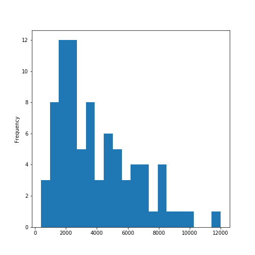

```python
modalities.length.plot(bins=20, kind='hist')
plt.show()
```

```python
modalities.length.describe()
```

```
## count       82.000000
## mean      3974.804878
## std       2518.144552
## min        382.000000
## 25%       2014.250000
## 50%       3320.000000
## 75%       5531.750000
## max      11993.000000
## Name: length, dtype: float64
```

```python
print(list(modalities.Document[modalities.length > 3900].index))
```

```
## [25, 75, 64, 29, 70, 5, 78, 43, 49, 24, 39, 1, 16, 26, 44, 3, 27, 33, 22, 37, 17, 2, 34, 28, 9, 48, 68, 41, 52, 50, 45, 79, 72, 7]
```

```python
print(list(modalities.Topic[modalities.length > 3900]))
```

```
## ['mental health services benefits', 'dry brushing massage', 'Lymphatic Drainage Massage', 'mental health services benefits', 'Lymphatic Drainage Massage', 'massage benefits', 'ER', 'cupping benefits', 'massage gun benefits', 'mental health services benefits', 'cupping benefits', 'chiropractic ben…
```

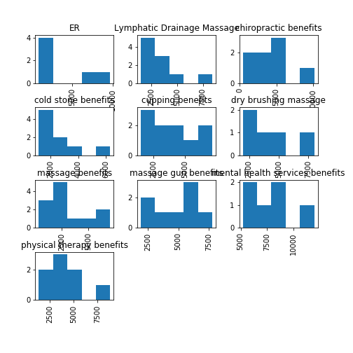

```python
modalities.hist(column='length', by='Topic', bins=5)


plt.show()
```

```python
def split_into_tokens(review):

    return TextBlob(review).words
```

```python
modalities.Document.head().apply(split_into_tokens)
```

```
## 77    [General, guidelines, When, to, visit, an, eme...
## 25    [Five, Warning, Signs, of, Mental, Illness, It...
## 14    [What, Are, the, Health, Benefits, of, Massage...
## 40    [Cupping, therapy, is, a, practice, that, invo...
## 75    [The, Benefits, and, Risks, of, Dry, Brushing,...
## Name: Document, dtype: object
```

```python
TextBlob("hello world, how is it going?").tags  # list of (word, POS) pairs
```

```
## [('hello', 'JJ'), ('world', 'NN'), ('how', 'WRB'), ('is', 'VBZ'), ('it', 'PRP'), ('going', 'VBG')]
```

```python
import nltk
nltk.download('stopwords')
```

```
## True
##
```

```python
from nltk.corpus import stopwords

stop = stopwords.words('english')
stop = stop + [u'a',u'b',u'c',u'd',u'e',u'f',u'g',u'h',u'i',u'j',u'k',u'l',u'm',u'n',u'o',u'p',u'q',u'r',u's',u't',u'v',u'w',u'x',u'y',u'z']
```

```python
def split_into_lemmas(review):
    #review = unicode(review, 'iso-8859-1')
    review = review.lower()
    #review = unicode(review, 'utf8').lower()
    #review = str(review).lower()
    words = TextBlob(review).words
    # for each word, take its "base form" = lemma
    return [word.lemma for word in words if word not in stop]

modalities.Document.head().apply(split_into_lemmas)
```

```
## 77    [general, guideline, visit, emergency, room, c...
## 25    [five, warning, sign, mental, illness, easy, g...
## 14    [health, benefit, massage, many, type, massage...
## 40    [cupping, therapy, practice, involves, briefly...
## 75    [benefit, risk, dry, brushing, dry, brushing, ...
## Name: Document, dtype: object
```

```python
bow_transformerNgrams = CountVectorizer(analyzer=split_into_lemmas,ngram_range=(2,2)).fit(modalities['Document'])

print(len(bow_transformerNgrams.vocabulary_))
```

```
## 4857
```

```python
modality4 = modalities['Document'][40]
print(modality4)
```

```
##
##
## Cupping therapy is a practice that involves briefly applying rounded inverted cups to certain parts of the body using a vacuum effect. Some proponents suggest that the drawing of the skin inside the cups increases blood flow to the area.
##
## Long used in Taditional Chinese Medicine and other ancient healing systems, cupping has gained considerable popularity in recent years among athletes. For instance, swimmer Michael Phelps had the therapy in preparation for the 2016 Summer Olympics.1?
## Uses
##
## Cupping is often recommended as a complementary therapy for the following conditions:2
##
##     Back pain
##     Headache or migraine
##     Knee pain
##     Muscle pain and soreness
##     Neck and shoulder pain
##     Sports injuries and performance
##     Bronchial congestion due to the cold or asthma
##
## In traditional Chinese medicine, cupping is said to stimulate the flow of vital energy (also known as "Qi" or "chi") and blood, and to help correct any imbalances arising from illness or injury. It's sometimes combined with acupuncture and tuina, other therapies said to promote the flow of energy…
## How Does Cupping Therapy Work?
##
## To create the suction inside the cups, the practitioner may them by placing a flammable substance (such as herbs, alcohol, and/or paper) inside each cup and then igniting that substance. Next, the practitioner places the cup upside down on the body. During a typical cupping treatment, between thr…
##
## Today, many practitioners use a manual or electric pump to create the vacuum, or use self-suctioning cupping sets. After the cups are in place, they are usually removed after five to ten minutes. (Practitioners may practice "flash" cupping, by quickly attaching then removing the cup repeatedly.)
##
## Some practitioners apply massage oil or cream and then attach silicone cups, sliding them around the body rhythmically for a massage-like effect.
##
## In a procedure known as "wet cupping," the skin is punctured prior to treatment. This causes blood to flow out of the punctures during the cupping procedure, which is thought to clear toxins from the body.4?
## Benefits
##
## To date, there is a lack of high-quality scientific research to support the use of cupping to treat any health condition. For instance, a 2011 research review sized up seven trials testing cupping in people with pain (such as low back pain); results showed that most of the studies were of poor qu…
##
## In another research review published in 2017, scientists analyzed 11 studies that tested the use of cupping by athletes. The review's authors concluded that no explicit recommendation could be made for or against the use of cupping in athletes and that further studies are needed. Some studies did…
##
## Although cupping is sometimes recommended to increase flexibility in athletes, a small study published in the Journal of Sports Rehabilitation in 2018 found no change in hamstring flexibility after a seven-minute cupping session using four cups. Study participants were NCAA Division III college s…
##
##
##
##
##
##
##
## Bottom Line
##
## After seeing high-profile athletes and celebrities sport the characteristic round purple marks, it may be tempting to try cupping, but there's currently a lack of research on cupping. If you're still thinking of trying it, be sure to consult your doctor before beginning treatment.
```

```python
bow4 = bow_transformerNgrams.transform([modality4])
print(bow4)
```

```
##   (0, 5) 1
##   (0, 7) 3
##   (0, 22)    1
##   (0, 52)    1
##   (0, 56)    1
##   (0, 58)    1
##   (0, 59)    1
##   (0, 188)   1
##   (0, 267)   1
##   (0, 296)   1
##   (0, 304)   1
##   (0, 316)   1
##   (0, 323)   1
##   (0, 325)   1
##   (0, 326)   1
##   (0, 346)   1
##   (0, 375)   1
##   (0, 376)   1
##   (0, 384)   1
##   (0, 390)   1
##   (0, 395)   1
##   (0, 429)   1
##   (0, 432)   5
##   (0, 437)   1
##   (0, 439)   1
##   :  :
##   (0, 4339)  1
##   (0, 4346)  1
##   (0, 4351)  1
##   (0, 4391)  1
##   (0, 4426)  1
##   (0, 4431)  1
##   (0, 4454)  1
##   (0, 4458)  3
##   (0, 4463)  1
##   (0, 4481)  1
##   (0, 4482)  1
##   (0, 4486)  1
##   (0, 4497)  1
##   (0, 4570)  1
##   (0, 4580)  1
##   (0, 4584)  5
##   (0, 4585)  1
##   (0, 4588)  2
##   (0, 4589)  1
##   (0, 4597)  2
##   (0, 4654)  1
##   (0, 4718)  1
##   (0, 4749)  1
##   (0, 4760)  1
##   (0, 4792)  1
```

```python
modalities_bow = bow_transformerNgrams.transform(modalities['Document'])
print('sparse matrix shape:', modalities_bow.shape)
```

```
## sparse matrix shape: (82, 4857)
```

```python
print('number of non-zeros:', modalities_bow.nnz)
```

```
## number of non-zeros: 17756
```

```python
print('sparsity: %.2f%%' % (100.0 * modalities_bow.nnz / (modalities_bow.shape[0] * modalities_bow.shape[1])))
```

```
## sparsity: 4.46%
```

```python
modalities_bow
```

```
## <82x4857 sparse matrix of type '<class 'numpy.int64'>'
##  with 17756 stored elements in Compressed Sparse Row format>
```

```python
# Split/splice into training ~ 80% and testing ~ 20%
modalities_bow_train = modalities_bow[:65]
modalities_bow_test = modalities_bow[65:]
modalities_sentiment_train = modalities['Topic'][:65]
modalities_sentiment_test = modalities['Topic'][65:]

print(modalities_bow_train.shape)
```

```
## (65, 4857)
```

```python
print(modalities_bow_test.shape)
```

```
## (17, 4857)
```

```python
print
```

```
## <built-in function print>
```

```python
modalities_sentiment = MultinomialNB().fit(modalities_bow_train, modalities_sentiment_train)
```

```python
print('predicted:', modalities_sentiment.predict(bow4)[0])
```

```
## predicted: cupping benefits
```

```python
print('expected:', modalities.Topic[40])
```

```
## expected: cupping benefits
```

```python
predictions = modalities_sentiment.predict(modalities_bow_test)
#print(predictions)

prd = pd.DataFrame(predictions)
prd.columns=['predictions']
prd.index=modalities_sentiment_test.index
pred=pd.concat([pd.DataFrame(prd),modalities_sentiment_test],axis=1)
print(pred)
```

```
##                    predictions                       Topic
## 68  Lymphatic Drainage Massage  Lymphatic Drainage Massage
## 41            cupping benefits            cupping benefits
## 52            massage benefits         cold stone benefits
## 65  Lymphatic Drainage Massage  Lymphatic Drainage Massage
## 50        massage gun benefits        massage gun benefits
## 55         cold stone benefits         cold stone benefits
## 45        massage gun benefits        massage gun benefits
## 79                          ER                          ER
## 81                          ER                          ER
## 59         cold stone benefits         cold stone benefits
## 23   physical therapy benefits   physical therapy benefits
## 51        massage gun benefits        massage gun benefits
## 72        dry brushing massage        dry brushing massage
## 8             massage benefits            massage benefits
## 71  Lymphatic Drainage Massage        dry brushing massage
## 6             massage benefits            massage benefits
## 7             massage benefits            massage benefits
```

```python
print('accuracy', accuracy_score(modalities_sentiment_test, predictions))
```

```
## accuracy 0.8823529411764706
```

```python
print('confusion matrix\n', confusion_matrix(modalities_sentiment_test, predictions))
```

```
## confusion matrix
##  [[2 0 0 0 0 0 0 0]
##  [0 2 0 0 0 0 0 0]
##  [0 0 2 0 0 1 0 0]
##  [0 0 0 1 0 0 0 0]
##  [0 1 0 0 1 0 0 0]
##  [0 0 0 0 0 3 0 0]
##  [0 0 0 0 0 0 3 0]
##  [0 0 0 0 0 0 0 1]]
```

```python
print('(row=expected, col=predicted)')
```

```
## (row=expected, col=predicted)
```

```python
print(classification_report(modalities_sentiment_test, predictions))
```

```
##                             precision    recall  f1-score   support
##
##                         ER       1.00      1.00      1.00         2
## Lymphatic Drainage Massage       0.67      1.00      0.80         2
##        cold stone benefits       1.00      0.67      0.80         3
##           cupping benefits       1.00      1.00      1.00         1
##       dry brushing massage       1.00      0.50      0.67         2
##           massage benefits       0.75      1.00      0.86         3
##       massage gun benefits       1.00      1.00      1.00         3
##  physical therapy benefits       1.00      1.00      1.00         1
##
##                   accuracy                           0.88        17
##                  macro avg       0.93      0.90      0.89        17
##               weighted avg       0.92      0.88      0.88        17
```

Aside: If your concern is with improving recall or improving precision, you would need to tune your predictive model to get better prediction or recall and put aside the need for the accuracy to be close to 100%. Because if accuracy is 98% and your recall is 60%, that is not going to help you, if say you needed to find all of the tumor cells and only found 60% of them. Same, for precision, if your accuracy is 98% and your precision is 80% and recall 90%, then if your predicting the next day of a stock price increasing and misclassify it as such when it decreases, your precision needs to be improved. Because you may have classified 90% of those days that increased, but you misclassified some decreasing days by 80%, and could have bought that stock. When in doubt, do as the nerds do and set up 10 analogous examples of real-life outcomes and see if its true, or you could stand in a corner until you fall asleep and dream about what is a type 1 and type 2. Or depending on your access to google just google it. But when classifying, you should definitely make sure you have a clear understanding of the difference and necessity for recall and precision. If this was a movie, there would be an unanswered question as to how to tune for these improvements in precision or recall. Since, the above uses multinomial naive bayes, the probabilities are based on the principle of garbage in and garbage out. You would have to get better data, more relevant features, exclude features, play with the testing and training sets, remove outliers, or normalize the data to include outliers by taking the log, and getting to know the sometimes 100s of features (or appearance of) your algorithm if using a package like nltk on tokenizing words. You will see this later in the list of nltk attributes in the other algorithm and model testing on this dataset.

```python
modalitiesu = modalities.Topic.unique()
mus = np.sort(modalitiesu)
mus
```

```
## array(['ER', 'Lymphatic Drainage Massage', 'chiropractic benefits',
##        'cold stone benefits', 'cupping benefits', 'dry brushing massage',
##        'massage benefits', 'massage gun benefits',
##        'mental health services benefits', 'physical therapy benefits'],
##       dtype=object)
```

```python
def predict_modality(new_review):
    new_sample = bow_transformerNgrams.transform([new_review])
    pr = np.around(modalities_sentiment.predict_proba(new_sample),2)
    print(new_review,'\n\n', pr)
    print('\n\nThe respective order:\n 0-ER\n 1-Lymphatic Drainage Massage\n 2-chiropractic therapy\n 3-cold stone therapy\n 4-cupping therapy\n 5-dry brushing massage\n 6-massage benefits\n 7-massage gun therapy\n 8-mental health services\n 9-physical therapy services\n\n')

    if (pr[0][0] == max(pr[0])):
        print('The max probability is Emergency Room services for this recommendation with ', pr[0][0]*100,'%')
    elif (pr[0][1] == max(pr[0])):
        print('The max probability is Lymphatic Drainage Massage for this recommendation with ', pr[0][1]*100,'%')

    elif (pr[0][2] == max(pr[0])):
        print('The max probability is chiropractic therapy for this recommendation with ', pr[0][2]*100,'%')

    elif (pr[0][3] == max(pr[0])):
        print('The max probability is cold stone massage for this recommendation with ', pr[0][3]*100,'%')

    elif (pr[0][4] == max(pr[0])):
        print('The max probability is cupping therapy for this recommendation with ', pr[0][4]*100,'%')

    elif (pr[0][5] == max(pr[0])):
        print('The max probability is dry brushing massage for this recommendation with ', pr[0][5]*100,'%')

    elif (pr[0][6] == max(pr[0])):
        print('The max probability is massage therapy for this recommendation with ', pr[0][6]*100,'%')

    elif (pr[0][7] == max(pr[0])):
        print('The max probability is massage gun therapy for this recommendation with ', pr[0][7]*100,'%')

    elif (pr[0][8] == max(pr[0])):
        print('The max probability is mental health services for this recommendation with ', pr[0][8]*100,'%')
    else:
        print('The max probability is physical therapy services for this recommendation with ', pr[0][9]*100,'%')
    print('-----------------------------------------\n\n')
```

```python
predict_modality('Headaches, body sweats, depressed.')
```

```
## Headaches, body sweats, depressed.
##
##  [[0.01 0.09 0.32 0.04 0.03 0.03 0.46 0.01 0.01 0.01]]
##
##
## The respective order:
##  0-ER
##  1-Lymphatic Drainage Massage
##  2-chiropractic therapy
##  3-cold stone therapy
##  4-cupping therapy
##  5-dry brushing massage
##  6-massage benefits
##  7-massage gun therapy
##  8-mental health services
##  9-physical therapy services
##
##
## The max probability is massage therapy for this recommendation with  46.0 %
## -----------------------------------------
```

```python
predict_modality('sleepless, energy depraved, cold, tension')
```

```
## sleepless, energy depraved, cold, tension
##
##  [[0.   0.   0.02 0.84 0.11 0.01 0.01 0.01 0.   0.  ]]
##
##
## The respective order:
##  0-ER
##  1-Lymphatic Drainage Massage
##  2-chiropractic therapy
##  3-cold stone therapy
##  4-cupping therapy
##  5-dry brushing massage
##  6-massage benefits
##  7-massage gun therapy
##  8-mental health services
##  9-physical therapy services
##
##
## The max probability is cold stone massage for this recommendation with  84.0 %
## -----------------------------------------
```

```python
predict_modality('body aches from working out')
```

```
## body aches from working out
##
##  [[0.   0.08 0.06 0.07 0.09 0.02 0.22 0.26 0.06 0.14]]
##
##
## The respective order:
##  0-ER
##  1-Lymphatic Drainage Massage
##  2-chiropractic therapy
##  3-cold stone therapy
##  4-cupping therapy
##  5-dry brushing massage
##  6-massage benefits
##  7-massage gun therapy
##  8-mental health services
##  9-physical therapy services
##
##
## The max probability is massage gun therapy for this recommendation with  26.0 %
## -----------------------------------------
```

```python
predict_modality('can\'t move my arm. stuck at home. worried about my neck.')
```

```
## can't move my arm. stuck at home. worried about my neck.
##
##  [[0.06 0.4  0.12 0.01 0.02 0.04 0.19 0.02 0.01 0.13]]
##
##
## The respective order:
##  0-ER
##  1-Lymphatic Drainage Massage
##  2-chiropractic therapy
##  3-cold stone therapy
##  4-cupping therapy
##  5-dry brushing massage
##  6-massage benefits
##  7-massage gun therapy
##  8-mental health services
##  9-physical therapy services
##
##
## The max probability is Lymphatic Drainage Massage for this recommendation with  40.0 %
## -----------------------------------------
```

```python
predict_modality('breathing ragged, tired, headaches, dizzy, nausious ')
```

```
## breathing ragged, tired, headaches, dizzy, nausious
##
##  [[0.19 0.04 0.37 0.02 0.04 0.01 0.32 0.   0.01 0.01]]
##
##
## The respective order:
##  0-ER
##  1-Lymphatic Drainage Massage
##  2-chiropractic therapy
##  3-cold stone therapy
##  4-cupping therapy
##  5-dry brushing massage
##  6-massage benefits
##  7-massage gun therapy
##  8-mental health services
##  9-physical therapy services
##
##
## The max probability is chiropractic therapy for this recommendation with  37.0 %
## -----------------------------------------
```

```python
predict_modality("relief from this pain. can't sleep. feet hurt. chills.")
```

```
## relief from this pain. can't sleep. feet hurt. chills.
##
##  [[0.   0.03 0.5  0.   0.02 0.   0.32 0.02 0.   0.11]]
##
##
## The respective order:
##  0-ER
##  1-Lymphatic Drainage Massage
##  2-chiropractic therapy
##  3-cold stone therapy
##  4-cupping therapy
##  5-dry brushing massage
##  6-massage benefits
##  7-massage gun therapy
##  8-mental health services
##  9-physical therapy services
##
##
## The max probability is chiropractic therapy for this recommendation with  50.0 %
## -----------------------------------------
```

```python
predict_modality('love this place better than others')
```

```
## love this place better than others
##
##  [[0.01 0.02 0.1  0.02 0.3  0.01 0.02 0.04 0.47 0.01]]
##
##
## The respective order:
##  0-ER
##  1-Lymphatic Drainage Massage
##  2-chiropractic therapy
##  3-cold stone therapy
##  4-cupping therapy
##  5-dry brushing massage
##  6-massage benefits
##  7-massage gun therapy
##  8-mental health services
##  9-physical therapy services
##
##
## The max probability is mental health services for this recommendation with  47.0 %
## -----------------------------------------
```

```r
library(reticulate)
```

```r
conda_list(conda = "auto")
```

```
##           name                                                  python
## 1    Anaconda2                     C:\\Users\\m\\Anaconda2\\python.exe
## 2    djangoenv    C:\\Users\\m\\Anaconda2\\envs\\djangoenv\\python.exe
## 3     python36     C:\\Users\\m\\Anaconda2\\envs\\python36\\python.exe
## 4     python37     C:\\Users\\m\\Anaconda2\\envs\\python37\\python.exe
## 5 r-reticulate C:\\Users\\m\\Anaconda2\\envs\\r-reticulate\\python.exe
```

Without having my python IDE, Anaconda, open in the console I want to use the python36 environment, all the environments in Anaconda for python are listed above.

```r
use_condaenv(condaenv = "python36")
```

```python
import pandas as pd
import matplotlib.pyplot as plt
from textblob import TextBlob
import sklearn
import numpy as np
from sklearn.feature_extraction.text import CountVectorizer, TfidfVectorizer
from sklearn.naive_bayes import MultinomialNB
from sklearn.metrics import classification_report, f1_score, accuracy_score, confusion_matrix

import re
import string
import nltk

np.random.seed(45678)
```

The first part of the following code uses the Random Forest Classifier (RFC) and the Gradient Boosting Classifier (GBC) to categorize the recommendation based on three separate types of document term matrix (dtm) tokenizations, Count Vectorizer, Term Frequency-Inverse Document Frequency (TF-IDF) Vectorizer, and N-grams Vectorizer. This first part also uses Lemmatization to get the more ideal word meaning root word. And the training model uses 80% of the samples and 20% to test the model on within each type of vectorized and lemmatized token.

The second part of the following will keep all the same but change the training set to 85% and the testing set to 15% while still using lemmatization.

The third part will keep the first part the same but only change the lemmatization to stemmed word roots.

The fourt part will keep the same third part settings but change the testing set to 15% and the training set to 85%.

Those four sections of variations will allow us to contrast and compare which setting worked best for recall, precision, and accuracy within each vectorized and stemmed/lemmatized tokens of the dtms for either RFC or GBC.

## First part: Lemmatized Tokens & 80/20 Train/Test split & RFC | GBC

**Count Vectorizer** RFC and GBC

```python
stopwords = nltk.corpus.stopwords.words('english')
ps=nltk.PorterStemmer()
wn=nltk.WordNetLemmatizer()
data=pd.read_csv("benefitsContraindications4.csv", encoding='unicode_escape')
data.columns=['Document','Source','Topic','InternetSearch','Contraindications','RisksSideEffects']
```

```r
data <- read.csv('benefitsContraindications4.csv',sep=',',header=TRUE,  na.strings=c('',' ','NA'))
colnames(data)
```

```
## [1] "Document"            "Source"              "Topic"
## [4] "InternetSearch"      "Contraindications"   "risksAdverseEffects"
```

```r
head(data,5)
```

```
##                                                                                                                                                                                                                                                                                                          …
## 1                                                                                                                                                                                                                                                                                                        …
## 2                                                                                                                                                                                                                                                                                                        …
## 3                                                                                                                                                                                                                                                                                                        …
## 4 Advanced Chiropractic Relief: 8 Key Benefits of Chiropractor Care\n\nAre you one of the 50 million Americans who suffer from chronic pain? If so you?re probably intimately familiar with the feeling of pure desperation that can arise from an inability to find relief.\n\nIn addition to physical i…
## 5                                                                                                                                                                                                                                                                                                        …
##                                                                                                                                       Source
## 1 https://coremedicalohio.com/benefits-of-long-term-chiropractic-care/?utm_source=ReviveOldPost&utm_medium=social&utm_campaign=ReviveOldPost
## 2                                   https://healthpayerintelligence.com/news/unitedhealthcare-combats-opioid-crisis-with-non-opioid-benefits
## 3                                                                     https://www.verywellhealth.com/is-chiropractic-adjustment-safe-4588279
## 4                                           https://hafkeychiropractic.com/advanced-chiropractic-relief-8-key-benefits-of-chiropractor-care/
## 5                                                                                  https://www.urbannirvana.com/10-benefits-massage-therapy/
##                   Topic InternetSearch
## 1 chiropractic benefits           <NA>
## 2 chiropractic benefits           <NA>
## 3 chiropractic benefits           <NA>
## 4 chiropractic benefits           <NA>
## 5      massage benefits         google
##                                                                                                                                                                                               Contraindications
## 1 Doctors of Chiropractic work collaboratively with other healthcare professionals. Should your condition require the attention of another healthcare profession, that recommendation or referral will be made.
## 2                                                                                                                                                                                                          <NA>
## 3                                                                                                                                                                                                          <NA>
## 4                                                                                                                                                                                                          <NA>
## 5                                                                                                                                                                                                          <NA>
##                                                                                                                                                                                                                                                                                                          …
## 1                                                                                                                                                                                                                                                                                                        …
## 2                                                                                                                                                                                                                                                                                                        …
## 3 Risks and side effects associated with chiropractic adjustments may include:\n\n    temporary headaches\n    fatigue after treatment\n    discomfort in parts of the body that were treated\n\nRare but serious risks associated with chiropractic adjustment include:\n\n    stroke\n    cauda equina …
## 4                                                                                                                                                                                                                                                                                                        …
## 5                                                                                                                                                                                                                                                                                                        …
```

```python
def count_punct(text):
    count=sum([1 for char in text if char in string.punctuation])
    return round(count/(len(text)-text.count(" ")),3)*100
```

```python
data['body_length']=data['Document'].apply(lambda x: len(x)-x.count(" "))
data['punct%']= data['Document'].apply(lambda x: count_punct(x))
```

```python
def clean_text(text):
    text="".join([word.lower() for word in text if word not in string.punctuation])
    tokens=re.split('\W+', text)
    text=[ps.stem(word) for word in tokens if word not in stopwords]#these are lists for the count vectorizer
    return text

def lemmatize(text):
    text="".join([word.lower() for word in text if word not in string.punctuation])
    tokens=re.split('\W+', text)
    text=[wn.lemmatize(word) for word in tokens if word not in stopwords]#these are lists for the count vectorizer
    return text
```

```python
data['Cleaned_text']=data['Document'].apply(lambda x: clean_text(x))
data['Lemmatized']=data['Document'].apply(lambda x: lemmatize(x))
data.head()
```

```
##                                             Document  ...                                         Lemmatized
## 0  Chiropractic adjustments and treatments serve ...  ...  [chiropractic, adjustment, treatment, serve, n...
## 1  \nUnitedHealthcare Combats Opioid Crisis with ...  ...  [, unitedhealthcare, combat, opioid, crisis, n...
## 2   The Safety of Chiropractic Adjustments\n\n   ...  ...  [, safety, chiropractic, adjustment, chiroprac...
## 3  Advanced Chiropractic Relief: 8 Key Benefits o...  ...  [advanced, chiropractic, relief, 8, key, benef...
## 4  Heading to the spa can be a pampering treat, b...  ...  [heading, spa, pampering, treat, also, huge, b...
##
## [5 rows x 10 columns]
```

```python
data.to_csv('dataCleanLemm.csv')
#DATA = pd.read_csv('dataCleanLemm.csv', encoding='unicode_escape')
```

```r
DATA <- read.csv('dataCleanLemm.csv', sep=',', header=TRUE, na.strings=c('',' ','NA'), row.names=1)
colnames(DATA)
```

```
##  [1] "Document"          "Source"            "Topic"
##  [4] "InternetSearch"    "Contraindications" "RisksSideEffects"
##  [7] "body_length"       "punct."            "Cleaned_text"
## [10] "Lemmatized"
```

```r
head(DATA,2)
```

```
##                                                                                                                                                                                                                                                                                                          …
## 0                                                                                                                                                                                                                                                                                                        …
## 1 \nUnitedHealthcare Combats Opioid Crisis with Non-Opioid Benefits\nPhysical therapy and chiropractic care can prevent or reduce expensive, invasive spinal procedures, such as imaging or surgery, to reduce opioid use and cut costs.\nUnitedHealthcare, opioid, physical therapy, healthcare spending…
##                                                                                                                                       Source
## 0 https://coremedicalohio.com/benefits-of-long-term-chiropractic-care/?utm_source=ReviveOldPost&utm_medium=social&utm_campaign=ReviveOldPost
## 1                                   https://healthpayerintelligence.com/news/unitedhealthcare-combats-opioid-crisis-with-non-opioid-benefits
##                   Topic InternetSearch
## 0 chiropractic benefits           <NA>
## 1 chiropractic benefits           <NA>
##                                                                                                                                                                                               Contraindications
## 0 Doctors of Chiropractic work collaboratively with other healthcare professionals. Should your condition require the attention of another healthcare profession, that recommendation or referral will be made.
## 1                                                                                                                                                                                                          <NA>
##   RisksSideEffects body_length punct.
## 0             <NA>        2288    2.4
## 1             <NA>        3796    2.4
##                                                                                                                                                                                                                                                                                                          …
## 0                                                                                                                                                                                                                                                                                                        …
## 1 ['', 'unitedhealthcar', 'combat', 'opioid', 'crisi', 'nonopioid', 'benefit', 'physic', 'therapi', 'chiropract', 'care', 'prevent', 'reduc', 'expens', 'invas', 'spinal', 'procedur', 'imag', 'surgeri', 'reduc', 'opioid', 'use', 'cut', 'cost', 'unitedhealthcar', 'opioid', 'physic', 'therapi', 'hea…
##                                                                                                                                                                                                                                                                                                          …
## 0                                                                                                                                                                                                                                                                                                        …
## 1 ['', 'unitedhealthcare', 'combat', 'opioid', 'crisis', 'nonopioid', 'benefit', 'physical', 'therapy', 'chiropractic', 'care', 'prevent', 'reduce', 'expensive', 'invasive', 'spinal', 'procedure', 'imaging', 'surgery', 'reduce', 'opioid', 'use', 'cut', 'cost', 'unitedhealthcare', 'opioid', 'physi…
```

```python
from sklearn.model_selection import train_test_split

X_train,X_test,y_train,y_test=train_test_split(data[['Document','body_length','punct%','Cleaned_text','Lemmatized']],data['Topic'],test_size=0.20)
```

```python
from sklearn.feature_extraction.text import CountVectorizer
```

```python
count_vect=CountVectorizer(analyzer=lemmatize)
count_vect_fit=count_vect.fit(X_train['Document'])

count_train=count_vect_fit.transform(X_train['Document'])
count_test=count_vect_fit.transform(X_test['Document'])
```

```python
len(count_vect_fit.get_feature_names())
```

```
## 4114
```

```python
count_vect_fit.get_feature_names()[200:350]
```

```
## ['affiliate', 'affirm', 'affordable', 'afraid', 'afterhours', 'afterward', 'afterwards', 'age', 'agency', 'agephysical', 'agerelated', 'aggression', 'aggressive', 'aggressively', 'aging', 'ago', 'agree', 'ahead', 'aid', 'aiding', 'ailment', 'aim', 'air', 'airport', 'alan', 'alchemist', 'alcohol',…
```

```python
count_train_vect=pd.concat([X_train[['Document','body_length','punct%','Cleaned_text','Lemmatized']].reset_index(drop=True),pd.DataFrame(count_train.toarray())],axis=1)

count_test_vect=pd.concat([X_test[['Document','body_length','punct%','Cleaned_text','Lemmatized']].reset_index(drop=True),pd.DataFrame(count_test.toarray())],axis=1)
```

```python
count_train_vect.head()
```

```
##                                             Document  body_length  ...  4112 4113
## 0  Cold Stone Therapy for Migraine Headaches\n\nP...         5275  ...     0    0
## 1  About Lymphatic Massage (MLD Manual Lymphatic ...         1695  ...     0    0
## 2  \nFinding Help: When to Get It and Where to Go...         6862  ...     0    0
## 3  \nFive Warning Signs of Mental Illness\n\n\nIt...         6759  ...     0    0
## 4  What is Hot & Cold Stone Therapy?\n\nHot & Col...         2781  ...     0    0
##
## [5 rows x 4119 columns]
```

```python
from sklearn.ensemble import RandomForestClassifier, GradientBoostingClassifier
from sklearn.metrics import precision_recall_fscore_support as score
import time
```

```python
rf=RandomForestClassifier(n_estimators=150, max_depth=None, n_jobs=-1)
start=time.time()
rf_model=rf.fit(count_train,y_train)
end=time.time()
fit_time=(end-start)
```

```python
start=time.time()
y_pred=rf_model.predict(count_test)
end=time.time()
pred_time=(end-start)
```

```python
prd = pd.DataFrame(y_pred)
prd.columns=['Predicted']

prd.index=y_test.index
pred=pd.concat([pd.DataFrame(prd),y_test],axis=1)
print(pred)
```

```
##                           Predicted                            Topic
## 14                 massage benefits                 massage benefits
## 29  mental health services benefits  mental health services benefits
## 36                 massage benefits                 cupping benefits
## 19                 massage benefits        physical therapy benefits
## 26        physical therapy benefits  mental health services benefits
## 66       Lymphatic Drainage Massage       Lymphatic Drainage Massage
## 9              massage gun benefits                 massage benefits
## 56              cold stone benefits              cold stone benefits
## 70       Lymphatic Drainage Massage       Lymphatic Drainage Massage
## 69       Lymphatic Drainage Massage       Lymphatic Drainage Massage
## 68       Lymphatic Drainage Massage       Lymphatic Drainage Massage
## 24                 massage benefits  mental health services benefits
## 72             dry brushing massage             dry brushing massage
## 80                               ER                               ER
## 10                 massage benefits                 massage benefits
## 12                 massage benefits                 massage benefits
## 53              cold stone benefits              cold stone benefits
```

```python
from sklearn.metrics import classification_report, f1_score, accuracy_score, confusion_matrix

print('accuracy', accuracy_score(y_test, y_pred))
```

```
## accuracy 0.7058823529411765
```

```python
print('confusion matrix\n', confusion_matrix(y_test, y_pred))
```

```
## confusion matrix
##  [[1 0 0 0 0 0 0 0 0]
##  [0 4 0 0 0 0 0 0 0]
##  [0 0 2 0 0 0 0 0 0]
##  [0 0 0 0 0 1 0 0 0]
##  [0 0 0 0 1 0 0 0 0]
##  [0 0 0 0 0 3 1 0 0]
##  [0 0 0 0 0 0 0 0 0]
##  [0 0 0 0 0 1 0 1 1]
##  [0 0 0 0 0 1 0 0 0]]
```

```python
print('(row=expected, col=predicted)')
```

```
## (row=expected, col=predicted)
```

```python
print(classification_report(y_test, y_pred))
```

```
##                                  precision    recall  f1-score   support
##
##                              ER       1.00      1.00      1.00         1
##      Lymphatic Drainage Massage       1.00      1.00      1.00         4
##             cold stone benefits       1.00      1.00      1.00         2
##                cupping benefits       0.00      0.00      0.00         1
##            dry brushing massage       1.00      1.00      1.00         1
##                massage benefits       0.50      0.75      0.60         4
##            massage gun benefits       0.00      0.00      0.00         0
## mental health services benefits       1.00      0.33      0.50         3
##       physical therapy benefits       0.00      0.00      0.00         1
##
##                        accuracy                           0.71        17
##                       macro avg       0.61      0.56      0.57        17
##                    weighted avg       0.76      0.71      0.70        17
##
##
```

```python
gb=GradientBoostingClassifier(n_estimators=150,max_depth=11)
start=time.time()
gb_model=gb.fit(count_train,y_train)
end=time.time()
fit_time=(end-start)
```

```python
start=time.time()
y_pred=gb_model.predict(count_test)
end=time.time()
pred_time=(end-start)
```

```python
prd = pd.DataFrame(y_pred)
prd.columns=['Predicted']

prd.index=y_test.index
pred=pd.concat([pd.DataFrame(prd),y_test],axis=1)
print(pred)
```

```
##                           Predicted                            Topic
## 14                 cupping benefits                 massage benefits
## 29  mental health services benefits  mental health services benefits
## 36                 cupping benefits                 cupping benefits
## 19                 cupping benefits        physical therapy benefits
## 26  mental health services benefits  mental health services benefits
## 66       Lymphatic Drainage Massage       Lymphatic Drainage Massage
## 9                  cupping benefits                 massage benefits
## 56              cold stone benefits              cold stone benefits
## 70       Lymphatic Drainage Massage       Lymphatic Drainage Massage
## 69       Lymphatic Drainage Massage       Lymphatic Drainage Massage
## 68       Lymphatic Drainage Massage       Lymphatic Drainage Massage
## 24  mental health services benefits  mental health services benefits
## 72                 massage benefits             dry brushing massage
## 80                               ER                               ER
## 10                 massage benefits                 massage benefits
## 12                 cupping benefits                 massage benefits
## 53              cold stone benefits              cold stone benefits
```

```python
from sklearn.metrics import classification_report, f1_score, accuracy_score, confusion_matrix

print('accuracy', accuracy_score(y_test, y_pred))
```

```
## accuracy 0.7058823529411765
```

```python
print('confusion matrix\n', confusion_matrix(y_test, y_pred))
```

```
## confusion matrix
##  [[1 0 0 0 0 0 0 0]
##  [0 4 0 0 0 0 0 0]
##  [0 0 2 0 0 0 0 0]
##  [0 0 0 1 0 0 0 0]
##  [0 0 0 0 0 1 0 0]
##  [0 0 0 3 0 1 0 0]
##  [0 0 0 0 0 0 3 0]
##  [0 0 0 1 0 0 0 0]]
```

```python
print('(row=expected, col=predicted)')
```

```
## (row=expected, col=predicted)
```

```python
print(classification_report(y_test, y_pred))
```

```
##                                  precision    recall  f1-score   support
##
##                              ER       1.00      1.00      1.00         1
##      Lymphatic Drainage Massage       1.00      1.00      1.00         4
##             cold stone benefits       1.00      1.00      1.00         2
##                cupping benefits       0.20      1.00      0.33         1
##            dry brushing massage       0.00      0.00      0.00         1
##                massage benefits       0.50      0.25      0.33         4
## mental health services benefits       1.00      1.00      1.00         3
##       physical therapy benefits       0.00      0.00      0.00         1
##
##                        accuracy                           0.71        17
##                       macro avg       0.59      0.66      0.58        17
##                    weighted avg       0.72      0.71      0.69        17
##
##
```

```python
def clean_text(text):
    text="".join([word.lower() for word in text if word not in string.punctuation])
    tokens=re.split('\W+', text)
    text=[ps.stem(word) for word in tokens if word not in stopwords]
    return text

def lemmatize(text):
    text="".join([word.lower() for word in text if word not in string.punctuation])
    tokens=re.split('\W+', text)
    text=[wn.lemmatize(word) for word in tokens if word not in stopwords]
    return text

def predict_countRFC_lemmatized(new_review):
    nr=pd.DataFrame([new_review])
    nr.columns=['newReview']
    nr['lemmatized']=nr['newReview'].apply(lambda x: lemmatize(x))

    rf=RandomForestClassifier(n_estimators=150, max_depth=None, n_jobs=-1)
    count_vect=CountVectorizer(analyzer=lemmatize)

    count_vect_fit=count_vect.fit(X_train['Document'])
    count_train=count_vect_fit.transform(X_train['Document'])
    count_test=count_vect_fit.transform(nr['lemmatized'])

    model = rf.fit(count_train,y_train)
    pred=pd.DataFrame(model.predict(count_test))
    pred.columns=['Recommended Healthcare Service']
    pred.index= ['lemmatized_count_RFC_80-20:']
    print('\n\n',pred)


def predict_countRFC_cleaned(new_review):
    nr=pd.DataFrame([new_review])
    nr.columns=['newReview']
    nr['clean']=nr['newReview'].apply(lambda x: clean_text(x))

    rf=RandomForestClassifier(n_estimators=150, max_depth=None, n_jobs=-1)
    count_vect=CountVectorizer(analyzer=clean_text)

    count_vect_fit=count_vect.fit(X_train['Document'])
    count_train=count_vect_fit.transform(X_train['Document'])
    count_test=count_vect_fit.transform(nr['clean'])

    model = rf.fit(count_train,y_train)
    pred=pd.DataFrame(model.predict(count_test))
    pred.columns=['Recommended Healthcare Service']
    pred.index= ['cleaned_count_RFC_80-20:']
    print('\n\n',pred)
```

```python
predict_countRFC_cleaned('I need a massage!')
```

```
##
##
##                           Recommended Healthcare Service
## cleaned_count_RFC_80-20:               massage benefits
```

```python
predict_countRFC_lemmatized('I need a massage!')
```

```
##
##
##                              Recommended Healthcare Service
## lemmatized_count_RFC_80-20:               massage benefits
```

```python
def clean_text(text):
    text="".join([word.lower() for word in text if word not in string.punctuation])
    tokens=re.split('\W+', text)
    text=[ps.stem(word) for word in tokens if word not in stopwords]
    return text

def lemmatize(text):
    text="".join([word.lower() for word in text if word not in string.punctuation])
    tokens=re.split('\W+', text)
    text=[wn.lemmatize(word) for word in tokens if word not in stopwords]
    return text

def predict_countGBC_lemmatized(new_review):
    nr=pd.DataFrame([new_review])
    nr.columns=['newReview']
    nr['lemmatized']=nr['newReview'].apply(lambda x: lemmatize(x))

    gb=GradientBoostingClassifier(n_estimators=150,max_depth=11)
    count_vect=CountVectorizer(analyzer=lemmatize)

    count_vect_fit=count_vect.fit(X_train['Document'])
    count_train=count_vect_fit.transform(X_train['Document'])
    count_test=count_vect_fit.transform(nr['lemmatized'])

    model = gb.fit(count_train,y_train)
    pred=pd.DataFrame(model.predict(count_test))
    pred.columns=['Recommended Healthcare Service']
    pred.index= ['lemmatized_count_GBC_80-20:']
    print('\n\n',pred)


def predict_countGBC_cleaned(new_review):
    nr=pd.DataFrame([new_review])
    nr.columns=['newReview']
    nr['clean']=nr['newReview'].apply(lambda x: clean_text(x))

    gb=GradientBoostingClassifier(n_estimators=150,max_depth=11)
    count_vect=CountVectorizer(analyzer=clean_text)

    count_vect_fit=count_vect.fit(X_train['Document'])
    count_train=count_vect_fit.transform(X_train['Document'])
    count_test=count_vect_fit.transform(nr['clean'])

    model = gb.fit(count_train,y_train)
    pred=pd.DataFrame(model.predict(count_test))
    pred.columns=['Recommended Healthcare Service']
    pred.index= ['cleaned_count_GBC_80-20:']
    print('\n\n',pred)
```

```python
predict_countGBC_cleaned('I need a massage!')
```

```
##
##
##                           Recommended Healthcare Service
## cleaned_count_GBC_80-20:               cupping benefits
```

```python
predict_countGBC_lemmatized('I need a massage!')
```

```
##
##
##                              Recommended Healthcare Service
## lemmatized_count_GBC_80-20:               cupping benefits
```

**TF-IDF** RFC and GBC

```python
stopwords = nltk.corpus.stopwords.words('english')
ps=nltk.PorterStemmer()
wn=nltk.WordNetLemmatizer()
data=pd.read_csv("benefitsContraindications4.csv", encoding='unicode_escape')
data.columns=['Document','Source','Topic','InternetSearch','Contraindications','RisksSideEffects']
```

```python
def count_punct(text):
    count=sum([1 for char in text if char in string.punctuation])
    return round(count/(len(text)-text.count(" ")),3)*100
```

```python
data['body_length']=data['Document'].apply(lambda x: len(x)-x.count(" "))
data['punct%']= data['Document'].apply(lambda x: count_punct(x))
```

```python
def clean_text(text):
    text="".join([word.lower() for word in text if word not in string.punctuation])
    tokens=re.split('\W+', text)
    text=[ps.stem(word) for word in tokens if word not in stopwords]#these are lists for the count vectorizer
    return text

def lemmatize(text):
    text="".join([word.lower() for word in text if word not in string.punctuation])
    tokens=re.split('\W+', text)
    text=[wn.lemmatize(word) for word in tokens if word not in stopwords]#these are lists for the count vectorizer
    return text
```

```python
data['Cleaned_text']=data['Document'].apply(lambda x: clean_text(x))
data['Lemmatized']=data['Document'].apply(lambda x: lemmatize(x))
data.head()
```

```
##                                             Document  ...                                         Lemmatized
## 0  Chiropractic adjustments and treatments serve ...  ...  [chiropractic, adjustment, treatment, serve, n...
## 1  \nUnitedHealthcare Combats Opioid Crisis with ...  ...  [, unitedhealthcare, combat, opioid, crisis, n...
## 2   The Safety of Chiropractic Adjustments\n\n   ...  ...  [, safety, chiropractic, adjustment, chiroprac...
## 3  Advanced Chiropractic Relief: 8 Key Benefits o...  ...  [advanced, chiropractic, relief, 8, key, benef...
## 4  Heading to the spa can be a pampering treat, b...  ...  [heading, spa, pampering, treat, also, huge, b...
##
## [5 rows x 10 columns]
```

```python
from sklearn.model_selection import train_test_split

X_train,X_test,y_train,y_test=train_test_split(data[['Document','body_length','punct%','Cleaned_text','Lemmatized']],data['Topic'],test_size=0.20)
```

```python
from sklearn.feature_extraction.text import TfidfVectorizer
```

```python
tfidf_vect=TfidfVectorizer(analyzer=lemmatize)
tfidf_vect_fit=tfidf_vect.fit(X_train['Document'])

tfidf_train=tfidf_vect_fit.transform(X_train['Document'])
tfidf_test=tfidf_vect_fit.transform(X_test['Document'])
```

```python
len(tfidf_vect_fit.get_feature_names())
```

```
## 4325
```

```python
tfidf_vect_fit.get_feature_names()[200:350]
```

```
## ['advantageous', 'adverse', 'adversity', 'advertised', 'advice', 'advise', 'advocate', 'aerobic', 'affair', 'affect', 'affected', 'affecting', 'affiliate', 'affirm', 'afford', 'affordable', 'afternoon', 'afterward', 'afterwards', 'age', 'agency', 'agephysical', 'agerelated', 'aggression', 'aggres…
```

```python
tfidf_train_vect=pd.concat([X_train[['Document','body_length','punct%','Cleaned_text','Lemmatized']].reset_index(drop=True),pd.DataFrame(tfidf_train.toarray())],axis=1)

tfidf_test_vect=pd.concat([X_test[['Document','body_length','punct%','Cleaned_text','Lemmatized']].reset_index(drop=True),pd.DataFrame(tfidf_test.toarray())],axis=1)
```

```python
tfidf_train_vect.head()
```

```
##                                             Document  body_length  ...  4323 4324
## 0  \nUnitedHealthcare Combats Opioid Crisis with ...         3796  ...   0.0  0.0
## 1  \r\nThai Massage\r\n\r\nDuring a Thai massage,...         1567  ...   0.0  0.0
## 2  ll You Need To Know About Massage Gun\n\nThere...         4366  ...   0.0  0.0
## 3  \nChiropractic Care for Back Pain\n\n\nStudies...          364  ...   0.0  0.0
## 4  \nFinding Help: When to Get It and Where to Go...         6862  ...   0.0  0.0
##
## [5 rows x 4330 columns]
```

```python
from sklearn.ensemble import RandomForestClassifier, GradientBoostingClassifier
from sklearn.metrics import precision_recall_fscore_support as score
import time
np.random.seed(45678)
```

```python
rf=RandomForestClassifier(n_estimators=150, max_depth=None, n_jobs=-1)
start=time.time()
rf_model=rf.fit(tfidf_train,y_train)
end=time.time()
fit_time=(end-start)
```

```python
start=time.time()
y_pred=rf_model.predict(tfidf_test)
end=time.time()
pred_time=(end-start)
```

```python
prd = pd.DataFrame(y_pred)
prd.columns=['Predicted']

prd.index=y_test.index
pred=pd.concat([pd.DataFrame(prd),y_test],axis=1)
print(pred)
```

```
##                      Predicted                       Topic
## 60         cold stone benefits         cold stone benefits
## 30       chiropractic benefits       chiropractic benefits
## 47            massage benefits        massage gun benefits
## 34            cupping benefits            cupping benefits
## 77                          ER                          ER
## 74            massage benefits        dry brushing massage
## 48            massage benefits        massage gun benefits
## 72  Lymphatic Drainage Massage        dry brushing massage
## 81                          ER                          ER
## 53         cold stone benefits         cold stone benefits
## 66  Lymphatic Drainage Massage  Lymphatic Drainage Massage
## 5             massage benefits            massage benefits
## 56         cold stone benefits         cold stone benefits
## 61  Lymphatic Drainage Massage  Lymphatic Drainage Massage
## 19            massage benefits   physical therapy benefits
## 73            massage benefits        dry brushing massage
## 78                          ER                          ER
```

```python
from sklearn.metrics import classification_report, f1_score, accuracy_score, confusion_matrix

print('accuracy', accuracy_score(y_test, y_pred))
```

```
## accuracy 0.6470588235294118
```

```python
print('confusion matrix\n', confusion_matrix(y_test, y_pred))
```

```
## confusion matrix
##  [[3 0 0 0 0 0 0 0 0]
##  [0 2 0 0 0 0 0 0 0]
##  [0 0 1 0 0 0 0 0 0]
##  [0 0 0 3 0 0 0 0 0]
##  [0 0 0 0 1 0 0 0 0]
##  [0 1 0 0 0 0 2 0 0]
##  [0 0 0 0 0 0 1 0 0]
##  [0 0 0 0 0 0 2 0 0]
##  [0 0 0 0 0 0 1 0 0]]
```

```python
print('(row=expected, col=predicted)')
```

```
## (row=expected, col=predicted)
```

```python
print(classification_report(y_test, y_pred))
```

```
##                             precision    recall  f1-score   support
##
##                         ER       1.00      1.00      1.00         3
## Lymphatic Drainage Massage       0.67      1.00      0.80         2
##      chiropractic benefits       1.00      1.00      1.00         1
##        cold stone benefits       1.00      1.00      1.00         3
##           cupping benefits       1.00      1.00      1.00         1
##       dry brushing massage       0.00      0.00      0.00         3
##           massage benefits       0.17      1.00      0.29         1
##       massage gun benefits       0.00      0.00      0.00         2
##  physical therapy benefits       0.00      0.00      0.00         1
##
##                   accuracy                           0.65        17
##                  macro avg       0.54      0.67      0.57        17
##               weighted avg       0.56      0.65      0.58        17
##
##
```

```python
gb=GradientBoostingClassifier(n_estimators=150,max_depth=11)
start=time.time()
gb_model=gb.fit(tfidf_train,y_train)
end=time.time()
fit_time=(end-start)
```

```python
start=time.time()
y_pred=gb_model.predict(tfidf_test)
end=time.time()
pred_time=(end-start)
```

```python
prd = pd.DataFrame(y_pred)
prd.columns=['Predicted']

prd.index=y_test.index
pred=pd.concat([pd.DataFrame(prd),y_test],axis=1)
print(pred)
```

```
##                      Predicted                       Topic
## 60         cold stone benefits         cold stone benefits
## 30       chiropractic benefits       chiropractic benefits
## 47        massage gun benefits        massage gun benefits
## 34            cupping benefits            cupping benefits
## 77                          ER                          ER
## 74        dry brushing massage        dry brushing massage
## 48        massage gun benefits        massage gun benefits
## 72        dry brushing massage        dry brushing massage
## 81                          ER                          ER
## 53         cold stone benefits         cold stone benefits
## 66  Lymphatic Drainage Massage  Lymphatic Drainage Massage
## 5             massage benefits            massage benefits
## 56         cold stone benefits         cold stone benefits
## 61  Lymphatic Drainage Massage  Lymphatic Drainage Massage
## 19            massage benefits   physical therapy benefits
## 73        dry brushing massage        dry brushing massage
## 78                          ER                          ER
```

```python
from sklearn.metrics import classification_report, f1_score, accuracy_score, confusion_matrix

print('accuracy', accuracy_score(y_test, y_pred))
```

```
## accuracy 0.9411764705882353
```

```python
print('confusion matrix\n', confusion_matrix(y_test, y_pred))
```

```
## confusion matrix
##  [[3 0 0 0 0 0 0 0 0]
##  [0 2 0 0 0 0 0 0 0]
##  [0 0 1 0 0 0 0 0 0]
##  [0 0 0 3 0 0 0 0 0]
##  [0 0 0 0 1 0 0 0 0]
##  [0 0 0 0 0 3 0 0 0]
##  [0 0 0 0 0 0 1 0 0]
##  [0 0 0 0 0 0 0 2 0]
##  [0 0 0 0 0 0 1 0 0]]
```

```python
print('(row=expected, col=predicted)')
```

```
## (row=expected, col=predicted)
```

```python
print(classification_report(y_test, y_pred))
```

```
##                             precision    recall  f1-score   support
##
##                         ER       1.00      1.00      1.00         3
## Lymphatic Drainage Massage       1.00      1.00      1.00         2
##      chiropractic benefits       1.00      1.00      1.00         1
##        cold stone benefits       1.00      1.00      1.00         3
##           cupping benefits       1.00      1.00      1.00         1
##       dry brushing massage       1.00      1.00      1.00         3
##           massage benefits       0.50      1.00      0.67         1
##       massage gun benefits       1.00      1.00      1.00         2
##  physical therapy benefits       0.00      0.00      0.00         1
##
##                   accuracy                           0.94        17
##                  macro avg       0.83      0.89      0.85        17
##               weighted avg       0.91      0.94      0.92        17
##
##
```

```python
def clean_text(text):
    text="".join([word.lower() for word in text if word not in string.punctuation])
    tokens=re.split('\W+', text)
    text=[ps.stem(word) for word in tokens if word not in stopwords]
    return text

def lemmatize(text):
    text="".join([word.lower() for word in text if word not in string.punctuation])
    tokens=re.split('\W+', text)
    text=[wn.lemmatize(word) for word in tokens if word not in stopwords]
    return text

def predict_tfidfRFC_lemmatized(new_review):
    nr=pd.DataFrame([new_review])
    nr.columns=['newReview']
    nr['lemmatized']=nr['newReview'].apply(lambda x: lemmatize(x))

    rf=RandomForestClassifier(n_estimators=150, max_depth=None, n_jobs=-1)
    tfidf_vect=TfidfVectorizer(analyzer=lemmatize)

    tfidf_vect_fit=tfidf_vect.fit(X_train['Document'])
    tfidf_train=tfidf_vect_fit.transform(X_train['Document'])
    tfidf_test=tfidf_vect_fit.transform(nr['lemmatized'])

    model = rf.fit(tfidf_train,y_train)
    pred=pd.DataFrame(model.predict(tfidf_test))
    pred.columns=['Recommended Healthcare Service']
    pred.index= ['lemmatized_tfidf_RFC_80-20:']
    print('\n\n',pred)


def predict_tfidfRFC_cleaned(new_review):
    nr=pd.DataFrame([new_review])
    nr.columns=['newReview']
    nr['clean']=nr['newReview'].apply(lambda x: clean_text(x))

    rf=RandomForestClassifier(n_estimators=150, max_depth=None, n_jobs=-1)
    tfidf_vect=TfidfVectorizer(analyzer=clean_text)

    tfidf_vect_fit=tfidf_vect.fit(X_train['Document'])
    tfidf_train=tfidf_vect_fit.transform(X_train['Document'])
    tfidf_test=tfidf_vect_fit.transform(nr['clean'])

    model = rf.fit(tfidf_train,y_train)
    pred=pd.DataFrame(model.predict(tfidf_test))
    pred.columns=['Recommended Healthcare Service']
    pred.index= ['cleaned_tfidf_RFC_80-20:']
    print('\n\n',pred)
```

```python
predict_tfidfRFC_cleaned('I need a massage!')
```

```
##
##
##                           Recommended Healthcare Service
## cleaned_tfidf_RFC_80-20:               massage benefits
```

```python
predict_tfidfRFC_lemmatized('I need a massage!')
```

```
##
##
##                              Recommended Healthcare Service
## lemmatized_tfidf_RFC_80-20:               massage benefits
```

```python
def clean_text(text):
    text="".join([word.lower() for word in text if word not in string.punctuation])
    tokens=re.split('\W+', text)
    text=[ps.stem(word) for word in tokens if word not in stopwords]
    return text

def lemmatize(text):
    text="".join([word.lower() for word in text if word not in string.punctuation])
    tokens=re.split('\W+', text)
    text=[wn.lemmatize(word) for word in tokens if word not in stopwords]
    return text

def predict_tfidfGBC_lemmatized(new_review):
    nr=pd.DataFrame([new_review])
    nr.columns=['newReview']
    nr['lemmatized']=nr['newReview'].apply(lambda x: lemmatize(x))

    gb=GradientBoostingClassifier(n_estimators=150,max_depth=11)
    tfidf_vect=TfidfVectorizer(analyzer=lemmatize)

    tfidf_vect_fit=tfidf_vect.fit(X_train['Document'])
    tfidf_train=tfidf_vect_fit.transform(X_train['Document'])
    tfidf_test=tfidf_vect_fit.transform(nr['lemmatized'])

    model = gb.fit(tfidf_train,y_train)
    pred=pd.DataFrame(model.predict(tfidf_test))
    pred.columns=['Recommended Healthcare Service']
    pred.index= ['lemmatized_tfidf_GBC_80-20:']
    print('\n\n',pred)


def predict_tfidfGBC_cleaned(new_review):
    nr=pd.DataFrame([new_review])
    nr.columns=['newReview']
    nr['clean']=nr['newReview'].apply(lambda x: clean_text(x))

    gb=GradientBoostingClassifier(n_estimators=150,max_depth=11)
    tfidf_vect=TfidfVectorizer(analyzer=clean_text)

    tfidf_vect_fit=tfidf_vect.fit(X_train['Document'])
    tfidf_train=tfidf_vect_fit.transform(X_train['Document'])
    tfidf_test=tfidf_vect_fit.transform(nr['clean'])

    model = gb.fit(tfidf_train,y_train)
    pred=pd.DataFrame(model.predict(tfidf_test))
    pred.columns=['Recommended Healthcare Service']
    pred.index= ['cleaned_tfidf_GBC_80-20:']
    print('\n\n',pred)
```

```python
predict_tfidfGBC_cleaned('I need a massage!')
```

```
##
##
##                           Recommended Healthcare Service
## cleaned_tfidf_GBC_80-20:               massage benefits
```

```python
predict_tfidfGBC_lemmatized('I need a massage!')
```

```
##
##
##                              Recommended Healthcare Service
## lemmatized_tfidf_GBC_80-20:               massage benefits
```

**N-Grams Vectorization** for RFC and GBC

```python
stopwords = nltk.corpus.stopwords.words('english')
ps=nltk.PorterStemmer()
wn=nltk.WordNetLemmatizer()
data=pd.read_csv("benefitsContraindications4.csv", encoding='unicode_escape')
data.columns=['Document','Source','Topic','InternetSearch','Contraindications','RisksSideEffects']
```

```python
def count_punct(text):
    count=sum([1 for char in text if char in string.punctuation])
    return round(count/(len(text)-text.count(" ")),3)*100
```

```python
data['body_length']=data['Document'].apply(lambda x: len(x)-x.count(" "))
data['punct%']= data['Document'].apply(lambda x: count_punct(x))
```

```python
def clean_text(text):
    text="".join([word.lower() for word in text if word not in string.punctuation])
    tokens=re.split('\W+',text)
    text=" ".join([ps.stem(word) for word in tokens if word not in stopwords])#unlisted with N-grams vectorization
    return text

def lemmatize(text):
    text="".join([word.lower() for word in text if word not in string.punctuation])
    tokens=re.split('\W+', text)
    text=" ".join([wn.lemmatize(word) for word in tokens if word not in stopwords])#unlisted with N-grams vectorization
    #text=[wn.lemmatize(word) for word in tokens if word not in stopwords]#when using count Vectorization its a list
    #or else single letters returned.
    return text
```

```python
data['Cleaned_text']=data['Document'].apply(lambda x: clean_text(x))
data['Lemmatized']=data['Document'].apply(lambda x: lemmatize(x))
data.head()
```

```
##                                             Document  ...                                         Lemmatized
## 0  Chiropractic adjustments and treatments serve ...  ...  chiropractic adjustment treatment serve need m...
## 1  \nUnitedHealthcare Combats Opioid Crisis with ...  ...   unitedhealthcare combat opioid crisis nonopio...
## 2   The Safety of Chiropractic Adjustments\n\n   ...  ...   safety chiropractic adjustment chiropractic a...
## 3  Advanced Chiropractic Relief: 8 Key Benefits o...  ...  advanced chiropractic relief 8 key benefit chi...
## 4  Heading to the spa can be a pampering treat, b...  ...  heading spa pampering treat also huge boost he...
##
## [5 rows x 10 columns]
```

```python
from sklearn.model_selection import train_test_split

X_train,X_test,y_train,y_test=train_test_split(data[['Document','body_length','punct%','Cleaned_text','Lemmatized']],data['Topic'],test_size=0.20)
```

```python
from sklearn.feature_extraction.text import CountVectorizer
```

```python
n_gram_vect=CountVectorizer(ngram_range=(1,4))
```

```python
type(X_train['Cleaned_text'])
```

```
## <class 'pandas.core.series.Series'>
```

```python
X_train['Cleaned_text'].head()
```

```
## 15    top 5 health benefit regular massag therapi ma...
## 3     advanc chiropract relief 8 key benefit chiropr...
## 16    physic therapi help physic therapi train profe...
## 0     chiropract adjust treatment serv need million ...
## 20    benefit physic therapi peopl think physic ther...
## Name: Cleaned_text, dtype: object
```

```python
X_train['Lemmatized'].head()
```

```
## 15    top 5 health benefit regular massage therapy m...
## 3     advanced chiropractic relief 8 key benefit chi...
## 16    physical therapy help physical therapy trained...
## 0     chiropractic adjustment treatment serve need m...
## 20    benefit physical therapy people think physical...
## Name: Lemmatized, dtype: object
```

```python
n_gram_vect_fit=n_gram_vect.fit(X_train['Lemmatized'])


n_gram_train=n_gram_vect_fit.transform(X_train['Lemmatized'])
n_gram_test=n_gram_vect_fit.transform(X_test['Lemmatized'])
```

```python
len(n_gram_vect_fit.get_feature_names())
```

```
## 70661
```

```python
print(n_gram_vect_fit.get_feature_names()[200:500])
```

```
## ['2011 research review sized', '2011 review', '2011 review 26', '2011 review 26 clinical', '2012', '2012 review', '2012 review studiestrusted', '2012 review studiestrusted source', '2013', '2013 illustrating', '2013 illustrating benefit', '2013 illustrating benefit journaling', '2015', '2015 repo…
```

```python
n_gram_train_df=pd.concat([X_train[['Document','body_length','punct%','Cleaned_text','Lemmatized']].reset_index(drop=True),pd.DataFrame(n_gram_train.toarray())],axis=1)

n_gram_test_df=pd.concat([X_test[['Document','body_length','punct%','Cleaned_text','Lemmatized']].reset_index(drop=True),pd.DataFrame(n_gram_test.toarray())],axis=1)
```

```python
n_gram_train_df.head()
```

```
##                                             Document  body_length  ...  70659 70660
## 0  Top 5 Health Benefits of Regular Massage Thera...          893  ...      0     0
## 1  Advanced Chiropractic Relief: 8 Key Benefits o...         8624  ...      0     0
## 2  How can physical therapy help?\n\nIn physical ...         7619  ...      0     0
## 3  Chiropractic adjustments and treatments serve ...         2288  ...      0     0
## 4  The Benefits of Physical Therapy\n\n\nWhen peo...         3221  ...      0     0
##
## [5 rows x 70666 columns]
```

```python
from sklearn.ensemble import RandomForestClassifier, GradientBoostingClassifier
from sklearn.metrics import precision_recall_fscore_support as score
import time
```

```python
rf=RandomForestClassifier(n_estimators=150, max_depth=None, n_jobs=-1)
start=time.time()
rf_model=rf.fit(n_gram_train,y_train)
end=time.time()
fit_time=(end-start)
```

```python
start=time.time()
y_pred=rf_model.predict(n_gram_test)
end=time.time()
pred_time=(end-start)
```

```python
prd = pd.DataFrame(y_pred)
prd.columns=['Predicted']

prd.index=y_test.index
pred=pd.concat([pd.DataFrame(prd),y_test],axis=1)
print(pred)
```

```
##                      Predicted                            Topic
## 58            massage benefits              cold stone benefits
## 56         cold stone benefits              cold stone benefits
## 72        dry brushing massage             dry brushing massage
## 36            massage benefits                 cupping benefits
## 12            massage benefits                 massage benefits
## 67            massage benefits       Lymphatic Drainage Massage
## 62            massage benefits       Lymphatic Drainage Massage
## 37            cupping benefits                 cupping benefits
## 52            massage benefits              cold stone benefits
## 57            massage benefits              cold stone benefits
## 4             massage benefits                 massage benefits
## 10            massage benefits                 massage benefits
## 17   physical therapy benefits        physical therapy benefits
## 46            massage benefits             massage gun benefits
## 49        massage gun benefits             massage gun benefits
## 29            massage benefits  mental health services benefits
## 69  Lymphatic Drainage Massage       Lymphatic Drainage Massage
```

```python
from sklearn.metrics import classification_report, f1_score, accuracy_score, confusion_matrix

print('accuracy', accuracy_score(y_test, y_pred))
```

```
## accuracy 0.5294117647058824
```

```python
print('confusion matrix\n', confusion_matrix(y_test, y_pred))
```

```
## confusion matrix
##  [[1 0 0 0 2 0 0 0]
##  [0 1 0 0 3 0 0 0]
##  [0 0 1 0 1 0 0 0]
##  [0 0 0 1 0 0 0 0]
##  [0 0 0 0 3 0 0 0]
##  [0 0 0 0 1 1 0 0]
##  [0 0 0 0 1 0 0 0]
##  [0 0 0 0 0 0 0 1]]
```

```python
print('(row=expected, col=predicted)')
```

```
## (row=expected, col=predicted)
```

```python
print(classification_report(y_test, y_pred))
```

```
##                                  precision    recall  f1-score   support
##
##      Lymphatic Drainage Massage       1.00      0.33      0.50         3
##             cold stone benefits       1.00      0.25      0.40         4
##                cupping benefits       1.00      0.50      0.67         2
##            dry brushing massage       1.00      1.00      1.00         1
##                massage benefits       0.27      1.00      0.43         3
##            massage gun benefits       1.00      0.50      0.67         2
## mental health services benefits       0.00      0.00      0.00         1
##       physical therapy benefits       1.00      1.00      1.00         1
##
##                        accuracy                           0.53        17
##                       macro avg       0.78      0.57      0.58        17
##                    weighted avg       0.81      0.53      0.53        17
##
##
```

```python
gb=GradientBoostingClassifier(n_estimators=150,max_depth=11)
start=time.time()
gb_model=gb.fit(n_gram_train,y_train)
end=time.time()
fit_time=(end-start)
```

```python
start=time.time()
y_pred=gb_model.predict(n_gram_test)
end=time.time()
pred_time=(end-start)
```

```python
prd = pd.DataFrame(y_pred)
prd.columns=['Predicted']

prd.index=y_test.index
pred=pd.concat([pd.DataFrame(prd),y_test],axis=1)
print(pred)
```

```
##                           Predicted                            Topic
## 58              cold stone benefits              cold stone benefits
## 56              cold stone benefits              cold stone benefits
## 72             dry brushing massage             dry brushing massage
## 36                 cupping benefits                 cupping benefits
## 12                 massage benefits                 massage benefits
## 67       Lymphatic Drainage Massage       Lymphatic Drainage Massage
## 62       Lymphatic Drainage Massage       Lymphatic Drainage Massage
## 37                 cupping benefits                 cupping benefits
## 52              cold stone benefits              cold stone benefits
## 57              cold stone benefits              cold stone benefits
## 4                  massage benefits                 massage benefits
## 10                 massage benefits                 massage benefits
## 17        physical therapy benefits        physical therapy benefits
## 46                 massage benefits             massage gun benefits
## 49             massage gun benefits             massage gun benefits
## 29  mental health services benefits  mental health services benefits
## 69       Lymphatic Drainage Massage       Lymphatic Drainage Massage
```

```python
from sklearn.metrics import classification_report, f1_score, accuracy_score, confusion_matrix

print('accuracy', accuracy_score(y_test, y_pred))
```

```
## accuracy 0.9411764705882353
```

```python
print('confusion matrix\n', confusion_matrix(y_test, y_pred))
```

```
## confusion matrix
##  [[3 0 0 0 0 0 0 0]
##  [0 4 0 0 0 0 0 0]
##  [0 0 2 0 0 0 0 0]
##  [0 0 0 1 0 0 0 0]
##  [0 0 0 0 3 0 0 0]
##  [0 0 0 0 1 1 0 0]
##  [0 0 0 0 0 0 1 0]
##  [0 0 0 0 0 0 0 1]]
```

```python
print('(row=expected, col=predicted)')
```

```
## (row=expected, col=predicted)
```

```python
print(classification_report(y_test, y_pred))
```

```
##                                  precision    recall  f1-score   support
##
##      Lymphatic Drainage Massage       1.00      1.00      1.00         3
##             cold stone benefits       1.00      1.00      1.00         4
##                cupping benefits       1.00      1.00      1.00         2
##            dry brushing massage       1.00      1.00      1.00         1
##                massage benefits       0.75      1.00      0.86         3
##            massage gun benefits       1.00      0.50      0.67         2
## mental health services benefits       1.00      1.00      1.00         1
##       physical therapy benefits       1.00      1.00      1.00         1
##
##                        accuracy                           0.94        17
##                       macro avg       0.97      0.94      0.94        17
##                    weighted avg       0.96      0.94      0.94        17
```

```python
def clean_text(text):
    text="".join([word.lower() for word in text if word not in string.punctuation])
    tokens=re.split('\W+',text)
    text=" ".join([ps.stem(word) for word in tokens if word not in stopwords])
    return text

def predict_ngramRFC_clean(new_review):
    nr=pd.DataFrame([new_review])
    nr.columns=['newReview']
    nr['clean']=nr['newReview'].apply(lambda x: clean_text(x))

    rf=RandomForestClassifier(n_estimators=150,max_depth=None, n_jobs=-1)
    n_gram_vect=CountVectorizer(ngram_range=(1,4))

    n_gram_vect_fit=n_gram_vect.fit(X_train['Cleaned_text'])
    n_gram_train=n_gram_vect_fit.transform(X_train['Cleaned_text'])
    n_gram_test=n_gram_vect_fit.transform(nr['clean'])

    model = rf.fit(n_gram_train,y_train)
    pred=pd.DataFrame(model.predict(n_gram_test))
    pred.columns=['Recommended Healthcare Service']
    pred.index= ['stemmed_1ngram4_RFC_80-20:']
    print('\n\n',pred)
```

```python
def lemmatize(text):
    text="".join([word.lower() for word in text if word not in string.punctuation])
    tokens=re.split('\W+', text)
    text=" ".join([wn.lemmatize(word) for word in tokens if word not in stopwords])
    return text

def predict_ngramRFC_lemma(new_review):
    nr=pd.DataFrame([new_review])
    nr.columns=['newReview']
    nr['lemma']=nr['newReview'].apply(lambda x: lemmatize(x))

    rf=RandomForestClassifier(n_estimators=150,max_depth=None, n_jobs=-1)
    n_gram_vect=CountVectorizer(ngram_range=(1,4))

    n_gram_vect_fit=n_gram_vect.fit(X_train['Lemmatized'])
    n_gram_train=n_gram_vect_fit.transform(X_train['Lemmatized'])
    n_gram_test=n_gram_vect_fit.transform(nr['lemma'])

    model = rf.fit(n_gram_train,y_train)
    pred=pd.DataFrame(model.predict(n_gram_test))
    pred.columns=['Recommended Healthcare Service:']
    pred.index= ['lemmatized_1ngram4RFC_80-20:']
    print('\n\n',pred)
```

```python
predict_ngramRFC_clean('I need a massage!')
```

```
##
##
##                             Recommended Healthcare Service
## stemmed_1ngram4_RFC_80-20:               massage benefits
```

```python
predict_ngramRFC_lemma('I need a massage!')
```

```
##
##
##                               Recommended Healthcare Service:
## lemmatized_1ngram4RFC_80-20:                massage benefits
```

```python
def clean_text(text):
    text="".join([word.lower() for word in text if word not in string.punctuation])
    tokens=re.split('\W+',text)
    text=" ".join([ps.stem(word) for word in tokens if word not in stopwords])
    return text

def predict_ngramGBC_clean(new_review):
    nr=pd.DataFrame([new_review])
    nr.columns=['newReview']
    nr['clean']=nr['newReview'].apply(lambda x: clean_text(x))

    gb=GradientBoostingClassifier(n_estimators=150,max_depth=11)
    n_gram_vect=CountVectorizer(ngram_range=(1,4))

    n_gram_vect_fit=n_gram_vect.fit(X_train['Cleaned_text'])
    n_gram_train=n_gram_vect_fit.transform(X_train['Cleaned_text'])
    n_gram_test=n_gram_vect_fit.transform(nr['clean'])

    model = gb.fit(n_gram_train,y_train)
    pred=pd.DataFrame(model.predict(n_gram_test))
    pred.columns=['Recommended Healthcare Service']
    pred.index= ['stemmed_1ngram4_GBC_80-20:']
    print('\n\n',pred)
```

```python
def lemmatize(text):
    text="".join([word.lower() for word in text if word not in string.punctuation])
    tokens=re.split('\W+', text)
    text=" ".join([wn.lemmatize(word) for word in tokens if word not in stopwords])
    return text

def predict_ngramGBC_lemma(new_review):
    nr=pd.DataFrame([new_review])
    nr.columns=['newReview']
    nr['lemma']=nr['newReview'].apply(lambda x: lemmatize(x))

    gb=GradientBoostingClassifier(n_estimators=150,max_depth=11)
    n_gram_vect=CountVectorizer(ngram_range=(1,4))

    n_gram_vect_fit=n_gram_vect.fit(X_train['Lemmatized'])
    n_gram_train=n_gram_vect_fit.transform(X_train['Lemmatized'])
    n_gram_test=n_gram_vect_fit.transform(nr['lemma'])

    model = gb.fit(n_gram_train,y_train)
    pred=pd.DataFrame(model.predict(n_gram_test))
    pred.columns=['Recommended Healthcare Service:']
    pred.index= ['lemmatized_1ngram4GBC_80-20:']
    print('\n\n',pred)
```

```python
predict_ngramGBC_clean('I need a massage!')
```

```
##
##
##                             Recommended Healthcare Service
## stemmed_1ngram4_GBC_80-20:               massage benefits
```

```python
predict_ngramGBC_lemma('I need a massage!')
```

```
##
##
##                               Recommended Healthcare Service:
## lemmatized_1ngram4GBC_80-20:                massage benefits
```

## Second part: Lemmatized Tokens & 85/15 Train/Test split & RFC | GBC

**Count Vectorizer** RFC and GBC

```python
stopwords = nltk.corpus.stopwords.words('english')
ps=nltk.PorterStemmer()
wn=nltk.WordNetLemmatizer()
data=pd.read_csv("benefitsContraindications4.csv", encoding='unicode_escape')
data.columns=['Document','Source','Topic','InternetSearch','Contraindications','RisksSideEffects']
```

```r
data <- read.csv('benefitsContraindications4.csv',sep=',',header=TRUE,  na.strings=c('',' ','NA'))
colnames(data)
```

```
## [1] "Document"            "Source"              "Topic"
## [4] "InternetSearch"      "Contraindications"   "risksAdverseEffects"
```

```r
head(data,5)
```

```
##                                                                                                                                                                                                                                                                                                          …
## 1                                                                                                                                                                                                                                                                                                        …
## 2                                                                                                                                                                                                                                                                                                        …
## 3                                                                                                                                                                                                                                                                                                        …
## 4 Advanced Chiropractic Relief: 8 Key Benefits of Chiropractor Care\n\nAre you one of the 50 million Americans who suffer from chronic pain? If so you?re probably intimately familiar with the feeling of pure desperation that can arise from an inability to find relief.\n\nIn addition to physical i…
## 5                                                                                                                                                                                                                                                                                                        …
##                                                                                                                                       Source
## 1 https://coremedicalohio.com/benefits-of-long-term-chiropractic-care/?utm_source=ReviveOldPost&utm_medium=social&utm_campaign=ReviveOldPost
## 2                                   https://healthpayerintelligence.com/news/unitedhealthcare-combats-opioid-crisis-with-non-opioid-benefits
## 3                                                                     https://www.verywellhealth.com/is-chiropractic-adjustment-safe-4588279
## 4                                           https://hafkeychiropractic.com/advanced-chiropractic-relief-8-key-benefits-of-chiropractor-care/
## 5                                                                                  https://www.urbannirvana.com/10-benefits-massage-therapy/
##                   Topic InternetSearch
## 1 chiropractic benefits           <NA>
## 2 chiropractic benefits           <NA>
## 3 chiropractic benefits           <NA>
## 4 chiropractic benefits           <NA>
## 5      massage benefits         google
##                                                                                                                                                                                               Contraindications
## 1 Doctors of Chiropractic work collaboratively with other healthcare professionals. Should your condition require the attention of another healthcare profession, that recommendation or referral will be made.
## 2                                                                                                                                                                                                          <NA>
## 3                                                                                                                                                                                                          <NA>
## 4                                                                                                                                                                                                          <NA>
## 5                                                                                                                                                                                                          <NA>
##                                                                                                                                                                                                                                                                                                          …
## 1                                                                                                                                                                                                                                                                                                        …
## 2                                                                                                                                                                                                                                                                                                        …
## 3 Risks and side effects associated with chiropractic adjustments may include:\n\n    temporary headaches\n    fatigue after treatment\n    discomfort in parts of the body that were treated\n\nRare but serious risks associated with chiropractic adjustment include:\n\n    stroke\n    cauda equina …
## 4                                                                                                                                                                                                                                                                                                        …
## 5                                                                                                                                                                                                                                                                                                        …
```

```python
def count_punct(text):
    count=sum([1 for char in text if char in string.punctuation])
    return round(count/(len(text)-text.count(" ")),3)*100
```

```python
data['body_length']=data['Document'].apply(lambda x: len(x)-x.count(" "))
data['punct%']= data['Document'].apply(lambda x: count_punct(x))
```

```python
def clean_text(text):
    text="".join([word.lower() for word in text if word not in string.punctuation])
    tokens=re.split('\W+', text)
    text=[ps.stem(word) for word in tokens if word not in stopwords]#these are lists for the count vectorizer
    return text

def lemmatize(text):
    text="".join([word.lower() for word in text if word not in string.punctuation])
    tokens=re.split('\W+', text)
    text=[wn.lemmatize(word) for word in tokens if word not in stopwords]#these are lists for the count vectorizer
    return text
```

```python
data['Cleaned_text']=data['Document'].apply(lambda x: clean_text(x))
data['Lemmatized']=data['Document'].apply(lambda x: lemmatize(x))
data.head()
```

```
##                                             Document  ...                                         Lemmatized
## 0  Chiropractic adjustments and treatments serve ...  ...  [chiropractic, adjustment, treatment, serve, n...
## 1  \nUnitedHealthcare Combats Opioid Crisis with ...  ...  [, unitedhealthcare, combat, opioid, crisis, n...
## 2   The Safety of Chiropractic Adjustments\n\n   ...  ...  [, safety, chiropractic, adjustment, chiroprac...
## 3  Advanced Chiropractic Relief: 8 Key Benefits o...  ...  [advanced, chiropractic, relief, 8, key, benef...
## 4  Heading to the spa can be a pampering treat, b...  ...  [heading, spa, pampering, treat, also, huge, b...
##
## [5 rows x 10 columns]
```

```python
data.to_csv('dataCleanLemm.csv')
#DATA = pd.read_csv('dataCleanLemm.csv', encoding='unicode_escape')
```

```r
DATA <- read.csv('dataCleanLemm.csv', sep=',', header=TRUE, na.strings=c('',' ','NA'), row.names=1)
colnames(DATA)
```

```
##  [1] "Document"          "Source"            "Topic"
##  [4] "InternetSearch"    "Contraindications" "RisksSideEffects"
##  [7] "body_length"       "punct."            "Cleaned_text"
## [10] "Lemmatized"
```

```r
head(DATA,2)
```

```
##                                                                                                                                                                                                                                                                                                          …
## 0                                                                                                                                                                                                                                                                                                        …
## 1 \nUnitedHealthcare Combats Opioid Crisis with Non-Opioid Benefits\nPhysical therapy and chiropractic care can prevent or reduce expensive, invasive spinal procedures, such as imaging or surgery, to reduce opioid use and cut costs.\nUnitedHealthcare, opioid, physical therapy, healthcare spending…
##                                                                                                                                       Source
## 0 https://coremedicalohio.com/benefits-of-long-term-chiropractic-care/?utm_source=ReviveOldPost&utm_medium=social&utm_campaign=ReviveOldPost
## 1                                   https://healthpayerintelligence.com/news/unitedhealthcare-combats-opioid-crisis-with-non-opioid-benefits
##                   Topic InternetSearch
## 0 chiropractic benefits           <NA>
## 1 chiropractic benefits           <NA>
##                                                                                                                                                                                               Contraindications
## 0 Doctors of Chiropractic work collaboratively with other healthcare professionals. Should your condition require the attention of another healthcare profession, that recommendation or referral will be made.
## 1                                                                                                                                                                                                          <NA>
##   RisksSideEffects body_length punct.
## 0             <NA>        2288    2.4
## 1             <NA>        3796    2.4
##                                                                                                                                                                                                                                                                                                          …
## 0                                                                                                                                                                                                                                                                                                        …
## 1 ['', 'unitedhealthcar', 'combat', 'opioid', 'crisi', 'nonopioid', 'benefit', 'physic', 'therapi', 'chiropract', 'care', 'prevent', 'reduc', 'expens', 'invas', 'spinal', 'procedur', 'imag', 'surgeri', 'reduc', 'opioid', 'use', 'cut', 'cost', 'unitedhealthcar', 'opioid', 'physic', 'therapi', 'hea…
##                                                                                                                                                                                                                                                                                                          …
## 0                                                                                                                                                                                                                                                                                                        …
## 1 ['', 'unitedhealthcare', 'combat', 'opioid', 'crisis', 'nonopioid', 'benefit', 'physical', 'therapy', 'chiropractic', 'care', 'prevent', 'reduce', 'expensive', 'invasive', 'spinal', 'procedure', 'imaging', 'surgery', 'reduce', 'opioid', 'use', 'cut', 'cost', 'unitedhealthcare', 'opioid', 'physi…
```

```python
from sklearn.model_selection import train_test_split

X_train,X_test,y_train,y_test=train_test_split(data[['Document','body_length','punct%','Cleaned_text','Lemmatized']],data['Topic'],test_size=0.15)
```

```python
from sklearn.feature_extraction.text import CountVectorizer
```

```python
count_vect=CountVectorizer(analyzer=lemmatize)
count_vect_fit=count_vect.fit(X_train['Document'])

count_train=count_vect_fit.transform(X_train['Document'])
count_test=count_vect_fit.transform(X_test['Document'])
```

```python
len(count_vect_fit.get_feature_names())
```

```
## 4188
```

```python
count_vect_fit.get_feature_names()[200:350]
```

```
## ['agency', 'agephysical', 'agerelated', 'aggression', 'aggressive', 'aggressively', 'aging', 'ago', 'agree', 'ahead', 'aid', 'aiding', 'ailment', 'aim', 'aimed', 'air', 'airport', 'alan', 'alarm', 'alchemist', 'alcohol', 'alcoholsoaked', 'alert', 'align', 'alignment', 'allergic', 'allergy', 'alle…
```

```python
count_train_vect=pd.concat([X_train[['Document','body_length','punct%','Cleaned_text','Lemmatized']].reset_index(drop=True),pd.DataFrame(count_train.toarray())],axis=1)

count_test_vect=pd.concat([X_test[['Document','body_length','punct%','Cleaned_text','Lemmatized']].reset_index(drop=True),pd.DataFrame(count_test.toarray())],axis=1)
```

```python
count_train_vect.head()
```

```
##                                             Document  body_length  ...  4186 4187
## 0  \nFive Warning Signs of Mental Illness\n\n\nIt...         6759  ...     0    0
## 1  Lymphatic drainage\nLymphatic drainage is a th...         2631  ...     0    0
## 2  7 Benefits of Massage Therapy\r\n\r\nMassage t...         5948  ...     0    0
## 3  BENEFITS OF MASSAGE\r\n\r\nYou know that post-...          320  ...     0    0
## 4  \nGetting Started with Cold Stone Massage Ther...         1868  ...     0    0
##
## [5 rows x 4193 columns]
```

```python
from sklearn.ensemble import RandomForestClassifier, GradientBoostingClassifier
from sklearn.metrics import precision_recall_fscore_support as score
import time
```

```python
rf=RandomForestClassifier(n_estimators=150, max_depth=None, n_jobs=-1)
start=time.time()
rf_model=rf.fit(count_train,y_train)
end=time.time()
fit_time=(end-start)
```

```python
start=time.time()
y_pred=rf_model.predict(count_test)
end=time.time()
pred_time=(end-start)
```

```python
prd = pd.DataFrame(y_pred)
prd.columns=['Predicted']

prd.index=y_test.index
pred=pd.concat([pd.DataFrame(prd),y_test],axis=1)
print(pred)
```

```
##                           Predicted                            Topic
## 26  mental health services benefits  mental health services benefits
## 30                 massage benefits            chiropractic benefits
## 77                               ER                               ER
## 72       Lymphatic Drainage Massage             dry brushing massage
## 13       Lymphatic Drainage Massage                 massage benefits
## 52                 massage benefits              cold stone benefits
## 68       Lymphatic Drainage Massage       Lymphatic Drainage Massage
## 71       Lymphatic Drainage Massage             dry brushing massage
## 15                 massage benefits                 massage benefits
## 57              cold stone benefits              cold stone benefits
## 1                  massage benefits            chiropractic benefits
## 62       Lymphatic Drainage Massage       Lymphatic Drainage Massage
## 33            chiropractic benefits            chiropractic benefits
```

```python
from sklearn.metrics import classification_report, f1_score, accuracy_score, confusion_matrix

print('accuracy', accuracy_score(y_test, y_pred))
```

```
## accuracy 0.5384615384615384
```

```python
print('confusion matrix\n', confusion_matrix(y_test, y_pred))
```

```
## confusion matrix
##  [[1 0 0 0 0 0 0]
##  [0 2 0 0 0 0 0]
##  [0 0 1 0 0 2 0]
##  [0 0 0 1 0 1 0]
##  [0 2 0 0 0 0 0]
##  [0 1 0 0 0 1 0]
##  [0 0 0 0 0 0 1]]
```

```python
print('(row=expected, col=predicted)')
```

```
## (row=expected, col=predicted)
```

```python
print(classification_report(y_test, y_pred))
```

```
##                                  precision    recall  f1-score   support
##
##                              ER       1.00      1.00      1.00         1
##      Lymphatic Drainage Massage       0.40      1.00      0.57         2
##           chiropractic benefits       1.00      0.33      0.50         3
##             cold stone benefits       1.00      0.50      0.67         2
##            dry brushing massage       0.00      0.00      0.00         2
##                massage benefits       0.25      0.50      0.33         2
## mental health services benefits       1.00      1.00      1.00         1
##
##                        accuracy                           0.54        13
##                       macro avg       0.66      0.62      0.58        13
##                    weighted avg       0.64      0.54      0.51        13
##
##
```

```python
gb=GradientBoostingClassifier(n_estimators=150,max_depth=11)
start=time.time()
gb_model=gb.fit(count_train,y_train)
end=time.time()
fit_time=(end-start)
```

```python
start=time.time()
y_pred=gb_model.predict(count_test)
end=time.time()
pred_time=(end-start)
```

```python
prd = pd.DataFrame(y_pred)
prd.columns=['Predicted']

prd.index=y_test.index
pred=pd.concat([pd.DataFrame(prd),y_test],axis=1)
print(pred)
```

```
##                           Predicted                            Topic
## 26  mental health services benefits  mental health services benefits
## 30            chiropractic benefits            chiropractic benefits
## 77                               ER                               ER
## 72             dry brushing massage             dry brushing massage
## 13                 massage benefits                 massage benefits
## 52              cold stone benefits              cold stone benefits
## 68       Lymphatic Drainage Massage       Lymphatic Drainage Massage
## 71             dry brushing massage             dry brushing massage
## 15                 massage benefits                 massage benefits
## 57              cold stone benefits              cold stone benefits
## 1             chiropractic benefits            chiropractic benefits
## 62       Lymphatic Drainage Massage       Lymphatic Drainage Massage
## 33            chiropractic benefits            chiropractic benefits
```

```python
from sklearn.metrics import classification_report, f1_score, accuracy_score, confusion_matrix

print('accuracy', accuracy_score(y_test, y_pred))
```

```
## accuracy 1.0
```

```python
print('confusion matrix\n', confusion_matrix(y_test, y_pred))
```

```
## confusion matrix
##  [[1 0 0 0 0 0 0]
##  [0 2 0 0 0 0 0]
##  [0 0 3 0 0 0 0]
##  [0 0 0 2 0 0 0]
##  [0 0 0 0 2 0 0]
##  [0 0 0 0 0 2 0]
##  [0 0 0 0 0 0 1]]
```

```python
print('(row=expected, col=predicted)')
```

```
## (row=expected, col=predicted)
```

```python
print(classification_report(y_test, y_pred))
```

```
##                                  precision    recall  f1-score   support
##
##                              ER       1.00      1.00      1.00         1
##      Lymphatic Drainage Massage       1.00      1.00      1.00         2
##           chiropractic benefits       1.00      1.00      1.00         3
##             cold stone benefits       1.00      1.00      1.00         2
##            dry brushing massage       1.00      1.00      1.00         2
##                massage benefits       1.00      1.00      1.00         2
## mental health services benefits       1.00      1.00      1.00         1
##
##                        accuracy                           1.00        13
##                       macro avg       1.00      1.00      1.00        13
##                    weighted avg       1.00      1.00      1.00        13
```

```python
def clean_text(text):
    text="".join([word.lower() for word in text if word not in string.punctuation])
    tokens=re.split('\W+', text)
    text=[ps.stem(word) for word in tokens if word not in stopwords]
    return text

def lemmatize(text):
    text="".join([word.lower() for word in text if word not in string.punctuation])
    tokens=re.split('\W+', text)
    text=[wn.lemmatize(word) for word in tokens if word not in stopwords]
    return text

def predict_countRFC_lemmatized(new_review):
    nr=pd.DataFrame([new_review])
    nr.columns=['newReview']
    nr['lemmatized']=nr['newReview'].apply(lambda x: lemmatize(x))

    rf=RandomForestClassifier(n_estimators=150, max_depth=None, n_jobs=-1)
    count_vect=CountVectorizer(analyzer=lemmatize)

    count_vect_fit=count_vect.fit(X_train['Document'])
    count_train=count_vect_fit.transform(X_train['Document'])
    count_test=count_vect_fit.transform(nr['lemmatized'])

    model = rf.fit(count_train,y_train)
    pred=pd.DataFrame(model.predict(count_test))
    pred.columns=['Recommended Healthcare Service']
    pred.index= ['lemmatized_count_RFC_85-15:']
    print('\n\n',pred)


def predict_countRFC_cleaned(new_review):
    nr=pd.DataFrame([new_review])
    nr.columns=['newReview']
    nr['clean']=nr['newReview'].apply(lambda x: clean_text(x))

    rf=RandomForestClassifier(n_estimators=150, max_depth=None, n_jobs=-1)
    count_vect=CountVectorizer(analyzer=clean_text)

    count_vect_fit=count_vect.fit(X_train['Document'])
    count_train=count_vect_fit.transform(X_train['Document'])
    count_test=count_vect_fit.transform(nr['clean'])

    model = rf.fit(count_train,y_train)
    pred=pd.DataFrame(model.predict(count_test))
    pred.columns=['Recommended Healthcare Service']
    pred.index= ['cleaned_count_RFC_85-15:']
    print('\n\n',pred)
```

```python
predict_countRFC_cleaned('I need a massage!')
```

```
##
##
##                           Recommended Healthcare Service
## cleaned_count_RFC_85-15:               massage benefits
```

```python
predict_countRFC_lemmatized('I need a massage!')
```

```
##
##
##                              Recommended Healthcare Service
## lemmatized_count_RFC_85-15:               massage benefits
```

```python
def clean_text(text):
    text="".join([word.lower() for word in text if word not in string.punctuation])
    tokens=re.split('\W+', text)
    text=[ps.stem(word) for word in tokens if word not in stopwords]
    return text

def lemmatize(text):
    text="".join([word.lower() for word in text if word not in string.punctuation])
    tokens=re.split('\W+', text)
    text=[wn.lemmatize(word) for word in tokens if word not in stopwords]
    return text

def predict_countGBC_lemmatized(new_review):
    nr=pd.DataFrame([new_review])
    nr.columns=['newReview']
    nr['lemmatized']=nr['newReview'].apply(lambda x: lemmatize(x))

    gb=GradientBoostingClassifier(n_estimators=150,max_depth=11)
    count_vect=CountVectorizer(analyzer=lemmatize)

    count_vect_fit=count_vect.fit(X_train['Document'])
    count_train=count_vect_fit.transform(X_train['Document'])
    count_test=count_vect_fit.transform(nr['lemmatized'])

    model = gb.fit(count_train,y_train)
    pred=pd.DataFrame(model.predict(count_test))
    pred.columns=['Recommended Healthcare Service']
    pred.index= ['lemmatized_count_GBC_85-15:']
    print('\n\n',pred)


def predict_countGBC_cleaned(new_review):
    nr=pd.DataFrame([new_review])
    nr.columns=['newReview']
    nr['clean']=nr['newReview'].apply(lambda x: clean_text(x))

    gb=GradientBoostingClassifier(n_estimators=150,max_depth=11)
    count_vect=CountVectorizer(analyzer=clean_text)

    count_vect_fit=count_vect.fit(X_train['Document'])
    count_train=count_vect_fit.transform(X_train['Document'])
    count_test=count_vect_fit.transform(nr['clean'])

    model = gb.fit(count_train,y_train)
    pred=pd.DataFrame(model.predict(count_test))
    pred.columns=['Recommended Healthcare Service']
    pred.index= ['cleaned_count_GBC_85-15:']
    print('\n\n',pred)
```

```python
predict_countGBC_cleaned('I need a massage!')
```

```
##
##
##                           Recommended Healthcare Service
## cleaned_count_GBC_85-15:               massage benefits
```

```python
predict_countGBC_lemmatized('I need a massage!')
```

```
##
##
##                              Recommended Healthcare Service
## lemmatized_count_GBC_85-15:               massage benefits
```

**TF-IDF** RFC and GBC

```python
stopwords = nltk.corpus.stopwords.words('english')
ps=nltk.PorterStemmer()
wn=nltk.WordNetLemmatizer()
data=pd.read_csv("benefitsContraindications4.csv", encoding='unicode_escape')
data.columns=['Document','Source','Topic','InternetSearch','Contraindications','RisksSideEffects']
```

```python
def count_punct(text):
    count=sum([1 for char in text if char in string.punctuation])
    return round(count/(len(text)-text.count(" ")),3)*100
```

```python
data['body_length']=data['Document'].apply(lambda x: len(x)-x.count(" "))
data['punct%']= data['Document'].apply(lambda x: count_punct(x))
```

```python
def clean_text(text):
    text="".join([word.lower() for word in text if word not in string.punctuation])
    tokens=re.split('\W+', text)
    text=[ps.stem(word) for word in tokens if word not in stopwords]#these are lists for the count vectorizer
    return text

def lemmatize(text):
    text="".join([word.lower() for word in text if word not in string.punctuation])
    tokens=re.split('\W+', text)
    text=[wn.lemmatize(word) for word in tokens if word not in stopwords]#these are lists for the count vectorizer
    return text
```

```python
data['Cleaned_text']=data['Document'].apply(lambda x: clean_text(x))
data['Lemmatized']=data['Document'].apply(lambda x: lemmatize(x))
data.head()
```

```
##                                             Document  ...                                         Lemmatized
## 0  Chiropractic adjustments and treatments serve ...  ...  [chiropractic, adjustment, treatment, serve, n...
## 1  \nUnitedHealthcare Combats Opioid Crisis with ...  ...  [, unitedhealthcare, combat, opioid, crisis, n...
## 2   The Safety of Chiropractic Adjustments\n\n   ...  ...  [, safety, chiropractic, adjustment, chiroprac...
## 3  Advanced Chiropractic Relief: 8 Key Benefits o...  ...  [advanced, chiropractic, relief, 8, key, benef...
## 4  Heading to the spa can be a pampering treat, b...  ...  [heading, spa, pampering, treat, also, huge, b...
##
## [5 rows x 10 columns]
```

```python
from sklearn.model_selection import train_test_split

X_train,X_test,y_train,y_test=train_test_split(data[['Document','body_length','punct%','Cleaned_text','Lemmatized']],data['Topic'],test_size=0.15)
```

```python
from sklearn.feature_extraction.text import TfidfVectorizer
```

```python
tfidf_vect=TfidfVectorizer(analyzer=lemmatize)
tfidf_vect_fit=tfidf_vect.fit(X_train['Document'])

tfidf_train=tfidf_vect_fit.transform(X_train['Document'])
tfidf_test=tfidf_vect_fit.transform(X_test['Document'])
```

```python
len(tfidf_vect_fit.get_feature_names())
```

```
## 4385
```

```python
tfidf_vect_fit.get_feature_names()[200:350]
```

```
## ['affect', 'affected', 'affecting', 'affiliate', 'affirm', 'afford', 'affordable', 'afraid', 'afterhours', 'afternoon', 'afterward', 'afterwards', 'age', 'agency', 'agephysical', 'agerelated', 'aggression', 'aggressive', 'aggressively', 'aging', 'ago', 'agree', 'ahead', 'aid', 'aiding', 'ailment'…
```

```python
tfidf_train_vect=pd.concat([X_train[['Document','body_length','punct%','Cleaned_text','Lemmatized']].reset_index(drop=True),pd.DataFrame(tfidf_train.toarray())],axis=1)

tfidf_test_vect=pd.concat([X_test[['Document','body_length','punct%','Cleaned_text','Lemmatized']].reset_index(drop=True),pd.DataFrame(tfidf_test.toarray())],axis=1)
```

```python
tfidf_train_vect.head()
```

```
##                                             Document  body_length  ...  4383 4384
## 0  The Role of Physical Therapy\r\n\r\nThe role o...         4704  ...   0.0  0.0
## 1  \nUnitedHealthcare Combats Opioid Crisis with ...         3796  ...   0.0  0.0
## 2  Massage Guns Worth It? Here's What An Expert S...         1596  ...   0.0  0.0
## 3  The Benefits of Physical Therapy\n\n\nWhen peo...         3221  ...   0.0  0.0
## 4  What is a lymphatic drainage massage or detox ...         3554  ...   0.0  0.0
##
## [5 rows x 4390 columns]
```

```python
from sklearn.ensemble import RandomForestClassifier, GradientBoostingClassifier
from sklearn.metrics import precision_recall_fscore_support as score
import time
np.random.seed(45678)
```

```python
rf=RandomForestClassifier(n_estimators=150, max_depth=None, n_jobs=-1)
start=time.time()
rf_model=rf.fit(tfidf_train,y_train)
end=time.time()
fit_time=(end-start)
```

```python
start=time.time()
y_pred=rf_model.predict(tfidf_test)
end=time.time()
pred_time=(end-start)
```

```python
prd = pd.DataFrame(y_pred)
prd.columns=['Predicted']

prd.index=y_test.index
pred=pd.concat([pd.DataFrame(prd),y_test],axis=1)
print(pred)
```

```
##                      Predicted                       Topic
## 65  Lymphatic Drainage Massage  Lymphatic Drainage Massage
## 33       chiropractic benefits       chiropractic benefits
## 69  Lymphatic Drainage Massage  Lymphatic Drainage Massage
## 41            cupping benefits            cupping benefits
## 38            cupping benefits            cupping benefits
## 39            cupping benefits            cupping benefits
## 50        massage gun benefits        massage gun benefits
## 13  Lymphatic Drainage Massage            massage benefits
## 45        massage gun benefits        massage gun benefits
## 34            cupping benefits            cupping benefits
## 60         cold stone benefits         cold stone benefits
## 7             massage benefits            massage benefits
## 10            massage benefits            massage benefits
```

```python
from sklearn.metrics import classification_report, f1_score, accuracy_score, confusion_matrix

print('accuracy', accuracy_score(y_test, y_pred))
```

```
## accuracy 0.9230769230769231
```

```python
print('confusion matrix\n', confusion_matrix(y_test, y_pred))
```

```
## confusion matrix
##  [[2 0 0 0 0 0]
##  [0 1 0 0 0 0]
##  [0 0 1 0 0 0]
##  [0 0 0 4 0 0]
##  [1 0 0 0 2 0]
##  [0 0 0 0 0 2]]
```

```python
print('(row=expected, col=predicted)')
```

```
## (row=expected, col=predicted)
```

```python
print(classification_report(y_test, y_pred))
```

```
##                             precision    recall  f1-score   support
##
## Lymphatic Drainage Massage       0.67      1.00      0.80         2
##      chiropractic benefits       1.00      1.00      1.00         1
##        cold stone benefits       1.00      1.00      1.00         1
##           cupping benefits       1.00      1.00      1.00         4
##           massage benefits       1.00      0.67      0.80         3
##       massage gun benefits       1.00      1.00      1.00         2
##
##                   accuracy                           0.92        13
##                  macro avg       0.94      0.94      0.93        13
##               weighted avg       0.95      0.92      0.92        13
```

```python
gb=GradientBoostingClassifier(n_estimators=150,max_depth=11)
start=time.time()
gb_model=gb.fit(tfidf_train,y_train)
end=time.time()
fit_time=(end-start)
```

```python
start=time.time()
y_pred=gb_model.predict(tfidf_test)
end=time.time()
pred_time=(end-start)
```

```python
prd = pd.DataFrame(y_pred)
prd.columns=['Predicted']

prd.index=y_test.index
pred=pd.concat([pd.DataFrame(prd),y_test],axis=1)
print(pred)
```

```
##                      Predicted                       Topic
## 65  Lymphatic Drainage Massage  Lymphatic Drainage Massage
## 33       chiropractic benefits       chiropractic benefits
## 69  Lymphatic Drainage Massage  Lymphatic Drainage Massage
## 41            cupping benefits            cupping benefits
## 38            cupping benefits            cupping benefits
## 39            cupping benefits            cupping benefits
## 50        massage gun benefits        massage gun benefits
## 13  Lymphatic Drainage Massage            massage benefits
## 45        massage gun benefits        massage gun benefits
## 34            cupping benefits            cupping benefits
## 60         cold stone benefits         cold stone benefits
## 7             massage benefits            massage benefits
## 10            massage benefits            massage benefits
```

```python
from sklearn.metrics import classification_report, f1_score, accuracy_score, confusion_matrix

print('accuracy', accuracy_score(y_test, y_pred))
```

```
## accuracy 0.9230769230769231
```

```python
print('confusion matrix\n', confusion_matrix(y_test, y_pred))
```

```
## confusion matrix
##  [[2 0 0 0 0 0]
##  [0 1 0 0 0 0]
##  [0 0 1 0 0 0]
##  [0 0 0 4 0 0]
##  [1 0 0 0 2 0]
##  [0 0 0 0 0 2]]
```

```python
print('(row=expected, col=predicted)')
```

```
## (row=expected, col=predicted)
```

```python
print(classification_report(y_test, y_pred))
```

```
##                             precision    recall  f1-score   support
##
## Lymphatic Drainage Massage       0.67      1.00      0.80         2
##      chiropractic benefits       1.00      1.00      1.00         1
##        cold stone benefits       1.00      1.00      1.00         1
##           cupping benefits       1.00      1.00      1.00         4
##           massage benefits       1.00      0.67      0.80         3
##       massage gun benefits       1.00      1.00      1.00         2
##
##                   accuracy                           0.92        13
##                  macro avg       0.94      0.94      0.93        13
##               weighted avg       0.95      0.92      0.92        13
```

```python
def clean_text(text):
    text="".join([word.lower() for word in text if word not in string.punctuation])
    tokens=re.split('\W+', text)
    text=[ps.stem(word) for word in tokens if word not in stopwords]
    return text

def lemmatize(text):
    text="".join([word.lower() for word in text if word not in string.punctuation])
    tokens=re.split('\W+', text)
    text=[wn.lemmatize(word) for word in tokens if word not in stopwords]
    return text

def predict_tfidfRFC_lemmatized(new_review):
    nr=pd.DataFrame([new_review])
    nr.columns=['newReview']
    nr['lemmatized']=nr['newReview'].apply(lambda x: lemmatize(x))

    rf=RandomForestClassifier(n_estimators=150, max_depth=None, n_jobs=-1)
    tfidf_vect=TfidfVectorizer(analyzer=lemmatize)

    tfidf_vect_fit=tfidf_vect.fit(X_train['Document'])
    tfidf_train=tfidf_vect_fit.transform(X_train['Document'])
    tfidf_test=tfidf_vect_fit.transform(nr['lemmatized'])

    model = rf.fit(tfidf_train,y_train)
    pred=pd.DataFrame(model.predict(tfidf_test))
    pred.columns=['Recommended Healthcare Service']
    pred.index= ['lemmatized_tfidf_RFC_85-15:']
    print('\n\n',pred)


def predict_tfidfRFC_cleaned(new_review):
    nr=pd.DataFrame([new_review])
    nr.columns=['newReview']
    nr['clean']=nr['newReview'].apply(lambda x: clean_text(x))

    rf=RandomForestClassifier(n_estimators=150, max_depth=None, n_jobs=-1)
    tfidf_vect=TfidfVectorizer(analyzer=clean_text)

    tfidf_vect_fit=tfidf_vect.fit(X_train['Document'])
    tfidf_train=tfidf_vect_fit.transform(X_train['Document'])
    tfidf_test=tfidf_vect_fit.transform(nr['clean'])

    model = rf.fit(tfidf_train,y_train)
    pred=pd.DataFrame(model.predict(tfidf_test))
    pred.columns=['Recommended Healthcare Service']
    pred.index= ['cleaned_tfidf_RFC_85-15:']
    print('\n\n',pred)
```

```python
predict_tfidfRFC_cleaned('I need a massage!')
```

```
##
##
##                           Recommended Healthcare Service
## cleaned_tfidf_RFC_85-15:               massage benefits
```

```python
predict_tfidfRFC_lemmatized('I need a massage!')
```

```
##
##
##                              Recommended Healthcare Service
## lemmatized_tfidf_RFC_85-15:               massage benefits
```

```python
def clean_text(text):
    text="".join([word.lower() for word in text if word not in string.punctuation])
    tokens=re.split('\W+', text)
    text=[ps.stem(word) for word in tokens if word not in stopwords]
    return text

def lemmatize(text):
    text="".join([word.lower() for word in text if word not in string.punctuation])
    tokens=re.split('\W+', text)
    text=[wn.lemmatize(word) for word in tokens if word not in stopwords]
    return text

def predict_tfidfGBC_lemmatized(new_review):
    nr=pd.DataFrame([new_review])
    nr.columns=['newReview']
    nr['lemmatized']=nr['newReview'].apply(lambda x: lemmatize(x))

    gb=GradientBoostingClassifier(n_estimators=150,max_depth=11)
    tfidf_vect=TfidfVectorizer(analyzer=lemmatize)

    tfidf_vect_fit=tfidf_vect.fit(X_train['Document'])
    tfidf_train=tfidf_vect_fit.transform(X_train['Document'])
    tfidf_test=tfidf_vect_fit.transform(nr['lemmatized'])

    model = gb.fit(tfidf_train,y_train)
    pred=pd.DataFrame(model.predict(tfidf_test))
    pred.columns=['Recommended Healthcare Service']
    pred.index= ['lemmatized_tfidf_GBC_85-15:']
    print('\n\n',pred)


def predict_tfidfGBC_cleaned(new_review):
    nr=pd.DataFrame([new_review])
    nr.columns=['newReview']
    nr['clean']=nr['newReview'].apply(lambda x: clean_text(x))

    gb=GradientBoostingClassifier(n_estimators=150,max_depth=11)
    tfidf_vect=TfidfVectorizer(analyzer=clean_text)

    tfidf_vect_fit=tfidf_vect.fit(X_train['Document'])
    tfidf_train=tfidf_vect_fit.transform(X_train['Document'])
    tfidf_test=tfidf_vect_fit.transform(nr['clean'])

    model = gb.fit(tfidf_train,y_train)
    pred=pd.DataFrame(model.predict(tfidf_test))
    pred.columns=['Recommended Healthcare Service']
    pred.index= ['cleaned_tfidf_GBC_85-15:']
    print('\n\n',pred)
```

```python
predict_tfidfGBC_cleaned('I need a massage!')
```

```
##
##
##                           Recommended Healthcare Service
## cleaned_tfidf_GBC_85-15:               massage benefits
```

```python
predict_tfidfGBC_lemmatized('I need a massage!')
```

```
##
##
##                              Recommended Healthcare Service
## lemmatized_tfidf_GBC_85-15:               massage benefits
```

**N-Grams Vectorization** for RFC and GBC

```python
stopwords = nltk.corpus.stopwords.words('english')
ps=nltk.PorterStemmer()
wn=nltk.WordNetLemmatizer()
data=pd.read_csv("benefitsContraindications4.csv", encoding='unicode_escape')
data.columns=['Document','Source','Topic','InternetSearch','Contraindications','RisksSideEffects']
```

```python
def count_punct(text):
    count=sum([1 for char in text if char in string.punctuation])
    return round(count/(len(text)-text.count(" ")),3)*100
```

```python
data['body_length']=data['Document'].apply(lambda x: len(x)-x.count(" "))
data['punct%']= data['Document'].apply(lambda x: count_punct(x))
```

```python
def clean_text(text):
    text="".join([word.lower() for word in text if word not in string.punctuation])
    tokens=re.split('\W+',text)
    text=" ".join([ps.stem(word) for word in tokens if word not in stopwords])#unlisted with N-grams vectorization
    return text

def lemmatize(text):
    text="".join([word.lower() for word in text if word not in string.punctuation])
    tokens=re.split('\W+', text)
    text=" ".join([wn.lemmatize(word) for word in tokens if word not in stopwords])#unlisted with N-grams vectorization
    #text=[wn.lemmatize(word) for word in tokens if word not in stopwords]#when using count Vectorization its a list
    #or else single letters returned.
    return text
```

```python
data['Cleaned_text']=data['Document'].apply(lambda x: clean_text(x))
data['Lemmatized']=data['Document'].apply(lambda x: lemmatize(x))
data.head()
```

```
##                                             Document  ...                                         Lemmatized
## 0  Chiropractic adjustments and treatments serve ...  ...  chiropractic adjustment treatment serve need m...
## 1  \nUnitedHealthcare Combats Opioid Crisis with ...  ...   unitedhealthcare combat opioid crisis nonopio...
## 2   The Safety of Chiropractic Adjustments\n\n   ...  ...   safety chiropractic adjustment chiropractic a...
## 3  Advanced Chiropractic Relief: 8 Key Benefits o...  ...  advanced chiropractic relief 8 key benefit chi...
## 4  Heading to the spa can be a pampering treat, b...  ...  heading spa pampering treat also huge boost he...
##
## [5 rows x 10 columns]
```

```python
from sklearn.model_selection import train_test_split

X_train,X_test,y_train,y_test=train_test_split(data[['Document','body_length','punct%','Cleaned_text','Lemmatized']],data['Topic'],test_size=0.15)
```

```python
from sklearn.feature_extraction.text import CountVectorizer
```

```python
n_gram_vect=CountVectorizer(ngram_range=(1,4))
```

```python
type(X_train['Cleaned_text'])
```

```
## <class 'pandas.core.series.Series'>
```

```python
X_train['Cleaned_text'].head()
```

```
## 46     benefit vibrat percuss therapi vibrat therapi...
## 49    futurist gun could effect foam roll muscl sore...
## 29     mental health counselor train skill salari me...
## 69    lymphat drainag massag us think lymphat system...
## 15    top 5 health benefit regular massag therapi ma...
## Name: Cleaned_text, dtype: object
```

```python
X_train['Lemmatized'].head()
```

```
## 46     benefit vibration percussion therapy vibratio...
## 49    futuristic gun could effective foam rolling mu...
## 29     mental health counselor training skill salary...
## 69    lymphatic drainage massage u think lymphatic s...
## 15    top 5 health benefit regular massage therapy m...
## Name: Lemmatized, dtype: object
```

```python
n_gram_vect_fit=n_gram_vect.fit(X_train['Lemmatized'])


n_gram_train=n_gram_vect_fit.transform(X_train['Lemmatized'])
n_gram_test=n_gram_vect_fit.transform(X_test['Lemmatized'])
```

```python
len(n_gram_vect_fit.get_feature_names())
```

```
## 75119
```

```python
print(n_gram_vect_fit.get_feature_names()[200:500])
```

```
## ['2009 showed lymphatic drainage', '2011', '2011 number', '2011 number adult', '2011 number adult seek', '2011 research', '2011 research review', '2011 research review sized', '2011 review', '2011 review 26', '2011 review 26 clinical', '2012', '2012 review', '2012 review studiestrusted', '2012 re…
```

```python
n_gram_train_df=pd.concat([X_train[['Document','body_length','punct%','Cleaned_text','Lemmatized']].reset_index(drop=True),pd.DataFrame(n_gram_train.toarray())],axis=1)

n_gram_test_df=pd.concat([X_test[['Document','body_length','punct%','Cleaned_text','Lemmatized']].reset_index(drop=True),pd.DataFrame(n_gram_test.toarray())],axis=1)
```

```python
n_gram_train_df.head()
```

```
##                                             Document  body_length  ...  75117 75118
## 0  \r\nBenefits of Vibration and Percussion Thera...         2848  ...      0     0
## 1  This futuristic ?gun? could be more effective ...         4784  ...      0     0
## 2   Mental Health Counselor Training, Skills, and...         5085  ...      0     0
## 3  What is Lymphatic Drainage Massage?\nMost of u...         1697  ...      0     0
## 4  Top 5 Health Benefits of Regular Massage Thera...          893  ...      0     0
##
## [5 rows x 75124 columns]
```

```python
from sklearn.ensemble import RandomForestClassifier, GradientBoostingClassifier
from sklearn.metrics import precision_recall_fscore_support as score
import time
```

```python
rf=RandomForestClassifier(n_estimators=150, max_depth=None, n_jobs=-1)
start=time.time()
rf_model=rf.fit(n_gram_train,y_train)
end=time.time()
fit_time=(end-start)
```

```python
start=time.time()
y_pred=rf_model.predict(n_gram_test)
end=time.time()
pred_time=(end-start)
```

```python
prd = pd.DataFrame(y_pred)
prd.columns=['Predicted']

prd.index=y_test.index
pred=pd.concat([pd.DataFrame(prd),y_test],axis=1)
print(pred)
```

```
##                     Predicted                       Topic
## 58        cold stone benefits         cold stone benefits
## 56        cold stone benefits         cold stone benefits
## 72       dry brushing massage        dry brushing massage
## 36           massage benefits            cupping benefits
## 12           massage benefits            massage benefits
## 67           massage benefits  Lymphatic Drainage Massage
## 62           massage benefits  Lymphatic Drainage Massage
## 37           cupping benefits            cupping benefits
## 52           massage benefits         cold stone benefits
## 57           massage benefits         cold stone benefits
## 4            massage benefits            massage benefits
## 10           massage benefits            massage benefits
## 17  physical therapy benefits   physical therapy benefits
```

```python
from sklearn.metrics import classification_report, f1_score, accuracy_score, confusion_matrix

print('accuracy', accuracy_score(y_test, y_pred))
```

```
## accuracy 0.6153846153846154
```

```python
print('confusion matrix\n', confusion_matrix(y_test, y_pred))
```

```
## confusion matrix
##  [[0 0 0 0 2 0]
##  [0 2 0 0 2 0]
##  [0 0 1 0 1 0]
##  [0 0 0 1 0 0]
##  [0 0 0 0 3 0]
##  [0 0 0 0 0 1]]
```

```python
print('(row=expected, col=predicted)')
```

```
## (row=expected, col=predicted)
```

```python
print(classification_report(y_test, y_pred))
```

```
##                             precision    recall  f1-score   support
##
## Lymphatic Drainage Massage       0.00      0.00      0.00         2
##        cold stone benefits       1.00      0.50      0.67         4
##           cupping benefits       1.00      0.50      0.67         2
##       dry brushing massage       1.00      1.00      1.00         1
##           massage benefits       0.38      1.00      0.55         3
##  physical therapy benefits       1.00      1.00      1.00         1
##
##                   accuracy                           0.62        13
##                  macro avg       0.73      0.67      0.65        13
##               weighted avg       0.70      0.62      0.59        13
##
##
```

```python
gb=GradientBoostingClassifier(n_estimators=150,max_depth=11)
start=time.time()
gb_model=gb.fit(n_gram_train,y_train)
end=time.time()
fit_time=(end-start)
```

```python
start=time.time()
y_pred=gb_model.predict(n_gram_test)
end=time.time()
pred_time=(end-start)
```

```python
prd = pd.DataFrame(y_pred)
prd.columns=['Predicted']

prd.index=y_test.index
pred=pd.concat([pd.DataFrame(prd),y_test],axis=1)
print(pred)
```

```
##                      Predicted                       Topic
## 58         cold stone benefits         cold stone benefits
## 56         cold stone benefits         cold stone benefits
## 72        dry brushing massage        dry brushing massage
## 36            cupping benefits            cupping benefits
## 12            massage benefits            massage benefits
## 67  Lymphatic Drainage Massage  Lymphatic Drainage Massage
## 62  Lymphatic Drainage Massage  Lymphatic Drainage Massage
## 37            cupping benefits            cupping benefits
## 52         cold stone benefits         cold stone benefits
## 57         cold stone benefits         cold stone benefits
## 4             massage benefits            massage benefits
## 10            massage benefits            massage benefits
## 17   physical therapy benefits   physical therapy benefits
```

```python
from sklearn.metrics import classification_report, f1_score, accuracy_score, confusion_matrix

print('accuracy', accuracy_score(y_test, y_pred))
```

```
## accuracy 1.0
```

```python
print('confusion matrix\n', confusion_matrix(y_test, y_pred))
```

```
## confusion matrix
##  [[2 0 0 0 0 0]
##  [0 4 0 0 0 0]
##  [0 0 2 0 0 0]
##  [0 0 0 1 0 0]
##  [0 0 0 0 3 0]
##  [0 0 0 0 0 1]]
```

```python
print('(row=expected, col=predicted)')
```

```
## (row=expected, col=predicted)
```

```python
print(classification_report(y_test, y_pred))
```

```
##                             precision    recall  f1-score   support
##
## Lymphatic Drainage Massage       1.00      1.00      1.00         2
##        cold stone benefits       1.00      1.00      1.00         4
##           cupping benefits       1.00      1.00      1.00         2
##       dry brushing massage       1.00      1.00      1.00         1
##           massage benefits       1.00      1.00      1.00         3
##  physical therapy benefits       1.00      1.00      1.00         1
##
##                   accuracy                           1.00        13
##                  macro avg       1.00      1.00      1.00        13
##               weighted avg       1.00      1.00      1.00        13
```

```python
def clean_text(text):
    text="".join([word.lower() for word in text if word not in string.punctuation])
    tokens=re.split('\W+',text)
    text=" ".join([ps.stem(word) for word in tokens if word not in stopwords])
    return text

def predict_ngramRFC_clean(new_review):
    nr=pd.DataFrame([new_review])
    nr.columns=['newReview']
    nr['clean']=nr['newReview'].apply(lambda x: clean_text(x))

    rf=RandomForestClassifier(n_estimators=150,max_depth=None, n_jobs=-1)
    n_gram_vect=CountVectorizer(ngram_range=(1,4))

    n_gram_vect_fit=n_gram_vect.fit(X_train['Cleaned_text'])
    n_gram_train=n_gram_vect_fit.transform(X_train['Cleaned_text'])
    n_gram_test=n_gram_vect_fit.transform(nr['clean'])

    model = rf.fit(n_gram_train,y_train)
    pred=pd.DataFrame(model.predict(n_gram_test))
    pred.columns=['Recommended Healthcare Service']
    pred.index= ['stemmed_1ngram4_RFC_85-15:']
    print('\n\n',pred)
```

```python
def lemmatize(text):
    text="".join([word.lower() for word in text if word not in string.punctuation])
    tokens=re.split('\W+', text)
    text=" ".join([wn.lemmatize(word) for word in tokens if word not in stopwords])
    return text

def predict_ngramRFC_lemma(new_review):
    nr=pd.DataFrame([new_review])
    nr.columns=['newReview']
    nr['lemma']=nr['newReview'].apply(lambda x: lemmatize(x))

    rf=RandomForestClassifier(n_estimators=150,max_depth=None, n_jobs=-1)
    n_gram_vect=CountVectorizer(ngram_range=(1,4))

    n_gram_vect_fit=n_gram_vect.fit(X_train['Lemmatized'])
    n_gram_train=n_gram_vect_fit.transform(X_train['Lemmatized'])
    n_gram_test=n_gram_vect_fit.transform(nr['lemma'])

    model = rf.fit(n_gram_train,y_train)
    pred=pd.DataFrame(model.predict(n_gram_test))
    pred.columns=['Recommended Healthcare Service:']
    pred.index= ['lemmatized_1ngram4RFC_85-15:']
    print('\n\n',pred)
```

```python
predict_ngramRFC_clean('I need a massage!')
```

```
##
##
##                             Recommended Healthcare Service
## stemmed_1ngram4_RFC_85-15:               massage benefits
```

```python
predict_ngramRFC_lemma('I need a massage!')
```

```
##
##
##                               Recommended Healthcare Service:
## lemmatized_1ngram4RFC_85-15:                massage benefits
```

```python
def clean_text(text):
    text="".join([word.lower() for word in text if word not in string.punctuation])
    tokens=re.split('\W+',text)
    text=" ".join([ps.stem(word) for word in tokens if word not in stopwords])
    return text

def predict_ngramGBC_clean(new_review):
    nr=pd.DataFrame([new_review])
    nr.columns=['newReview']
    nr['clean']=nr['newReview'].apply(lambda x: clean_text(x))

    gb=GradientBoostingClassifier(n_estimators=150,max_depth=11)
    n_gram_vect=CountVectorizer(ngram_range=(1,4))

    n_gram_vect_fit=n_gram_vect.fit(X_train['Cleaned_text'])
    n_gram_train=n_gram_vect_fit.transform(X_train['Cleaned_text'])
    n_gram_test=n_gram_vect_fit.transform(nr['clean'])

    model = gb.fit(n_gram_train,y_train)
    pred=pd.DataFrame(model.predict(n_gram_test))
    pred.columns=['Recommended Healthcare Service']
    pred.index= ['stemmed_1ngram4_GBC_85-15:']
    print('\n\n',pred)
```

```python
def lemmatize(text):
    text="".join([word.lower() for word in text if word not in string.punctuation])
    tokens=re.split('\W+', text)
    text=" ".join([wn.lemmatize(word) for word in tokens if word not in stopwords])
    return text

def predict_ngramGBC_lemma(new_review):
    nr=pd.DataFrame([new_review])
    nr.columns=['newReview']
    nr['lemma']=nr['newReview'].apply(lambda x: lemmatize(x))

    gb=GradientBoostingClassifier(n_estimators=150,max_depth=11)
    n_gram_vect=CountVectorizer(ngram_range=(1,4))

    n_gram_vect_fit=n_gram_vect.fit(X_train['Lemmatized'])
    n_gram_train=n_gram_vect_fit.transform(X_train['Lemmatized'])
    n_gram_test=n_gram_vect_fit.transform(nr['lemma'])

    model = gb.fit(n_gram_train,y_train)
    pred=pd.DataFrame(model.predict(n_gram_test))
    pred.columns=['Recommended Healthcare Service:']
    pred.index= ['lemmatized_1ngram4GBC_85-15:']
    print('\n\n',pred)
```

```python
predict_ngramGBC_clean('I need a massage!')
```

```
##
##
##                             Recommended Healthcare Service
## stemmed_1ngram4_GBC_85-15:               massage benefits
```

```python
predict_ngramGBC_lemma('I need a massage!')
```

```
##
##
##                               Recommended Healthcare Service:
## lemmatized_1ngram4GBC_85-15:                massage benefits
```

## Third part: Stemmed Tokens & 80/20 Train/Test split & RFC | GBC

**Count Vectorizer** RFC and GBC

```python
stopwords = nltk.corpus.stopwords.words('english')
ps=nltk.PorterStemmer()
wn=nltk.WordNetLemmatizer()
data=pd.read_csv("benefitsContraindications4.csv", encoding='unicode_escape')
data.columns=['Document','Source','Topic','InternetSearch','Contraindications','RisksSideEffects']
```

```r
data <- read.csv('benefitsContraindications4.csv',sep=',',header=TRUE,  na.strings=c('',' ','NA'))
colnames(data)
```

```
## [1] "Document"            "Source"              "Topic"
## [4] "InternetSearch"      "Contraindications"   "risksAdverseEffects"
```

```r
head(data,5)
```

```
##                                                                                                                                                                                                                                                                                                          …
## 1                                                                                                                                                                                                                                                                                                        …
## 2                                                                                                                                                                                                                                                                                                        …
## 3                                                                                                                                                                                                                                                                                                        …
## 4 Advanced Chiropractic Relief: 8 Key Benefits of Chiropractor Care\n\nAre you one of the 50 million Americans who suffer from chronic pain? If so you?re probably intimately familiar with the feeling of pure desperation that can arise from an inability to find relief.\n\nIn addition to physical i…
## 5                                                                                                                                                                                                                                                                                                        …
##                                                                                                                                       Source
## 1 https://coremedicalohio.com/benefits-of-long-term-chiropractic-care/?utm_source=ReviveOldPost&utm_medium=social&utm_campaign=ReviveOldPost
## 2                                   https://healthpayerintelligence.com/news/unitedhealthcare-combats-opioid-crisis-with-non-opioid-benefits
## 3                                                                     https://www.verywellhealth.com/is-chiropractic-adjustment-safe-4588279
## 4                                           https://hafkeychiropractic.com/advanced-chiropractic-relief-8-key-benefits-of-chiropractor-care/
## 5                                                                                  https://www.urbannirvana.com/10-benefits-massage-therapy/
##                   Topic InternetSearch
## 1 chiropractic benefits           <NA>
## 2 chiropractic benefits           <NA>
## 3 chiropractic benefits           <NA>
## 4 chiropractic benefits           <NA>
## 5      massage benefits         google
##                                                                                                                                                                                               Contraindications
## 1 Doctors of Chiropractic work collaboratively with other healthcare professionals. Should your condition require the attention of another healthcare profession, that recommendation or referral will be made.
## 2                                                                                                                                                                                                          <NA>
## 3                                                                                                                                                                                                          <NA>
## 4                                                                                                                                                                                                          <NA>
## 5                                                                                                                                                                                                          <NA>
##                                                                                                                                                                                                                                                                                                          …
## 1                                                                                                                                                                                                                                                                                                        …
## 2                                                                                                                                                                                                                                                                                                        …
## 3 Risks and side effects associated with chiropractic adjustments may include:\n\n    temporary headaches\n    fatigue after treatment\n    discomfort in parts of the body that were treated\n\nRare but serious risks associated with chiropractic adjustment include:\n\n    stroke\n    cauda equina …
## 4                                                                                                                                                                                                                                                                                                        …
## 5                                                                                                                                                                                                                                                                                                        …
```

```python
def count_punct(text):
    count=sum([1 for char in text if char in string.punctuation])
    return round(count/(len(text)-text.count(" ")),3)*100
```

```python
data['body_length']=data['Document'].apply(lambda x: len(x)-x.count(" "))
data['punct%']= data['Document'].apply(lambda x: count_punct(x))
```

```python
def clean_text(text):
    text="".join([word.lower() for word in text if word not in string.punctuation])
    tokens=re.split('\W+', text)
    text=[ps.stem(word) for word in tokens if word not in stopwords]#these are lists for the count vectorizer
    return text

def lemmatize(text):
    text="".join([word.lower() for word in text if word not in string.punctuation])
    tokens=re.split('\W+', text)
    text=[wn.lemmatize(word) for word in tokens if word not in stopwords]#these are lists for the count vectorizer
    return text
```

```python
data['Cleaned_text']=data['Document'].apply(lambda x: clean_text(x))
data['Lemmatized']=data['Document'].apply(lambda x: lemmatize(x))
data.head()
```

```
##                                             Document  ...                                         Lemmatized
## 0  Chiropractic adjustments and treatments serve ...  ...  [chiropractic, adjustment, treatment, serve, n...
## 1  \nUnitedHealthcare Combats Opioid Crisis with ...  ...  [, unitedhealthcare, combat, opioid, crisis, n...
## 2   The Safety of Chiropractic Adjustments\n\n   ...  ...  [, safety, chiropractic, adjustment, chiroprac...
## 3  Advanced Chiropractic Relief: 8 Key Benefits o...  ...  [advanced, chiropractic, relief, 8, key, benef...
## 4  Heading to the spa can be a pampering treat, b...  ...  [heading, spa, pampering, treat, also, huge, b...
##
## [5 rows x 10 columns]
```

```python
data.to_csv('dataCleanLemm.csv')
#DATA = pd.read_csv('dataCleanLemm.csv', encoding='unicode_escape')
```

```r
DATA <- read.csv('dataCleanLemm.csv', sep=',', header=TRUE, na.strings=c('',' ','NA'), row.names=1)
colnames(DATA)
```

```
##  [1] "Document"          "Source"            "Topic"
##  [4] "InternetSearch"    "Contraindications" "RisksSideEffects"
##  [7] "body_length"       "punct."            "Cleaned_text"
## [10] "Lemmatized"
```

```r
head(DATA,2)
```

```
##                                                                                                                                                                                                                                                                                                          …
## 0                                                                                                                                                                                                                                                                                                        …
## 1 \nUnitedHealthcare Combats Opioid Crisis with Non-Opioid Benefits\nPhysical therapy and chiropractic care can prevent or reduce expensive, invasive spinal procedures, such as imaging or surgery, to reduce opioid use and cut costs.\nUnitedHealthcare, opioid, physical therapy, healthcare spending…
##                                                                                                                                       Source
## 0 https://coremedicalohio.com/benefits-of-long-term-chiropractic-care/?utm_source=ReviveOldPost&utm_medium=social&utm_campaign=ReviveOldPost
## 1                                   https://healthpayerintelligence.com/news/unitedhealthcare-combats-opioid-crisis-with-non-opioid-benefits
##                   Topic InternetSearch
## 0 chiropractic benefits           <NA>
## 1 chiropractic benefits           <NA>
##                                                                                                                                                                                               Contraindications
## 0 Doctors of Chiropractic work collaboratively with other healthcare professionals. Should your condition require the attention of another healthcare profession, that recommendation or referral will be made.
## 1                                                                                                                                                                                                          <NA>
##   RisksSideEffects body_length punct.
## 0             <NA>        2288    2.4
## 1             <NA>        3796    2.4
##                                                                                                                                                                                                                                                                                                          …
## 0                                                                                                                                                                                                                                                                                                        …
## 1 ['', 'unitedhealthcar', 'combat', 'opioid', 'crisi', 'nonopioid', 'benefit', 'physic', 'therapi', 'chiropract', 'care', 'prevent', 'reduc', 'expens', 'invas', 'spinal', 'procedur', 'imag', 'surgeri', 'reduc', 'opioid', 'use', 'cut', 'cost', 'unitedhealthcar', 'opioid', 'physic', 'therapi', 'hea…
##                                                                                                                                                                                                                                                                                                          …
## 0                                                                                                                                                                                                                                                                                                        …
## 1 ['', 'unitedhealthcare', 'combat', 'opioid', 'crisis', 'nonopioid', 'benefit', 'physical', 'therapy', 'chiropractic', 'care', 'prevent', 'reduce', 'expensive', 'invasive', 'spinal', 'procedure', 'imaging', 'surgery', 'reduce', 'opioid', 'use', 'cut', 'cost', 'unitedhealthcare', 'opioid', 'physi…
```

```python
from sklearn.model_selection import train_test_split

X_train,X_test,y_train,y_test=train_test_split(data[['Document','body_length','punct%','Cleaned_text','Lemmatized']],data['Topic'],test_size=0.20)
```

```python
from sklearn.feature_extraction.text import CountVectorizer
```

```python
count_vect=CountVectorizer(analyzer=clean_text)
count_vect_fit=count_vect.fit(X_train['Document'])

count_train=count_vect_fit.transform(X_train['Document'])
count_test=count_vect_fit.transform(X_test['Document'])
```

```python
len(count_vect_fit.get_feature_names())
```

```
## 3170
```

```python
count_vect_fit.get_feature_names()[200:350]
```

```
## ['alzheim', 'amateur', 'amaz', 'ambul', 'amelior', 'america', 'american', 'among', 'amount', 'amplitud', 'amyclarklymphaticdrainagemassag', 'amyclarklymphaticdrainagemassage1', 'analges', 'analyz', 'anatomi', 'ancient', 'andor', 'anecdot', 'anemia', 'anesthesia', 'anesthet', 'anger', 'angion', 'a…
```

```python
count_train_vect=pd.concat([X_train[['Document','body_length','punct%','Cleaned_text','Lemmatized']].reset_index(drop=True),pd.DataFrame(count_train.toarray())],axis=1)

count_test_vect=pd.concat([X_test[['Document','body_length','punct%','Cleaned_text','Lemmatized']].reset_index(drop=True),pd.DataFrame(count_test.toarray())],axis=1)
```

```python
count_train_vect.head()
```

```
##                                             Document  body_length  ...  3168 3169
## 0  \nGetting Started with Cold Stone Massage Ther...         1868  ...     0    0
## 1  6 Surprising Benefits of Massage Therapy\n\nSu...         2815  ...     0    0
## 2  When to call 911 or go to an emergency room im...          988  ...     0    0
## 3  What Are the Health Benefits of Massage?\n\nMa...         1489  ...     0    0
## 4  Heading to the spa can be a pampering treat, b...         2312  ...     0    0
##
## [5 rows x 3175 columns]
```

```python
from sklearn.ensemble import RandomForestClassifier, GradientBoostingClassifier
from sklearn.metrics import precision_recall_fscore_support as score
import time
```

```python
rf=RandomForestClassifier(n_estimators=150, max_depth=None, n_jobs=-1)
start=time.time()
rf_model=rf.fit(count_train,y_train)
end=time.time()
fit_time=(end-start)
```

```python
start=time.time()
y_pred=rf_model.predict(count_test)
end=time.time()
pred_time=(end-start)
```

```python
prd = pd.DataFrame(y_pred)
prd.columns=['Predicted']

prd.index=y_test.index
pred=pd.concat([pd.DataFrame(prd),y_test],axis=1)
print(pred)
```

```
##                           Predicted                            Topic
## 26        physical therapy benefits  mental health services benefits
## 30            chiropractic benefits            chiropractic benefits
## 77                               ER                               ER
## 72       Lymphatic Drainage Massage             dry brushing massage
## 13       Lymphatic Drainage Massage                 massage benefits
## 52              cold stone benefits              cold stone benefits
## 68       Lymphatic Drainage Massage       Lymphatic Drainage Massage
## 71       Lymphatic Drainage Massage             dry brushing massage
## 15                 massage benefits                 massage benefits
## 57              cold stone benefits              cold stone benefits
## 1             chiropractic benefits            chiropractic benefits
## 62       Lymphatic Drainage Massage       Lymphatic Drainage Massage
## 33            chiropractic benefits            chiropractic benefits
## 25  mental health services benefits  mental health services benefits
## 65       Lymphatic Drainage Massage       Lymphatic Drainage Massage
## 7                  massage benefits                 massage benefits
## 8               cold stone benefits                 massage benefits
```

```python
from sklearn.metrics import classification_report, f1_score, accuracy_score, confusion_matrix

print('accuracy', accuracy_score(y_test, y_pred))
```

```
## accuracy 0.7058823529411765
```

```python
print('confusion matrix\n', confusion_matrix(y_test, y_pred))
```

```
## confusion matrix
##  [[1 0 0 0 0 0 0 0]
##  [0 3 0 0 0 0 0 0]
##  [0 0 3 0 0 0 0 0]
##  [0 0 0 2 0 0 0 0]
##  [0 2 0 0 0 0 0 0]
##  [0 1 0 1 0 2 0 0]
##  [0 0 0 0 0 0 1 1]
##  [0 0 0 0 0 0 0 0]]
```

```python
print('(row=expected, col=predicted)')
```

```
## (row=expected, col=predicted)
```

```python
print(classification_report(y_test, y_pred))
```

```
##                                  precision    recall  f1-score   support
##
##                              ER       1.00      1.00      1.00         1
##      Lymphatic Drainage Massage       0.50      1.00      0.67         3
##           chiropractic benefits       1.00      1.00      1.00         3
##             cold stone benefits       0.67      1.00      0.80         2
##            dry brushing massage       0.00      0.00      0.00         2
##                massage benefits       1.00      0.50      0.67         4
## mental health services benefits       1.00      0.50      0.67         2
##       physical therapy benefits       0.00      0.00      0.00         0
##
##                        accuracy                           0.71        17
##                       macro avg       0.65      0.62      0.60        17
##                    weighted avg       0.75      0.71      0.68        17
##
##
```

```python
gb=GradientBoostingClassifier(n_estimators=150,max_depth=11)
start=time.time()
gb_model=gb.fit(count_train,y_train)
end=time.time()
fit_time=(end-start)
```

```python
start=time.time()
y_pred=gb_model.predict(count_test)
end=time.time()
pred_time=(end-start)
```

```python
prd = pd.DataFrame(y_pred)
prd.columns=['Predicted']

prd.index=y_test.index
pred=pd.concat([pd.DataFrame(prd),y_test],axis=1)
print(pred)
```

```
##                           Predicted                            Topic
## 26  mental health services benefits  mental health services benefits
## 30            chiropractic benefits            chiropractic benefits
## 77                               ER                               ER
## 72             dry brushing massage             dry brushing massage
## 13                 cupping benefits                 massage benefits
## 52              cold stone benefits              cold stone benefits
## 68       Lymphatic Drainage Massage       Lymphatic Drainage Massage
## 71             dry brushing massage             dry brushing massage
## 15                 cupping benefits                 massage benefits
## 57              cold stone benefits              cold stone benefits
## 1             chiropractic benefits            chiropractic benefits
## 62       Lymphatic Drainage Massage       Lymphatic Drainage Massage
## 33            chiropractic benefits            chiropractic benefits
## 25  mental health services benefits  mental health services benefits
## 65       Lymphatic Drainage Massage       Lymphatic Drainage Massage
## 7                  massage benefits                 massage benefits
## 8                  cupping benefits                 massage benefits
```

```python
from sklearn.metrics import classification_report, f1_score, accuracy_score, confusion_matrix

print('accuracy', accuracy_score(y_test, y_pred))
```

```
## accuracy 0.8235294117647058
```

```python
print('confusion matrix\n', confusion_matrix(y_test, y_pred))
```

```
## confusion matrix
##  [[1 0 0 0 0 0 0 0]
##  [0 3 0 0 0 0 0 0]
##  [0 0 3 0 0 0 0 0]
##  [0 0 0 2 0 0 0 0]
##  [0 0 0 0 0 0 0 0]
##  [0 0 0 0 0 2 0 0]
##  [0 0 0 0 3 0 1 0]
##  [0 0 0 0 0 0 0 2]]
```

```python
print('(row=expected, col=predicted)')
```

```
## (row=expected, col=predicted)
```

```python
print(classification_report(y_test, y_pred))
```

```
##                                  precision    recall  f1-score   support
##
##                              ER       1.00      1.00      1.00         1
##      Lymphatic Drainage Massage       1.00      1.00      1.00         3
##           chiropractic benefits       1.00      1.00      1.00         3
##             cold stone benefits       1.00      1.00      1.00         2
##                cupping benefits       0.00      0.00      0.00         0
##            dry brushing massage       1.00      1.00      1.00         2
##                massage benefits       1.00      0.25      0.40         4
## mental health services benefits       1.00      1.00      1.00         2
##
##                        accuracy                           0.82        17
##                       macro avg       0.88      0.78      0.80        17
##                    weighted avg       1.00      0.82      0.86        17
##
##
```

```python
def clean_text(text):
    text="".join([word.lower() for word in text if word not in string.punctuation])
    tokens=re.split('\W+', text)
    text=[ps.stem(word) for word in tokens if word not in stopwords]
    return text

def lemmatize(text):
    text="".join([word.lower() for word in text if word not in string.punctuation])
    tokens=re.split('\W+', text)
    text=[wn.lemmatize(word) for word in tokens if word not in stopwords]
    return text

def predict_countRFC_lemmatized(new_review):
    nr=pd.DataFrame([new_review])
    nr.columns=['newReview']
    nr['lemmatized']=nr['newReview'].apply(lambda x: lemmatize(x))

    rf=RandomForestClassifier(n_estimators=150, max_depth=None, n_jobs=-1)
    count_vect=CountVectorizer(analyzer=lemmatize)

    count_vect_fit=count_vect.fit(X_train['Document'])
    count_train=count_vect_fit.transform(X_train['Document'])
    count_test=count_vect_fit.transform(nr['lemmatized'])

    model = rf.fit(count_train,y_train)
    pred=pd.DataFrame(model.predict(count_test))
    pred.columns=['Recommended Healthcare Service']
    pred.index= ['lemmatized_count_RFC_80-20:']
    print('\n\n',pred)


def predict_countRFC_cleaned(new_review):
    nr=pd.DataFrame([new_review])
    nr.columns=['newReview']
    nr['clean']=nr['newReview'].apply(lambda x: clean_text(x))

    rf=RandomForestClassifier(n_estimators=150, max_depth=None, n_jobs=-1)
    count_vect=CountVectorizer(analyzer=clean_text)

    count_vect_fit=count_vect.fit(X_train['Document'])
    count_train=count_vect_fit.transform(X_train['Document'])
    count_test=count_vect_fit.transform(nr['clean'])

    model = rf.fit(count_train,y_train)
    pred=pd.DataFrame(model.predict(count_test))
    pred.columns=['Recommended Healthcare Service']
    pred.index= ['cleaned_count_RFC_80-20:']
    print('\n\n',pred)
```

```python
predict_countRFC_cleaned('I need a massage!')
```

```
##
##
##                           Recommended Healthcare Service
## cleaned_count_RFC_80-20:            cold stone benefits
```

```python
predict_countRFC_lemmatized('I need a massage!')
```

```
##
##
##                              Recommended Healthcare Service
## lemmatized_count_RFC_80-20:            cold stone benefits
```

```python
def clean_text(text):
    text="".join([word.lower() for word in text if word not in string.punctuation])
    tokens=re.split('\W+', text)
    text=[ps.stem(word) for word in tokens if word not in stopwords]
    return text

def lemmatize(text):
    text="".join([word.lower() for word in text if word not in string.punctuation])
    tokens=re.split('\W+', text)
    text=[wn.lemmatize(word) for word in tokens if word not in stopwords]
    return text

def predict_countGBC_lemmatized(new_review):
    nr=pd.DataFrame([new_review])
    nr.columns=['newReview']
    nr['lemmatized']=nr['newReview'].apply(lambda x: lemmatize(x))

    gb=GradientBoostingClassifier(n_estimators=150,max_depth=11)
    count_vect=CountVectorizer(analyzer=lemmatize)

    count_vect_fit=count_vect.fit(X_train['Document'])
    count_train=count_vect_fit.transform(X_train['Document'])
    count_test=count_vect_fit.transform(nr['lemmatized'])

    model = gb.fit(count_train,y_train)
    pred=pd.DataFrame(model.predict(count_test))
    pred.columns=['Recommended Healthcare Service']
    pred.index= ['lemmatized_count_GBC_80-20:']
    print('\n\n',pred)


def predict_countGBC_cleaned(new_review):
    nr=pd.DataFrame([new_review])
    nr.columns=['newReview']
    nr['clean']=nr['newReview'].apply(lambda x: clean_text(x))

    gb=GradientBoostingClassifier(n_estimators=150,max_depth=11)
    count_vect=CountVectorizer(analyzer=clean_text)

    count_vect_fit=count_vect.fit(X_train['Document'])
    count_train=count_vect_fit.transform(X_train['Document'])
    count_test=count_vect_fit.transform(nr['clean'])

    model = gb.fit(count_train,y_train)
    pred=pd.DataFrame(model.predict(count_test))
    pred.columns=['Recommended Healthcare Service']
    pred.index= ['cleaned_count_GBC_80-20:']
    print('\n\n',pred)
```

```python
predict_countGBC_cleaned('I need a massage!')
```

```
##
##
##                           Recommended Healthcare Service
## cleaned_count_GBC_80-20:               cupping benefits
```

```python
predict_countGBC_lemmatized('I need a massage!')
```

```
##
##
##                              Recommended Healthcare Service
## lemmatized_count_GBC_80-20:               cupping benefits
```

**TF-IDF** RFC and GBC

```python
stopwords = nltk.corpus.stopwords.words('english')
ps=nltk.PorterStemmer()
wn=nltk.WordNetLemmatizer()
data=pd.read_csv("benefitsContraindications4.csv", encoding='unicode_escape')
data.columns=['Document','Source','Topic','InternetSearch','Contraindications','RisksSideEffects']
```

```python
def count_punct(text):
    count=sum([1 for char in text if char in string.punctuation])
    return round(count/(len(text)-text.count(" ")),3)*100
```

```python
data['body_length']=data['Document'].apply(lambda x: len(x)-x.count(" "))
data['punct%']= data['Document'].apply(lambda x: count_punct(x))
```

```python
def clean_text(text):
    text="".join([word.lower() for word in text if word not in string.punctuation])
    tokens=re.split('\W+', text)
    text=[ps.stem(word) for word in tokens if word not in stopwords]#these are lists for the count vectorizer
    return text

def lemmatize(text):
    text="".join([word.lower() for word in text if word not in string.punctuation])
    tokens=re.split('\W+', text)
    text=[wn.lemmatize(word) for word in tokens if word not in stopwords]#these are lists for the count vectorizer
    return text
```

```python
data['Cleaned_text']=data['Document'].apply(lambda x: clean_text(x))
data['Lemmatized']=data['Document'].apply(lambda x: lemmatize(x))
data.head()
```

```
##                                             Document  ...                                         Lemmatized
## 0  Chiropractic adjustments and treatments serve ...  ...  [chiropractic, adjustment, treatment, serve, n...
## 1  \nUnitedHealthcare Combats Opioid Crisis with ...  ...  [, unitedhealthcare, combat, opioid, crisis, n...
## 2   The Safety of Chiropractic Adjustments\n\n   ...  ...  [, safety, chiropractic, adjustment, chiroprac...
## 3  Advanced Chiropractic Relief: 8 Key Benefits o...  ...  [advanced, chiropractic, relief, 8, key, benef...
## 4  Heading to the spa can be a pampering treat, b...  ...  [heading, spa, pampering, treat, also, huge, b...
##
## [5 rows x 10 columns]
```

```python
from sklearn.model_selection import train_test_split

X_train,X_test,y_train,y_test=train_test_split(data[['Document','body_length','punct%','Cleaned_text','Lemmatized']],data['Topic'],test_size=0.20)
```

```python
from sklearn.feature_extraction.text import TfidfVectorizer
```

```python
tfidf_vect=TfidfVectorizer(analyzer=clean_text)
tfidf_vect_fit=tfidf_vect.fit(X_train['Document'])

tfidf_train=tfidf_vect_fit.transform(X_train['Document'])
tfidf_test=tfidf_vect_fit.transform(X_test['Document'])
```

```python
len(tfidf_vect_fit.get_feature_names())
```

```
## 3334
```

```python
tfidf_vect_fit.get_feature_names()[200:350]
```

```
## ['alloy', 'allround', 'almost', 'alon', 'along', 'alongsid', 'alreadi', 'also', 'alter', 'altern', 'alternatingli', 'although', 'altogeth', 'alway', 'alzheim', 'amateur', 'amaz', 'amazon', 'ambul', 'america', 'american', 'among', 'amount', 'amplitud', 'amyclarklymphaticdrainagemassag', 'amyclarkl…
```

```python
tfidf_train_vect=pd.concat([X_train[['Document','body_length','punct%','Cleaned_text','Lemmatized']].reset_index(drop=True),pd.DataFrame(tfidf_train.toarray())],axis=1)

tfidf_test_vect=pd.concat([X_test[['Document','body_length','punct%','Cleaned_text','Lemmatized']].reset_index(drop=True),pd.DataFrame(tfidf_test.toarray())],axis=1)
```

```python
tfidf_train_vect.head()
```

```
##                                             Document  ...  3333
## 0  What is a lymphatic drainage massage or detox ...  ...   0.0
## 1  \nCupping Therapy\n\n\nWhat Does the Research ...  ...   0.0
## 2  \nEverything You Need To Know About Massage Gu...  ...   0.0
## 3  \nMassage Therapy Styles and Health Benefits\n...  ...   0.0
## 4  Lymphatic Brushing: How to Skin Brush for Deto...  ...   0.0
##
## [5 rows x 3339 columns]
```

```python
from sklearn.ensemble import RandomForestClassifier, GradientBoostingClassifier
from sklearn.metrics import precision_recall_fscore_support as score
import time
np.random.seed(45678)
```

```python
rf=RandomForestClassifier(n_estimators=150, max_depth=None, n_jobs=-1)
start=time.time()
rf_model=rf.fit(tfidf_train,y_train)
end=time.time()
fit_time=(end-start)
```

```python
start=time.time()
y_pred=rf_model.predict(tfidf_test)
end=time.time()
pred_time=(end-start)
```

```python
prd = pd.DataFrame(y_pred)
prd.columns=['Predicted']

prd.index=y_test.index
pred=pd.concat([pd.DataFrame(prd),y_test],axis=1)
print(pred)
```

```
##                      Predicted                       Topic
## 65  Lymphatic Drainage Massage  Lymphatic Drainage Massage
## 33       chiropractic benefits       chiropractic benefits
## 69  Lymphatic Drainage Massage  Lymphatic Drainage Massage
## 41            cupping benefits            cupping benefits
## 38            cupping benefits            cupping benefits
## 39            cupping benefits            cupping benefits
## 50        massage gun benefits        massage gun benefits
## 13  Lymphatic Drainage Massage            massage benefits
## 45        massage gun benefits        massage gun benefits
## 34            cupping benefits            cupping benefits
## 60         cold stone benefits         cold stone benefits
## 7             massage benefits            massage benefits
## 10            massage benefits            massage benefits
## 22   physical therapy benefits   physical therapy benefits
## 1        chiropractic benefits       chiropractic benefits
## 47            massage benefits        massage gun benefits
## 20   physical therapy benefits   physical therapy benefits
```

```python
from sklearn.metrics import classification_report, f1_score, accuracy_score, confusion_matrix

print('accuracy', accuracy_score(y_test, y_pred))
```

```
## accuracy 0.8823529411764706
```

```python
print('confusion matrix\n', confusion_matrix(y_test, y_pred))
```

```
## confusion matrix
##  [[2 0 0 0 0 0 0]
##  [0 2 0 0 0 0 0]
##  [0 0 1 0 0 0 0]
##  [0 0 0 4 0 0 0]
##  [1 0 0 0 2 0 0]
##  [0 0 0 0 1 2 0]
##  [0 0 0 0 0 0 2]]
```

```python
print('(row=expected, col=predicted)')
```

```
## (row=expected, col=predicted)
```

```python
print(classification_report(y_test, y_pred))
```

```
##                             precision    recall  f1-score   support
##
## Lymphatic Drainage Massage       0.67      1.00      0.80         2
##      chiropractic benefits       1.00      1.00      1.00         2
##        cold stone benefits       1.00      1.00      1.00         1
##           cupping benefits       1.00      1.00      1.00         4
##           massage benefits       0.67      0.67      0.67         3
##       massage gun benefits       1.00      0.67      0.80         3
##  physical therapy benefits       1.00      1.00      1.00         2
##
##                   accuracy                           0.88        17
##                  macro avg       0.90      0.90      0.90        17
##               weighted avg       0.90      0.88      0.88        17
```

```python
gb=GradientBoostingClassifier(n_estimators=150,max_depth=11)
start=time.time()
gb_model=gb.fit(tfidf_train,y_train)
end=time.time()
fit_time=(end-start)
```

```python
start=time.time()
y_pred=gb_model.predict(tfidf_test)
end=time.time()
pred_time=(end-start)
```

```python
prd = pd.DataFrame(y_pred)
prd.columns=['Predicted']

prd.index=y_test.index
pred=pd.concat([pd.DataFrame(prd),y_test],axis=1)
print(pred)
```

```
##                      Predicted                       Topic
## 65  Lymphatic Drainage Massage  Lymphatic Drainage Massage
## 33       chiropractic benefits       chiropractic benefits
## 69  Lymphatic Drainage Massage  Lymphatic Drainage Massage
## 41            cupping benefits            cupping benefits
## 38            cupping benefits            cupping benefits
## 39            cupping benefits            cupping benefits
## 50            massage benefits        massage gun benefits
## 13  Lymphatic Drainage Massage            massage benefits
## 45            massage benefits        massage gun benefits
## 34            cupping benefits            cupping benefits
## 60         cold stone benefits         cold stone benefits
## 7             massage benefits            massage benefits
## 10            massage benefits            massage benefits
## 22   physical therapy benefits   physical therapy benefits
## 1    physical therapy benefits       chiropractic benefits
## 47       chiropractic benefits        massage gun benefits
## 20   physical therapy benefits   physical therapy benefits
```

```python
from sklearn.metrics import classification_report, f1_score, accuracy_score, confusion_matrix

print('accuracy', accuracy_score(y_test, y_pred))
```

```
## accuracy 0.7058823529411765
```

```python
print('confusion matrix\n', confusion_matrix(y_test, y_pred))
```

```
## confusion matrix
##  [[2 0 0 0 0 0 0]
##  [0 1 0 0 0 0 1]
##  [0 0 1 0 0 0 0]
##  [0 0 0 4 0 0 0]
##  [1 0 0 0 2 0 0]
##  [0 1 0 0 2 0 0]
##  [0 0 0 0 0 0 2]]
```

```python
print('(row=expected, col=predicted)')
```

```
## (row=expected, col=predicted)
```

```python
print(classification_report(y_test, y_pred))
```

```
##                             precision    recall  f1-score   support
##
## Lymphatic Drainage Massage       0.67      1.00      0.80         2
##      chiropractic benefits       0.50      0.50      0.50         2
##        cold stone benefits       1.00      1.00      1.00         1
##           cupping benefits       1.00      1.00      1.00         4
##           massage benefits       0.50      0.67      0.57         3
##       massage gun benefits       0.00      0.00      0.00         3
##  physical therapy benefits       0.67      1.00      0.80         2
##
##                   accuracy                           0.71        17
##                  macro avg       0.62      0.74      0.67        17
##               weighted avg       0.60      0.71      0.64        17
##
##
```

```python
def clean_text(text):
    text="".join([word.lower() for word in text if word not in string.punctuation])
    tokens=re.split('\W+', text)
    text=[ps.stem(word) for word in tokens if word not in stopwords]
    return text

def lemmatize(text):
    text="".join([word.lower() for word in text if word not in string.punctuation])
    tokens=re.split('\W+', text)
    text=[wn.lemmatize(word) for word in tokens if word not in stopwords]
    return text

def predict_tfidfRFC_lemmatized(new_review):
    nr=pd.DataFrame([new_review])
    nr.columns=['newReview']
    nr['lemmatized']=nr['newReview'].apply(lambda x: lemmatize(x))

    rf=RandomForestClassifier(n_estimators=150, max_depth=None, n_jobs=-1)
    tfidf_vect=TfidfVectorizer(analyzer=lemmatize)

    tfidf_vect_fit=tfidf_vect.fit(X_train['Document'])
    tfidf_train=tfidf_vect_fit.transform(X_train['Document'])
    tfidf_test=tfidf_vect_fit.transform(nr['lemmatized'])

    model = rf.fit(tfidf_train,y_train)
    pred=pd.DataFrame(model.predict(tfidf_test))
    pred.columns=['Recommended Healthcare Service']
    pred.index= ['lemmatized_tfidf_RFC_80-20:']
    print('\n\n',pred)


def predict_tfidfRFC_cleaned(new_review):
    nr=pd.DataFrame([new_review])
    nr.columns=['newReview']
    nr['clean']=nr['newReview'].apply(lambda x: clean_text(x))

    rf=RandomForestClassifier(n_estimators=150, max_depth=None, n_jobs=-1)
    tfidf_vect=TfidfVectorizer(analyzer=clean_text)

    tfidf_vect_fit=tfidf_vect.fit(X_train['Document'])
    tfidf_train=tfidf_vect_fit.transform(X_train['Document'])
    tfidf_test=tfidf_vect_fit.transform(nr['clean'])

    model = rf.fit(tfidf_train,y_train)
    pred=pd.DataFrame(model.predict(tfidf_test))
    pred.columns=['Recommended Healthcare Service']
    pred.index= ['cleaned_tfidf_RFC_80-20:']
    print('\n\n',pred)
```

```python
predict_tfidfRFC_cleaned('I need a massage!')
```

```
##
##
##                           Recommended Healthcare Service
## cleaned_tfidf_RFC_80-20:               massage benefits
```

```python
predict_tfidfRFC_lemmatized('I need a massage!')
```

```
##
##
##                              Recommended Healthcare Service
## lemmatized_tfidf_RFC_80-20:               massage benefits
```

```python
def clean_text(text):
    text="".join([word.lower() for word in text if word not in string.punctuation])
    tokens=re.split('\W+', text)
    text=[ps.stem(word) for word in tokens if word not in stopwords]
    return text

def lemmatize(text):
    text="".join([word.lower() for word in text if word not in string.punctuation])
    tokens=re.split('\W+', text)
    text=[wn.lemmatize(word) for word in tokens if word not in stopwords]
    return text

def predict_tfidfGBC_lemmatized(new_review):
    nr=pd.DataFrame([new_review])
    nr.columns=['newReview']
    nr['lemmatized']=nr['newReview'].apply(lambda x: lemmatize(x))

    gb=GradientBoostingClassifier(n_estimators=150,max_depth=11)
    tfidf_vect=TfidfVectorizer(analyzer=lemmatize)

    tfidf_vect_fit=tfidf_vect.fit(X_train['Document'])
    tfidf_train=tfidf_vect_fit.transform(X_train['Document'])
    tfidf_test=tfidf_vect_fit.transform(nr['lemmatized'])

    model = gb.fit(tfidf_train,y_train)
    pred=pd.DataFrame(model.predict(tfidf_test))
    pred.columns=['Recommended Healthcare Service']
    pred.index= ['lemmatized_tfidf_GBC_80-20:']
    print('\n\n',pred)


def predict_tfidfGBC_cleaned(new_review):
    nr=pd.DataFrame([new_review])
    nr.columns=['newReview']
    nr['clean']=nr['newReview'].apply(lambda x: clean_text(x))

    gb=GradientBoostingClassifier(n_estimators=150,max_depth=11)
    tfidf_vect=TfidfVectorizer(analyzer=clean_text)

    tfidf_vect_fit=tfidf_vect.fit(X_train['Document'])
    tfidf_train=tfidf_vect_fit.transform(X_train['Document'])
    tfidf_test=tfidf_vect_fit.transform(nr['clean'])

    model = gb.fit(tfidf_train,y_train)
    pred=pd.DataFrame(model.predict(tfidf_test))
    pred.columns=['Recommended Healthcare Service']
    pred.index= ['cleaned_tfidf_GBC_80-20:']
    print('\n\n',pred)
```

```python
predict_tfidfGBC_cleaned('I need a massage!')
```

```
##
##
##                           Recommended Healthcare Service
## cleaned_tfidf_GBC_80-20:               massage benefits
```

```python
predict_tfidfGBC_lemmatized('I need a massage!')
```

```
##
##
##                              Recommended Healthcare Service
## lemmatized_tfidf_GBC_80-20:               massage benefits
```

**N-Grams Vectorization** for RFC and GBC

```python
stopwords = nltk.corpus.stopwords.words('english')
ps=nltk.PorterStemmer()
wn=nltk.WordNetLemmatizer()
data=pd.read_csv("benefitsContraindications4.csv", encoding='unicode_escape')
data.columns=['Document','Source','Topic','InternetSearch','Contraindications','RisksSideEffects']
```

```python
def count_punct(text):
    count=sum([1 for char in text if char in string.punctuation])
    return round(count/(len(text)-text.count(" ")),3)*100
```

```python
data['body_length']=data['Document'].apply(lambda x: len(x)-x.count(" "))
data['punct%']= data['Document'].apply(lambda x: count_punct(x))
```

```python
def clean_text(text):
    text="".join([word.lower() for word in text if word not in string.punctuation])
    tokens=re.split('\W+',text)
    text=" ".join([ps.stem(word) for word in tokens if word not in stopwords])#unlisted with N-grams vectorization
    return text

def lemmatize(text):
    text="".join([word.lower() for word in text if word not in string.punctuation])
    tokens=re.split('\W+', text)
    text=" ".join([wn.lemmatize(word) for word in tokens if word not in stopwords])#unlisted with N-grams vectorization
    #text=[wn.lemmatize(word) for word in tokens if word not in stopwords]#when using count Vectorization its a list
    #or else single letters returned.
    return text
```

```python
data['Cleaned_text']=data['Document'].apply(lambda x: clean_text(x))
data['Lemmatized']=data['Document'].apply(lambda x: lemmatize(x))
data.head()
```

```
##                                             Document  ...                                         Lemmatized
## 0  Chiropractic adjustments and treatments serve ...  ...  chiropractic adjustment treatment serve need m...
## 1  \nUnitedHealthcare Combats Opioid Crisis with ...  ...   unitedhealthcare combat opioid crisis nonopio...
## 2   The Safety of Chiropractic Adjustments\n\n   ...  ...   safety chiropractic adjustment chiropractic a...
## 3  Advanced Chiropractic Relief: 8 Key Benefits o...  ...  advanced chiropractic relief 8 key benefit chi...
## 4  Heading to the spa can be a pampering treat, b...  ...  heading spa pampering treat also huge boost he...
##
## [5 rows x 10 columns]
```

```python
from sklearn.model_selection import train_test_split

X_train,X_test,y_train,y_test=train_test_split(data[['Document','body_length','punct%','Cleaned_text','Lemmatized']],data['Topic'],test_size=0.20)
```

```python
from sklearn.feature_extraction.text import CountVectorizer
```

```python
n_gram_vect=CountVectorizer(ngram_range=(1,4))
```

```python
type(X_train['Cleaned_text'])
```

```
## <class 'pandas.core.series.Series'>
```

```python
X_train['Cleaned_text'].head()
```

```
## 15    top 5 health benefit regular massag therapi ma...
## 3     advanc chiropract relief 8 key benefit chiropr...
## 16    physic therapi help physic therapi train profe...
## 0     chiropract adjust treatment serv need million ...
## 20    benefit physic therapi peopl think physic ther...
## Name: Cleaned_text, dtype: object
```

```python
X_train['Lemmatized'].head()
```

```
## 15    top 5 health benefit regular massage therapy m...
## 3     advanced chiropractic relief 8 key benefit chi...
## 16    physical therapy help physical therapy trained...
## 0     chiropractic adjustment treatment serve need m...
## 20    benefit physical therapy people think physical...
## Name: Lemmatized, dtype: object
```

```python
n_gram_vect_fit=n_gram_vect.fit(X_train['Cleaned_text'])


n_gram_train=n_gram_vect_fit.transform(X_train['Cleaned_text'])
n_gram_test=n_gram_vect_fit.transform(X_test['Cleaned_text'])
```

```python
len(n_gram_vect_fit.get_feature_names())
```

```
## 69006
```

```python
print(n_gram_vect_fit.get_feature_names()[200:500])
```

```
## ['2011 research review size', '2011 review', '2011 review 26', '2011 review 26 clinic', '2012', '2012 review', '2012 review studiestrust', '2012 review studiestrust sourc', '2013', '2013 illustr', '2013 illustr benefit', '2013 illustr benefit journal', '2015', '2015 report', '2015 report publish'…
```

```python
n_gram_train_df=pd.concat([X_train[['Document','body_length','punct%','Cleaned_text','Lemmatized']].reset_index(drop=True),pd.DataFrame(n_gram_train.toarray())],axis=1)

n_gram_test_df=pd.concat([X_test[['Document','body_length','punct%','Cleaned_text','Lemmatized']].reset_index(drop=True),pd.DataFrame(n_gram_test.toarray())],axis=1)
```

```python
n_gram_train_df.head()
```

```
##                                             Document  body_length  ...  69004 69005
## 0  Top 5 Health Benefits of Regular Massage Thera...          893  ...      0     0
## 1  Advanced Chiropractic Relief: 8 Key Benefits o...         8624  ...      0     0
## 2  How can physical therapy help?\n\nIn physical ...         7619  ...      0     0
## 3  Chiropractic adjustments and treatments serve ...         2288  ...      0     0
## 4  The Benefits of Physical Therapy\n\n\nWhen peo...         3221  ...      0     0
##
## [5 rows x 69011 columns]
```

```python
from sklearn.ensemble import RandomForestClassifier, GradientBoostingClassifier
from sklearn.metrics import precision_recall_fscore_support as score
import time
```

```python
rf=RandomForestClassifier(n_estimators=150, max_depth=None, n_jobs=-1)
start=time.time()
rf_model=rf.fit(n_gram_train,y_train)
end=time.time()
fit_time=(end-start)
```

```python
start=time.time()
y_pred=rf_model.predict(n_gram_test)
end=time.time()
pred_time=(end-start)
```

```python
prd = pd.DataFrame(y_pred)
prd.columns=['Predicted']

prd.index=y_test.index
pred=pd.concat([pd.DataFrame(prd),y_test],axis=1)
print(pred)
```

```
##                      Predicted                            Topic
## 58            massage benefits              cold stone benefits
## 56         cold stone benefits              cold stone benefits
## 72        dry brushing massage             dry brushing massage
## 36            massage benefits                 cupping benefits
## 12            massage benefits                 massage benefits
## 67            massage benefits       Lymphatic Drainage Massage
## 62            massage benefits       Lymphatic Drainage Massage
## 37            cupping benefits                 cupping benefits
## 52            massage benefits              cold stone benefits
## 57         cold stone benefits              cold stone benefits
## 4             massage benefits                 massage benefits
## 10            massage benefits                 massage benefits
## 17   physical therapy benefits        physical therapy benefits
## 46            massage benefits             massage gun benefits
## 49        massage gun benefits             massage gun benefits
## 29            massage benefits  mental health services benefits
## 69  Lymphatic Drainage Massage       Lymphatic Drainage Massage
```

```python
from sklearn.metrics import classification_report, f1_score, accuracy_score, confusion_matrix

print('accuracy', accuracy_score(y_test, y_pred))
```

```
## accuracy 0.5882352941176471
```

```python
print('confusion matrix\n', confusion_matrix(y_test, y_pred))
```

```
## confusion matrix
##  [[1 0 0 0 2 0 0 0]
##  [0 2 0 0 2 0 0 0]
##  [0 0 1 0 1 0 0 0]
##  [0 0 0 1 0 0 0 0]
##  [0 0 0 0 3 0 0 0]
##  [0 0 0 0 1 1 0 0]
##  [0 0 0 0 1 0 0 0]
##  [0 0 0 0 0 0 0 1]]
```

```python
print('(row=expected, col=predicted)')
```

```
## (row=expected, col=predicted)
```

```python
print(classification_report(y_test, y_pred))
```

```
##                                  precision    recall  f1-score   support
##
##      Lymphatic Drainage Massage       1.00      0.33      0.50         3
##             cold stone benefits       1.00      0.50      0.67         4
##                cupping benefits       1.00      0.50      0.67         2
##            dry brushing massage       1.00      1.00      1.00         1
##                massage benefits       0.30      1.00      0.46         3
##            massage gun benefits       1.00      0.50      0.67         2
## mental health services benefits       0.00      0.00      0.00         1
##       physical therapy benefits       1.00      1.00      1.00         1
##
##                        accuracy                           0.59        17
##                       macro avg       0.79      0.60      0.62        17
##                    weighted avg       0.82      0.59      0.60        17
##
##
```

```python
gb=GradientBoostingClassifier(n_estimators=150,max_depth=11)
start=time.time()
gb_model=gb.fit(n_gram_train,y_train)
end=time.time()
fit_time=(end-start)
```

```python
start=time.time()
y_pred=gb_model.predict(n_gram_test)
end=time.time()
pred_time=(end-start)
```

```python
prd = pd.DataFrame(y_pred)
prd.columns=['Predicted']

prd.index=y_test.index
pred=pd.concat([pd.DataFrame(prd),y_test],axis=1)
print(pred)
```

```
##                           Predicted                            Topic
## 58              cold stone benefits              cold stone benefits
## 56              cold stone benefits              cold stone benefits
## 72             dry brushing massage             dry brushing massage
## 36                 cupping benefits                 cupping benefits
## 12                 massage benefits                 massage benefits
## 67       Lymphatic Drainage Massage       Lymphatic Drainage Massage
## 62       Lymphatic Drainage Massage       Lymphatic Drainage Massage
## 37                 cupping benefits                 cupping benefits
## 52              cold stone benefits              cold stone benefits
## 57              cold stone benefits              cold stone benefits
## 4                  massage benefits                 massage benefits
## 10                 massage benefits                 massage benefits
## 17        physical therapy benefits        physical therapy benefits
## 46                 massage benefits             massage gun benefits
## 49             massage gun benefits             massage gun benefits
## 29  mental health services benefits  mental health services benefits
## 69       Lymphatic Drainage Massage       Lymphatic Drainage Massage
```

```python
from sklearn.metrics import classification_report, f1_score, accuracy_score, confusion_matrix

print('accuracy', accuracy_score(y_test, y_pred))
```

```
## accuracy 0.9411764705882353
```

```python
print('confusion matrix\n', confusion_matrix(y_test, y_pred))
```

```
## confusion matrix
##  [[3 0 0 0 0 0 0 0]
##  [0 4 0 0 0 0 0 0]
##  [0 0 2 0 0 0 0 0]
##  [0 0 0 1 0 0 0 0]
##  [0 0 0 0 3 0 0 0]
##  [0 0 0 0 1 1 0 0]
##  [0 0 0 0 0 0 1 0]
##  [0 0 0 0 0 0 0 1]]
```

```python
print('(row=expected, col=predicted)')
```

```
## (row=expected, col=predicted)
```

```python
print(classification_report(y_test, y_pred))
```

```
##                                  precision    recall  f1-score   support
##
##      Lymphatic Drainage Massage       1.00      1.00      1.00         3
##             cold stone benefits       1.00      1.00      1.00         4
##                cupping benefits       1.00      1.00      1.00         2
##            dry brushing massage       1.00      1.00      1.00         1
##                massage benefits       0.75      1.00      0.86         3
##            massage gun benefits       1.00      0.50      0.67         2
## mental health services benefits       1.00      1.00      1.00         1
##       physical therapy benefits       1.00      1.00      1.00         1
##
##                        accuracy                           0.94        17
##                       macro avg       0.97      0.94      0.94        17
##                    weighted avg       0.96      0.94      0.94        17
```

```python
def clean_text(text):
    text="".join([word.lower() for word in text if word not in string.punctuation])
    tokens=re.split('\W+',text)
    text=" ".join([ps.stem(word) for word in tokens if word not in stopwords])
    return text

def predict_ngramRFC_clean(new_review):
    nr=pd.DataFrame([new_review])
    nr.columns=['newReview']
    nr['clean']=nr['newReview'].apply(lambda x: clean_text(x))

    rf=RandomForestClassifier(n_estimators=150,max_depth=None, n_jobs=-1)
    n_gram_vect=CountVectorizer(ngram_range=(1,4))

    n_gram_vect_fit=n_gram_vect.fit(X_train['Cleaned_text'])
    n_gram_train=n_gram_vect_fit.transform(X_train['Cleaned_text'])
    n_gram_test=n_gram_vect_fit.transform(nr['clean'])

    model = rf.fit(n_gram_train,y_train)
    pred=pd.DataFrame(model.predict(n_gram_test))
    pred.columns=['Recommended Healthcare Service']
    pred.index= ['stemmed_1ngram4_RFC_80-20:']
    print('\n\n',pred)
```

```python
def lemmatize(text):
    text="".join([word.lower() for word in text if word not in string.punctuation])
    tokens=re.split('\W+', text)
    text=" ".join([wn.lemmatize(word) for word in tokens if word not in stopwords])
    return text

def predict_ngramRFC_lemma(new_review):
    nr=pd.DataFrame([new_review])
    nr.columns=['newReview']
    nr['lemma']=nr['newReview'].apply(lambda x: lemmatize(x))

    rf=RandomForestClassifier(n_estimators=150,max_depth=None, n_jobs=-1)
    n_gram_vect=CountVectorizer(ngram_range=(1,4))

    n_gram_vect_fit=n_gram_vect.fit(X_train['Lemmatized'])
    n_gram_train=n_gram_vect_fit.transform(X_train['Lemmatized'])
    n_gram_test=n_gram_vect_fit.transform(nr['lemma'])

    model = rf.fit(n_gram_train,y_train)
    pred=pd.DataFrame(model.predict(n_gram_test))
    pred.columns=['Recommended Healthcare Service:']
    pred.index= ['lemmatized_1ngram4RFC_80-20:']
    print('\n\n',pred)
```

```python
predict_ngramRFC_clean('I need a massage!')
```

```
##
##
##                             Recommended Healthcare Service
## stemmed_1ngram4_RFC_80-20:               massage benefits
```

```python
predict_ngramRFC_lemma('I need a massage!')
```

```
##
##
##                               Recommended Healthcare Service:
## lemmatized_1ngram4RFC_80-20:                massage benefits
```

```python
def clean_text(text):
    text="".join([word.lower() for word in text if word not in string.punctuation])
    tokens=re.split('\W+',text)
    text=" ".join([ps.stem(word) for word in tokens if word not in stopwords])
    return text

def predict_ngramGBC_clean(new_review):
    nr=pd.DataFrame([new_review])
    nr.columns=['newReview']
    nr['clean']=nr['newReview'].apply(lambda x: clean_text(x))

    gb=GradientBoostingClassifier(n_estimators=150,max_depth=11)
    n_gram_vect=CountVectorizer(ngram_range=(1,4))

    n_gram_vect_fit=n_gram_vect.fit(X_train['Cleaned_text'])
    n_gram_train=n_gram_vect_fit.transform(X_train['Cleaned_text'])
    n_gram_test=n_gram_vect_fit.transform(nr['clean'])

    model = gb.fit(n_gram_train,y_train)
    pred=pd.DataFrame(model.predict(n_gram_test))
    pred.columns=['Recommended Healthcare Service']
    pred.index= ['stemmed_1ngram4_GBC_80-20:']
    print('\n\n',pred)
```

```python
def lemmatize(text):
    text="".join([word.lower() for word in text if word not in string.punctuation])
    tokens=re.split('\W+', text)
    text=" ".join([wn.lemmatize(word) for word in tokens if word not in stopwords])
    return text

def predict_ngramGBC_lemma(new_review):
    nr=pd.DataFrame([new_review])
    nr.columns=['newReview']
    nr['lemma']=nr['newReview'].apply(lambda x: lemmatize(x))

    gb=GradientBoostingClassifier(n_estimators=150,max_depth=11)
    n_gram_vect=CountVectorizer(ngram_range=(1,4))

    n_gram_vect_fit=n_gram_vect.fit(X_train['Lemmatized'])
    n_gram_train=n_gram_vect_fit.transform(X_train['Lemmatized'])
    n_gram_test=n_gram_vect_fit.transform(nr['lemma'])

    model = gb.fit(n_gram_train,y_train)
    pred=pd.DataFrame(model.predict(n_gram_test))
    pred.columns=['Recommended Healthcare Service:']
    pred.index= ['lemmatized_1ngram4GBC_80-20:']
    print('\n\n',pred)
```

```python
predict_ngramGBC_clean('I need a massage!')
```

```
##
##
##                             Recommended Healthcare Service
## stemmed_1ngram4_GBC_80-20:               massage benefits
```

```python
predict_ngramGBC_lemma('I need a massage!')
```

```
##
##
##                               Recommended Healthcare Service:
## lemmatized_1ngram4GBC_80-20:                massage benefits
```

## Fourth part: Stemmed Tokens & 85/15 Train/Test split & RFC | GBC

**Count Vectorizer** RFC and GBC

```python
stopwords = nltk.corpus.stopwords.words('english')
ps=nltk.PorterStemmer()
wn=nltk.WordNetLemmatizer()
data=pd.read_csv("benefitsContraindications4.csv", encoding='unicode_escape')
data.columns=['Document','Source','Topic','InternetSearch','Contraindications','RisksSideEffects']
```

```r
data <- read.csv('benefitsContraindications4.csv',sep=',',header=TRUE,  na.strings=c('',' ','NA'))
colnames(data)
```

```
## [1] "Document"            "Source"              "Topic"
## [4] "InternetSearch"      "Contraindications"   "risksAdverseEffects"
```

```r
head(data,5)
```

```
##                                                                                                                                                                                                                                                                                                          …
## 1                                                                                                                                                                                                                                                                                                        …
## 2                                                                                                                                                                                                                                                                                                        …
## 3                                                                                                                                                                                                                                                                                                        …
## 4 Advanced Chiropractic Relief: 8 Key Benefits of Chiropractor Care\n\nAre you one of the 50 million Americans who suffer from chronic pain? If so you?re probably intimately familiar with the feeling of pure desperation that can arise from an inability to find relief.\n\nIn addition to physical i…
## 5                                                                                                                                                                                                                                                                                                        …
##                                                                                                                                       Source
## 1 https://coremedicalohio.com/benefits-of-long-term-chiropractic-care/?utm_source=ReviveOldPost&utm_medium=social&utm_campaign=ReviveOldPost
## 2                                   https://healthpayerintelligence.com/news/unitedhealthcare-combats-opioid-crisis-with-non-opioid-benefits
## 3                                                                     https://www.verywellhealth.com/is-chiropractic-adjustment-safe-4588279
## 4                                           https://hafkeychiropractic.com/advanced-chiropractic-relief-8-key-benefits-of-chiropractor-care/
## 5                                                                                  https://www.urbannirvana.com/10-benefits-massage-therapy/
##                   Topic InternetSearch
## 1 chiropractic benefits           <NA>
## 2 chiropractic benefits           <NA>
## 3 chiropractic benefits           <NA>
## 4 chiropractic benefits           <NA>
## 5      massage benefits         google
##                                                                                                                                                                                               Contraindications
## 1 Doctors of Chiropractic work collaboratively with other healthcare professionals. Should your condition require the attention of another healthcare profession, that recommendation or referral will be made.
## 2                                                                                                                                                                                                          <NA>
## 3                                                                                                                                                                                                          <NA>
## 4                                                                                                                                                                                                          <NA>
## 5                                                                                                                                                                                                          <NA>
##                                                                                                                                                                                                                                                                                                          …
## 1                                                                                                                                                                                                                                                                                                        …
## 2                                                                                                                                                                                                                                                                                                        …
## 3 Risks and side effects associated with chiropractic adjustments may include:\n\n    temporary headaches\n    fatigue after treatment\n    discomfort in parts of the body that were treated\n\nRare but serious risks associated with chiropractic adjustment include:\n\n    stroke\n    cauda equina …
## 4                                                                                                                                                                                                                                                                                                        …
## 5                                                                                                                                                                                                                                                                                                        …
```

```python
def count_punct(text):
    count=sum([1 for char in text if char in string.punctuation])
    return round(count/(len(text)-text.count(" ")),3)*100
```

```python
data['body_length']=data['Document'].apply(lambda x: len(x)-x.count(" "))
data['punct%']= data['Document'].apply(lambda x: count_punct(x))
```

```python
def clean_text(text):
    text="".join([word.lower() for word in text if word not in string.punctuation])
    tokens=re.split('\W+', text)
    text=[ps.stem(word) for word in tokens if word not in stopwords]#these are lists for the count vectorizer
    return text

def lemmatize(text):
    text="".join([word.lower() for word in text if word not in string.punctuation])
    tokens=re.split('\W+', text)
    text=[wn.lemmatize(word) for word in tokens if word not in stopwords]#these are lists for the count vectorizer
    return text
```

```python
data['Cleaned_text']=data['Document'].apply(lambda x: clean_text(x))
data['Lemmatized']=data['Document'].apply(lambda x: lemmatize(x))
data.head()
```

```
##                                             Document  ...                                         Lemmatized
## 0  Chiropractic adjustments and treatments serve ...  ...  [chiropractic, adjustment, treatment, serve, n...
## 1  \nUnitedHealthcare Combats Opioid Crisis with ...  ...  [, unitedhealthcare, combat, opioid, crisis, n...
## 2   The Safety of Chiropractic Adjustments\n\n   ...  ...  [, safety, chiropractic, adjustment, chiroprac...
## 3  Advanced Chiropractic Relief: 8 Key Benefits o...  ...  [advanced, chiropractic, relief, 8, key, benef...
## 4  Heading to the spa can be a pampering treat, b...  ...  [heading, spa, pampering, treat, also, huge, b...
##
## [5 rows x 10 columns]
```

```python
data.to_csv('dataCleanLemm.csv')
#DATA = pd.read_csv('dataCleanLemm.csv', encoding='unicode_escape')
```

```r
DATA <- read.csv('dataCleanLemm.csv', sep=',', header=TRUE, na.strings=c('',' ','NA'), row.names=1)
colnames(DATA)
```

```
##  [1] "Document"          "Source"            "Topic"
##  [4] "InternetSearch"    "Contraindications" "RisksSideEffects"
##  [7] "body_length"       "punct."            "Cleaned_text"
## [10] "Lemmatized"
```

```r
head(DATA,2)
```

```
##                                                                                                                                                                                                                                                                                                          …
## 0                                                                                                                                                                                                                                                                                                        …
## 1 \nUnitedHealthcare Combats Opioid Crisis with Non-Opioid Benefits\nPhysical therapy and chiropractic care can prevent or reduce expensive, invasive spinal procedures, such as imaging or surgery, to reduce opioid use and cut costs.\nUnitedHealthcare, opioid, physical therapy, healthcare spending…
##                                                                                                                                       Source
## 0 https://coremedicalohio.com/benefits-of-long-term-chiropractic-care/?utm_source=ReviveOldPost&utm_medium=social&utm_campaign=ReviveOldPost
## 1                                   https://healthpayerintelligence.com/news/unitedhealthcare-combats-opioid-crisis-with-non-opioid-benefits
##                   Topic InternetSearch
## 0 chiropractic benefits           <NA>
## 1 chiropractic benefits           <NA>
##                                                                                                                                                                                               Contraindications
## 0 Doctors of Chiropractic work collaboratively with other healthcare professionals. Should your condition require the attention of another healthcare profession, that recommendation or referral will be made.
## 1                                                                                                                                                                                                          <NA>
##   RisksSideEffects body_length punct.
## 0             <NA>        2288    2.4
## 1             <NA>        3796    2.4
##                                                                                                                                                                                                                                                                                                          …
## 0                                                                                                                                                                                                                                                                                                        …
## 1 ['', 'unitedhealthcar', 'combat', 'opioid', 'crisi', 'nonopioid', 'benefit', 'physic', 'therapi', 'chiropract', 'care', 'prevent', 'reduc', 'expens', 'invas', 'spinal', 'procedur', 'imag', 'surgeri', 'reduc', 'opioid', 'use', 'cut', 'cost', 'unitedhealthcar', 'opioid', 'physic', 'therapi', 'hea…
##                                                                                                                                                                                                                                                                                                          …
## 0                                                                                                                                                                                                                                                                                                        …
## 1 ['', 'unitedhealthcare', 'combat', 'opioid', 'crisis', 'nonopioid', 'benefit', 'physical', 'therapy', 'chiropractic', 'care', 'prevent', 'reduce', 'expensive', 'invasive', 'spinal', 'procedure', 'imaging', 'surgery', 'reduce', 'opioid', 'use', 'cut', 'cost', 'unitedhealthcare', 'opioid', 'physi…
```

```python
from sklearn.model_selection import train_test_split

X_train,X_test,y_train,y_test=train_test_split(data[['Document','body_length','punct%','Cleaned_text','Lemmatized']],data['Topic'],test_size=0.15)
```

```python
from sklearn.feature_extraction.text import CountVectorizer
```

```python
count_vect=CountVectorizer(analyzer=clean_text)
count_vect_fit=count_vect.fit(X_train['Document'])

count_train=count_vect_fit.transform(X_train['Document'])
count_test=count_vect_fit.transform(X_test['Document'])
```

```python
len(count_vect_fit.get_feature_names())
```

```
## 3267
```

```python
count_vect_fit.get_feature_names()[200:350]
```

```
## ['alternatingli', 'although', 'altogeth', 'alway', 'alzheim', 'amateur', 'amaz', 'ambul', 'amelior', 'america', 'american', 'among', 'amount', 'amplitud', 'amyclarklymphaticdrainagemassag', 'amyclarklymphaticdrainagemassage1', 'analges', 'analyz', 'anatomi', 'ancient', 'andor', 'anecdot', 'anemia…
```

```python
count_train_vect=pd.concat([X_train[['Document','body_length','punct%','Cleaned_text','Lemmatized']].reset_index(drop=True),pd.DataFrame(count_train.toarray())],axis=1)

count_test_vect=pd.concat([X_test[['Document','body_length','punct%','Cleaned_text','Lemmatized']].reset_index(drop=True),pd.DataFrame(count_test.toarray())],axis=1)
```

```python
count_train_vect.head()
```

```
##                                             Document  body_length  ...  3265 3266
## 0  \nFive Warning Signs of Mental Illness\n\n\nIt...         6759  ...     0    0
## 1  Lymphatic drainage\nLymphatic drainage is a th...         2631  ...     0    0
## 2  7 Benefits of Massage Therapy\r\n\r\nMassage t...         5948  ...     0    0
## 3  BENEFITS OF MASSAGE\r\n\r\nYou know that post-...          320  ...     0    0
## 4  \nGetting Started with Cold Stone Massage Ther...         1868  ...     0    0
##
## [5 rows x 3272 columns]
```

```python
from sklearn.ensemble import RandomForestClassifier, GradientBoostingClassifier
from sklearn.metrics import precision_recall_fscore_support as score
import time
```

```python
rf=RandomForestClassifier(n_estimators=150, max_depth=None, n_jobs=-1)
start=time.time()
rf_model=rf.fit(count_train,y_train)
end=time.time()
fit_time=(end-start)
```

```python
start=time.time()
y_pred=rf_model.predict(count_test)
end=time.time()
pred_time=(end-start)
```

```python
prd = pd.DataFrame(y_pred)
prd.columns=['Predicted']

prd.index=y_test.index
pred=pd.concat([pd.DataFrame(prd),y_test],axis=1)
print(pred)
```

```
##                           Predicted                            Topic
## 26  mental health services benefits  mental health services benefits
## 30                 massage benefits            chiropractic benefits
## 77                               ER                               ER
## 72       Lymphatic Drainage Massage             dry brushing massage
## 13       Lymphatic Drainage Massage                 massage benefits
## 52                 massage benefits              cold stone benefits
## 68       Lymphatic Drainage Massage       Lymphatic Drainage Massage
## 71       Lymphatic Drainage Massage             dry brushing massage
## 15                 massage benefits                 massage benefits
## 57              cold stone benefits              cold stone benefits
## 1         physical therapy benefits            chiropractic benefits
## 62       Lymphatic Drainage Massage       Lymphatic Drainage Massage
## 33            chiropractic benefits            chiropractic benefits
```

```python
from sklearn.metrics import classification_report, f1_score, accuracy_score, confusion_matrix

print('accuracy', accuracy_score(y_test, y_pred))
```

```
## accuracy 0.5384615384615384
```

```python
print('confusion matrix\n', confusion_matrix(y_test, y_pred))
```

```
## confusion matrix
##  [[1 0 0 0 0 0 0 0]
##  [0 2 0 0 0 0 0 0]
##  [0 0 1 0 0 1 0 1]
##  [0 0 0 1 0 1 0 0]
##  [0 2 0 0 0 0 0 0]
##  [0 1 0 0 0 1 0 0]
##  [0 0 0 0 0 0 1 0]
##  [0 0 0 0 0 0 0 0]]
```

```python
print('(row=expected, col=predicted)')
```

```
## (row=expected, col=predicted)
```

```python
print(classification_report(y_test, y_pred))
```

```
##                                  precision    recall  f1-score   support
##
##                              ER       1.00      1.00      1.00         1
##      Lymphatic Drainage Massage       0.40      1.00      0.57         2
##           chiropractic benefits       1.00      0.33      0.50         3
##             cold stone benefits       1.00      0.50      0.67         2
##            dry brushing massage       0.00      0.00      0.00         2
##                massage benefits       0.33      0.50      0.40         2
## mental health services benefits       1.00      1.00      1.00         1
##       physical therapy benefits       0.00      0.00      0.00         0
##
##                        accuracy                           0.54        13
##                       macro avg       0.59      0.54      0.52        13
##                    weighted avg       0.65      0.54      0.52        13
##
##
```

```python
gb=GradientBoostingClassifier(n_estimators=150,max_depth=11)
start=time.time()
gb_model=gb.fit(count_train,y_train)
end=time.time()
fit_time=(end-start)
```

```python
start=time.time()
y_pred=gb_model.predict(count_test)
end=time.time()
pred_time=(end-start)
```

```python
prd = pd.DataFrame(y_pred)
prd.columns=['Predicted']

prd.index=y_test.index
pred=pd.concat([pd.DataFrame(prd),y_test],axis=1)
print(pred)
```

```
##                           Predicted                            Topic
## 26  mental health services benefits  mental health services benefits
## 30            chiropractic benefits            chiropractic benefits
## 77                               ER                               ER
## 72             dry brushing massage             dry brushing massage
## 13                 massage benefits                 massage benefits
## 52              cold stone benefits              cold stone benefits
## 68       Lymphatic Drainage Massage       Lymphatic Drainage Massage
## 71             dry brushing massage             dry brushing massage
## 15                 massage benefits                 massage benefits
## 57              cold stone benefits              cold stone benefits
## 1             chiropractic benefits            chiropractic benefits
## 62       Lymphatic Drainage Massage       Lymphatic Drainage Massage
## 33            chiropractic benefits            chiropractic benefits
```

```python
from sklearn.metrics import classification_report, f1_score, accuracy_score, confusion_matrix

print('accuracy', accuracy_score(y_test, y_pred))
```

```
## accuracy 1.0
```

```python
print('confusion matrix\n', confusion_matrix(y_test, y_pred))
```

```
## confusion matrix
##  [[1 0 0 0 0 0 0]
##  [0 2 0 0 0 0 0]
##  [0 0 3 0 0 0 0]
##  [0 0 0 2 0 0 0]
##  [0 0 0 0 2 0 0]
##  [0 0 0 0 0 2 0]
##  [0 0 0 0 0 0 1]]
```

```python
print('(row=expected, col=predicted)')
```

```
## (row=expected, col=predicted)
```

```python
print(classification_report(y_test, y_pred))
```

```
##                                  precision    recall  f1-score   support
##
##                              ER       1.00      1.00      1.00         1
##      Lymphatic Drainage Massage       1.00      1.00      1.00         2
##           chiropractic benefits       1.00      1.00      1.00         3
##             cold stone benefits       1.00      1.00      1.00         2
##            dry brushing massage       1.00      1.00      1.00         2
##                massage benefits       1.00      1.00      1.00         2
## mental health services benefits       1.00      1.00      1.00         1
##
##                        accuracy                           1.00        13
##                       macro avg       1.00      1.00      1.00        13
##                    weighted avg       1.00      1.00      1.00        13
```

```python
def clean_text(text):
    text="".join([word.lower() for word in text if word not in string.punctuation])
    tokens=re.split('\W+', text)
    text=[ps.stem(word) for word in tokens if word not in stopwords]
    return text

def lemmatize(text):
    text="".join([word.lower() for word in text if word not in string.punctuation])
    tokens=re.split('\W+', text)
    text=[wn.lemmatize(word) for word in tokens if word not in stopwords]
    return text

def predict_countRFC_lemmatized(new_review):
    nr=pd.DataFrame([new_review])
    nr.columns=['newReview']
    nr['lemmatized']=nr['newReview'].apply(lambda x: lemmatize(x))

    rf=RandomForestClassifier(n_estimators=150, max_depth=None, n_jobs=-1)
    count_vect=CountVectorizer(analyzer=lemmatize)

    count_vect_fit=count_vect.fit(X_train['Document'])
    count_train=count_vect_fit.transform(X_train['Document'])
    count_test=count_vect_fit.transform(nr['lemmatized'])

    model = rf.fit(count_train,y_train)
    pred=pd.DataFrame(model.predict(count_test))
    pred.columns=['Recommended Healthcare Service']
    pred.index= ['lemmatized_count_RFC_85-15:']
    print('\n\n',pred)


def predict_countRFC_cleaned(new_review):
    nr=pd.DataFrame([new_review])
    nr.columns=['newReview']
    nr['clean']=nr['newReview'].apply(lambda x: clean_text(x))

    rf=RandomForestClassifier(n_estimators=150, max_depth=None, n_jobs=-1)
    count_vect=CountVectorizer(analyzer=clean_text)

    count_vect_fit=count_vect.fit(X_train['Document'])
    count_train=count_vect_fit.transform(X_train['Document'])
    count_test=count_vect_fit.transform(nr['clean'])

    model = rf.fit(count_train,y_train)
    pred=pd.DataFrame(model.predict(count_test))
    pred.columns=['Recommended Healthcare Service']
    pred.index= ['cleaned_count_RFC_85-15:']
    print('\n\n',pred)
```

```python
predict_countRFC_cleaned('I need a massage!')
```

```
##
##
##                           Recommended Healthcare Service
## cleaned_count_RFC_85-15:               massage benefits
```

```python
predict_countRFC_lemmatized('I need a massage!')
```

```
##
##
##                              Recommended Healthcare Service
## lemmatized_count_RFC_85-15:               massage benefits
```

```python
def clean_text(text):
    text="".join([word.lower() for word in text if word not in string.punctuation])
    tokens=re.split('\W+', text)
    text=[ps.stem(word) for word in tokens if word not in stopwords]
    return text

def lemmatize(text):
    text="".join([word.lower() for word in text if word not in string.punctuation])
    tokens=re.split('\W+', text)
    text=[wn.lemmatize(word) for word in tokens if word not in stopwords]
    return text

def predict_countGBC_lemmatized(new_review):
    nr=pd.DataFrame([new_review])
    nr.columns=['newReview']
    nr['lemmatized']=nr['newReview'].apply(lambda x: lemmatize(x))

    gb=GradientBoostingClassifier(n_estimators=150,max_depth=11)
    count_vect=CountVectorizer(analyzer=lemmatize)

    count_vect_fit=count_vect.fit(X_train['Document'])
    count_train=count_vect_fit.transform(X_train['Document'])
    count_test=count_vect_fit.transform(nr['lemmatized'])

    model = gb.fit(count_train,y_train)
    pred=pd.DataFrame(model.predict(count_test))
    pred.columns=['Recommended Healthcare Service']
    pred.index= ['lemmatized_count_GBC_85-15:']
    print('\n\n',pred)


def predict_countGBC_cleaned(new_review):
    nr=pd.DataFrame([new_review])
    nr.columns=['newReview']
    nr['clean']=nr['newReview'].apply(lambda x: clean_text(x))

    gb=GradientBoostingClassifier(n_estimators=150,max_depth=11)
    count_vect=CountVectorizer(analyzer=clean_text)

    count_vect_fit=count_vect.fit(X_train['Document'])
    count_train=count_vect_fit.transform(X_train['Document'])
    count_test=count_vect_fit.transform(nr['clean'])

    model = gb.fit(count_train,y_train)
    pred=pd.DataFrame(model.predict(count_test))
    pred.columns=['Recommended Healthcare Service']
    pred.index= ['cleaned_count_GBC_85-15:']
    print('\n\n',pred)
```

```python
predict_countGBC_cleaned('I need a massage!')
```

```
##
##
##                           Recommended Healthcare Service
## cleaned_count_GBC_85-15:               massage benefits
```

```python
predict_countGBC_lemmatized('I need a massage!')
```

```
##
##
##                              Recommended Healthcare Service
## lemmatized_count_GBC_85-15:               massage benefits
```

**TF-IDF** RFC and GBC

```python
stopwords = nltk.corpus.stopwords.words('english')
ps=nltk.PorterStemmer()
wn=nltk.WordNetLemmatizer()
data=pd.read_csv("benefitsContraindications4.csv", encoding='unicode_escape')
data.columns=['Document','Source','Topic','InternetSearch','Contraindications','RisksSideEffects']
```

```python
def count_punct(text):
    count=sum([1 for char in text if char in string.punctuation])
    return round(count/(len(text)-text.count(" ")),3)*100
```

```python
data['body_length']=data['Document'].apply(lambda x: len(x)-x.count(" "))
data['punct%']= data['Document'].apply(lambda x: count_punct(x))
```

```python
def clean_text(text):
    text="".join([word.lower() for word in text if word not in string.punctuation])
    tokens=re.split('\W+', text)
    text=[ps.stem(word) for word in tokens if word not in stopwords]#these are lists for the count vectorizer
    return text

def lemmatize(text):
    text="".join([word.lower() for word in text if word not in string.punctuation])
    tokens=re.split('\W+', text)
    text=[wn.lemmatize(word) for word in tokens if word not in stopwords]#these are lists for the count vectorizer
    return text
```

```python
data['Cleaned_text']=data['Document'].apply(lambda x: clean_text(x))
data['Lemmatized']=data['Document'].apply(lambda x: lemmatize(x))
data.head()
```

```
##                                             Document  ...                                         Lemmatized
## 0  Chiropractic adjustments and treatments serve ...  ...  [chiropractic, adjustment, treatment, serve, n...
## 1  \nUnitedHealthcare Combats Opioid Crisis with ...  ...  [, unitedhealthcare, combat, opioid, crisis, n...
## 2   The Safety of Chiropractic Adjustments\n\n   ...  ...  [, safety, chiropractic, adjustment, chiroprac...
## 3  Advanced Chiropractic Relief: 8 Key Benefits o...  ...  [advanced, chiropractic, relief, 8, key, benef...
## 4  Heading to the spa can be a pampering treat, b...  ...  [heading, spa, pampering, treat, also, huge, b...
##
## [5 rows x 10 columns]
```

```python
from sklearn.model_selection import train_test_split

X_train,X_test,y_train,y_test=train_test_split(data[['Document','body_length','punct%','Cleaned_text','Lemmatized']],data['Topic'],test_size=0.15)
```

```python
from sklearn.feature_extraction.text import TfidfVectorizer
```

```python
tfidf_vect=TfidfVectorizer(analyzer=clean_text)
tfidf_vect_fit=tfidf_vect.fit(X_train['Document'])

tfidf_train=tfidf_vect_fit.transform(X_train['Document'])
tfidf_test=tfidf_vect_fit.transform(X_test['Document'])
```

```python
len(tfidf_vect_fit.get_feature_names())
```

```
## 3424
```

```python
tfidf_vect_fit.get_feature_names()[200:350]
```

```
## ['alkal', 'allerg', 'allergi', 'allevi', 'allianc', 'allison', 'allow', 'alloy', 'allround', 'almost', 'alon', 'along', 'alongsid', 'alreadi', 'also', 'alter', 'altern', 'alternatingli', 'although', 'altogeth', 'alway', 'alzheim', 'amateur', 'amaz', 'amazon', 'ambul', 'amelior', 'america', 'ameri…
```

```python
tfidf_train_vect=pd.concat([X_train[['Document','body_length','punct%','Cleaned_text','Lemmatized']].reset_index(drop=True),pd.DataFrame(tfidf_train.toarray())],axis=1)

tfidf_test_vect=pd.concat([X_test[['Document','body_length','punct%','Cleaned_text','Lemmatized']].reset_index(drop=True),pd.DataFrame(tfidf_test.toarray())],axis=1)
```

```python
tfidf_train_vect.head()
```

```
##                                             Document  body_length  ...  3422 3423
## 0  The Role of Physical Therapy\r\n\r\nThe role o...         4704  ...   0.0  0.0
## 1  \nUnitedHealthcare Combats Opioid Crisis with ...         3796  ...   0.0  0.0
## 2  Massage Guns Worth It? Here's What An Expert S...         1596  ...   0.0  0.0
## 3  The Benefits of Physical Therapy\n\n\nWhen peo...         3221  ...   0.0  0.0
## 4  What is a lymphatic drainage massage or detox ...         3554  ...   0.0  0.0
##
## [5 rows x 3429 columns]
```

```python
from sklearn.ensemble import RandomForestClassifier, GradientBoostingClassifier
from sklearn.metrics import precision_recall_fscore_support as score
import time
np.random.seed(45678)
```

```python
rf=RandomForestClassifier(n_estimators=150, max_depth=None, n_jobs=-1)
start=time.time()
rf_model=rf.fit(tfidf_train,y_train)
end=time.time()
fit_time=(end-start)
```

```python
start=time.time()
y_pred=rf_model.predict(tfidf_test)
end=time.time()
pred_time=(end-start)
```

```python
prd = pd.DataFrame(y_pred)
prd.columns=['Predicted']

prd.index=y_test.index
pred=pd.concat([pd.DataFrame(prd),y_test],axis=1)
print(pred)
```

```
##                      Predicted                       Topic
## 65  Lymphatic Drainage Massage  Lymphatic Drainage Massage
## 33       chiropractic benefits       chiropractic benefits
## 69  Lymphatic Drainage Massage  Lymphatic Drainage Massage
## 41            cupping benefits            cupping benefits
## 38            cupping benefits            cupping benefits
## 39            cupping benefits            cupping benefits
## 50        massage gun benefits        massage gun benefits
## 13  Lymphatic Drainage Massage            massage benefits
## 45            massage benefits        massage gun benefits
## 34            cupping benefits            cupping benefits
## 60         cold stone benefits         cold stone benefits
## 7             massage benefits            massage benefits
## 10            massage benefits            massage benefits
```

```python
from sklearn.metrics import classification_report, f1_score, accuracy_score, confusion_matrix

print('accuracy', accuracy_score(y_test, y_pred))
```

```
## accuracy 0.8461538461538461
```

```python
print('confusion matrix\n', confusion_matrix(y_test, y_pred))
```

```
## confusion matrix
##  [[2 0 0 0 0 0]
##  [0 1 0 0 0 0]
##  [0 0 1 0 0 0]
##  [0 0 0 4 0 0]
##  [1 0 0 0 2 0]
##  [0 0 0 0 1 1]]
```

```python
print('(row=expected, col=predicted)')
```

```
## (row=expected, col=predicted)
```

```python
print(classification_report(y_test, y_pred))
```

```
##                             precision    recall  f1-score   support
##
## Lymphatic Drainage Massage       0.67      1.00      0.80         2
##      chiropractic benefits       1.00      1.00      1.00         1
##        cold stone benefits       1.00      1.00      1.00         1
##           cupping benefits       1.00      1.00      1.00         4
##           massage benefits       0.67      0.67      0.67         3
##       massage gun benefits       1.00      0.50      0.67         2
##
##                   accuracy                           0.85        13
##                  macro avg       0.89      0.86      0.86        13
##               weighted avg       0.87      0.85      0.84        13
```

```python
gb=GradientBoostingClassifier(n_estimators=150,max_depth=11)
start=time.time()
gb_model=gb.fit(tfidf_train,y_train)
end=time.time()
fit_time=(end-start)
```

```python
start=time.time()
y_pred=gb_model.predict(tfidf_test)
end=time.time()
pred_time=(end-start)
```

```python
prd = pd.DataFrame(y_pred)
prd.columns=['Predicted']

prd.index=y_test.index
pred=pd.concat([pd.DataFrame(prd),y_test],axis=1)
print(pred)
```

```
##                      Predicted                       Topic
## 65  Lymphatic Drainage Massage  Lymphatic Drainage Massage
## 33       chiropractic benefits       chiropractic benefits
## 69  Lymphatic Drainage Massage  Lymphatic Drainage Massage
## 41            cupping benefits            cupping benefits
## 38            cupping benefits            cupping benefits
## 39            cupping benefits            cupping benefits
## 50            massage benefits        massage gun benefits
## 13  Lymphatic Drainage Massage            massage benefits
## 45        massage gun benefits        massage gun benefits
## 34            cupping benefits            cupping benefits
## 60         cold stone benefits         cold stone benefits
## 7             massage benefits            massage benefits
## 10            massage benefits            massage benefits
```

```python
from sklearn.metrics import classification_report, f1_score, accuracy_score, confusion_matrix

print('accuracy', accuracy_score(y_test, y_pred))
```

```
## accuracy 0.8461538461538461
```

```python
print('confusion matrix\n', confusion_matrix(y_test, y_pred))
```

```
## confusion matrix
##  [[2 0 0 0 0 0]
##  [0 1 0 0 0 0]
##  [0 0 1 0 0 0]
##  [0 0 0 4 0 0]
##  [1 0 0 0 2 0]
##  [0 0 0 0 1 1]]
```

```python
print('(row=expected, col=predicted)')
```

```
## (row=expected, col=predicted)
```

```python
print(classification_report(y_test, y_pred))
```

```
##                             precision    recall  f1-score   support
##
## Lymphatic Drainage Massage       0.67      1.00      0.80         2
##      chiropractic benefits       1.00      1.00      1.00         1
##        cold stone benefits       1.00      1.00      1.00         1
##           cupping benefits       1.00      1.00      1.00         4
##           massage benefits       0.67      0.67      0.67         3
##       massage gun benefits       1.00      0.50      0.67         2
##
##                   accuracy                           0.85        13
##                  macro avg       0.89      0.86      0.86        13
##               weighted avg       0.87      0.85      0.84        13
```

```python
def clean_text(text):
    text="".join([word.lower() for word in text if word not in string.punctuation])
    tokens=re.split('\W+', text)
    text=[ps.stem(word) for word in tokens if word not in stopwords]
    return text

def lemmatize(text):
    text="".join([word.lower() for word in text if word not in string.punctuation])
    tokens=re.split('\W+', text)
    text=[wn.lemmatize(word) for word in tokens if word not in stopwords]
    return text

def predict_tfidfRFC_lemmatized(new_review):
    nr=pd.DataFrame([new_review])
    nr.columns=['newReview']
    nr['lemmatized']=nr['newReview'].apply(lambda x: lemmatize(x))

    rf=RandomForestClassifier(n_estimators=150, max_depth=None, n_jobs=-1)
    tfidf_vect=TfidfVectorizer(analyzer=lemmatize)

    tfidf_vect_fit=tfidf_vect.fit(X_train['Document'])
    tfidf_train=tfidf_vect_fit.transform(X_train['Document'])
    tfidf_test=tfidf_vect_fit.transform(nr['lemmatized'])

    model = rf.fit(tfidf_train,y_train)
    pred=pd.DataFrame(model.predict(tfidf_test))
    pred.columns=['Recommended Healthcare Service']
    pred.index= ['lemmatized_tfidf_RFC_85-15:']
    print('\n\n',pred)


def predict_tfidfRFC_cleaned(new_review):
    nr=pd.DataFrame([new_review])
    nr.columns=['newReview']
    nr['clean']=nr['newReview'].apply(lambda x: clean_text(x))

    rf=RandomForestClassifier(n_estimators=150, max_depth=None, n_jobs=-1)
    tfidf_vect=TfidfVectorizer(analyzer=clean_text)

    tfidf_vect_fit=tfidf_vect.fit(X_train['Document'])
    tfidf_train=tfidf_vect_fit.transform(X_train['Document'])
    tfidf_test=tfidf_vect_fit.transform(nr['clean'])

    model = rf.fit(tfidf_train,y_train)
    pred=pd.DataFrame(model.predict(tfidf_test))
    pred.columns=['Recommended Healthcare Service']
    pred.index= ['cleaned_tfidf_RFC_85-15:']
    print('\n\n',pred)
```

```python
predict_tfidfRFC_cleaned('I need a massage!')
```

```
##
##
##                           Recommended Healthcare Service
## cleaned_tfidf_RFC_85-15:               massage benefits
```

```python
predict_tfidfRFC_lemmatized('I need a massage!')
```

```
##
##
##                              Recommended Healthcare Service
## lemmatized_tfidf_RFC_85-15:               massage benefits
```

```python
def clean_text(text):
    text="".join([word.lower() for word in text if word not in string.punctuation])
    tokens=re.split('\W+', text)
    text=[ps.stem(word) for word in tokens if word not in stopwords]
    return text

def lemmatize(text):
    text="".join([word.lower() for word in text if word not in string.punctuation])
    tokens=re.split('\W+', text)
    text=[wn.lemmatize(word) for word in tokens if word not in stopwords]
    return text

def predict_tfidfGBC_lemmatized(new_review):
    nr=pd.DataFrame([new_review])
    nr.columns=['newReview']
    nr['lemmatized']=nr['newReview'].apply(lambda x: lemmatize(x))

    gb=GradientBoostingClassifier(n_estimators=150,max_depth=11)
    tfidf_vect=TfidfVectorizer(analyzer=lemmatize)

    tfidf_vect_fit=tfidf_vect.fit(X_train['Document'])
    tfidf_train=tfidf_vect_fit.transform(X_train['Document'])
    tfidf_test=tfidf_vect_fit.transform(nr['lemmatized'])

    model = gb.fit(tfidf_train,y_train)
    pred=pd.DataFrame(model.predict(tfidf_test))
    pred.columns=['Recommended Healthcare Service']
    pred.index= ['lemmatized_tfidf_GBC_85-15:']
    print('\n\n',pred)


def predict_tfidfGBC_cleaned(new_review):
    nr=pd.DataFrame([new_review])
    nr.columns=['newReview']
    nr['clean']=nr['newReview'].apply(lambda x: clean_text(x))

    gb=GradientBoostingClassifier(n_estimators=150,max_depth=11)
    tfidf_vect=TfidfVectorizer(analyzer=clean_text)

    tfidf_vect_fit=tfidf_vect.fit(X_train['Document'])
    tfidf_train=tfidf_vect_fit.transform(X_train['Document'])
    tfidf_test=tfidf_vect_fit.transform(nr['clean'])

    model = gb.fit(tfidf_train,y_train)
    pred=pd.DataFrame(model.predict(tfidf_test))
    pred.columns=['Recommended Healthcare Service']
    pred.index= ['cleaned_tfidf_GBC_85-15:']
    print('\n\n',pred)
```

```python
predict_tfidfGBC_cleaned('I need a massage!')
```

```
##
##
##                           Recommended Healthcare Service
## cleaned_tfidf_GBC_85-15:               massage benefits
```

```python
predict_tfidfGBC_lemmatized('I need a massage!')
```

```
##
##
##                              Recommended Healthcare Service
## lemmatized_tfidf_GBC_85-15:               massage benefits
```

**N-Grams Vectorization** for RFC and GBC

```python
stopwords = nltk.corpus.stopwords.words('english')
ps=nltk.PorterStemmer()
wn=nltk.WordNetLemmatizer()
data=pd.read_csv("benefitsContraindications4.csv", encoding='unicode_escape')
data.columns=['Document','Source','Topic','InternetSearch','Contraindications','RisksSideEffects']
```

```python
def count_punct(text):
    count=sum([1 for char in text if char in string.punctuation])
    return round(count/(len(text)-text.count(" ")),3)*100
```

```python
data['body_length']=data['Document'].apply(lambda x: len(x)-x.count(" "))
data['punct%']= data['Document'].apply(lambda x: count_punct(x))
```

```python
def clean_text(text):
    text="".join([word.lower() for word in text if word not in string.punctuation])
    tokens=re.split('\W+',text)
    text=" ".join([ps.stem(word) for word in tokens if word not in stopwords])#unlisted with N-grams vectorization
    return text

def lemmatize(text):
    text="".join([word.lower() for word in text if word not in string.punctuation])
    tokens=re.split('\W+', text)
    text=" ".join([wn.lemmatize(word) for word in tokens if word not in stopwords])#unlisted with N-grams vectorization
    #text=[wn.lemmatize(word) for word in tokens if word not in stopwords]#when using count Vectorization its a list
    #or else single letters returned.
    return text
```

```python
data['Cleaned_text']=data['Document'].apply(lambda x: clean_text(x))
data['Lemmatized']=data['Document'].apply(lambda x: lemmatize(x))
data.head()
```

```
##                                             Document  ...                                         Lemmatized
## 0  Chiropractic adjustments and treatments serve ...  ...  chiropractic adjustment treatment serve need m...
## 1  \nUnitedHealthcare Combats Opioid Crisis with ...  ...   unitedhealthcare combat opioid crisis nonopio...
## 2   The Safety of Chiropractic Adjustments\n\n   ...  ...   safety chiropractic adjustment chiropractic a...
## 3  Advanced Chiropractic Relief: 8 Key Benefits o...  ...  advanced chiropractic relief 8 key benefit chi...
## 4  Heading to the spa can be a pampering treat, b...  ...  heading spa pampering treat also huge boost he...
##
## [5 rows x 10 columns]
```

```python
from sklearn.model_selection import train_test_split

X_train,X_test,y_train,y_test=train_test_split(data[['Document','body_length','punct%','Cleaned_text','Lemmatized']],data['Topic'],test_size=0.15)
```

```python
from sklearn.feature_extraction.text import CountVectorizer
```

```python
n_gram_vect=CountVectorizer(ngram_range=(1,4))
```

```python
type(X_train['Cleaned_text'])
```

```
## <class 'pandas.core.series.Series'>
```

```python
X_train['Cleaned_text'].head()
```

```
## 46     benefit vibrat percuss therapi vibrat therapi...
## 49    futurist gun could effect foam roll muscl sore...
## 29     mental health counselor train skill salari me...
## 69    lymphat drainag massag us think lymphat system...
## 15    top 5 health benefit regular massag therapi ma...
## Name: Cleaned_text, dtype: object
```

```python
X_train['Lemmatized'].head()
```

```
## 46     benefit vibration percussion therapy vibratio...
## 49    futuristic gun could effective foam rolling mu...
## 29     mental health counselor training skill salary...
## 69    lymphatic drainage massage u think lymphatic s...
## 15    top 5 health benefit regular massage therapy m...
## Name: Lemmatized, dtype: object
```

```python
n_gram_vect_fit=n_gram_vect.fit(X_train['Cleaned_text'])


n_gram_train=n_gram_vect_fit.transform(X_train['Cleaned_text'])
n_gram_test=n_gram_vect_fit.transform(X_test['Cleaned_text'])
```

```python
len(n_gram_vect_fit.get_feature_names())
```

```
## 73345
```

```python
print(n_gram_vect_fit.get_feature_names()[200:500])
```

```
## ['2009 show lymphat drainag', '2011', '2011 number', '2011 number adult', '2011 number adult us', '2011 research', '2011 research review', '2011 research review size', '2011 review', '2011 review 26', '2011 review 26 clinic', '2012', '2012 review', '2012 review studiestrust', '2012 review studies…
```

```python
n_gram_train_df=pd.concat([X_train[['Document','body_length','punct%','Cleaned_text','Lemmatized']].reset_index(drop=True),pd.DataFrame(n_gram_train.toarray())],axis=1)

n_gram_test_df=pd.concat([X_test[['Document','body_length','punct%','Cleaned_text','Lemmatized']].reset_index(drop=True),pd.DataFrame(n_gram_test.toarray())],axis=1)
```

```python
n_gram_train_df.head()
```

```
##                                             Document  body_length  ...  73343 73344
## 0  \r\nBenefits of Vibration and Percussion Thera...         2848  ...      0     0
## 1  This futuristic ?gun? could be more effective ...         4784  ...      0     0
## 2   Mental Health Counselor Training, Skills, and...         5085  ...      0     0
## 3  What is Lymphatic Drainage Massage?\nMost of u...         1697  ...      0     0
## 4  Top 5 Health Benefits of Regular Massage Thera...          893  ...      0     0
##
## [5 rows x 73350 columns]
```

```python
from sklearn.ensemble import RandomForestClassifier, GradientBoostingClassifier
from sklearn.metrics import precision_recall_fscore_support as score
import time
```

```python
rf=RandomForestClassifier(n_estimators=150, max_depth=None, n_jobs=-1)
start=time.time()
rf_model=rf.fit(n_gram_train,y_train)
end=time.time()
fit_time=(end-start)
```

```python
start=time.time()
y_pred=rf_model.predict(n_gram_test)
end=time.time()
pred_time=(end-start)
```

```python
prd = pd.DataFrame(y_pred)
prd.columns=['Predicted']

prd.index=y_test.index
pred=pd.concat([pd.DataFrame(prd),y_test],axis=1)
print(pred)
```

```
##                      Predicted                       Topic
## 58            massage benefits         cold stone benefits
## 56         cold stone benefits         cold stone benefits
## 72        dry brushing massage        dry brushing massage
## 36            massage benefits            cupping benefits
## 12            massage benefits            massage benefits
## 67            massage benefits  Lymphatic Drainage Massage
## 62  Lymphatic Drainage Massage  Lymphatic Drainage Massage
## 37            cupping benefits            cupping benefits
## 52            massage benefits         cold stone benefits
## 57            massage benefits         cold stone benefits
## 4             massage benefits            massage benefits
## 10            massage benefits            massage benefits
## 17   physical therapy benefits   physical therapy benefits
```

```python
from sklearn.metrics import classification_report, f1_score, accuracy_score, confusion_matrix

print('accuracy', accuracy_score(y_test, y_pred))
```

```
## accuracy 0.6153846153846154
```

```python
print('confusion matrix\n', confusion_matrix(y_test, y_pred))
```

```
## confusion matrix
##  [[1 0 0 0 1 0]
##  [0 1 0 0 3 0]
##  [0 0 1 0 1 0]
##  [0 0 0 1 0 0]
##  [0 0 0 0 3 0]
##  [0 0 0 0 0 1]]
```

```python
print('(row=expected, col=predicted)')
```

```
## (row=expected, col=predicted)
```

```python
print(classification_report(y_test, y_pred))
```

```
##                             precision    recall  f1-score   support
##
## Lymphatic Drainage Massage       1.00      0.50      0.67         2
##        cold stone benefits       1.00      0.25      0.40         4
##           cupping benefits       1.00      0.50      0.67         2
##       dry brushing massage       1.00      1.00      1.00         1
##           massage benefits       0.38      1.00      0.55         3
##  physical therapy benefits       1.00      1.00      1.00         1
##
##                   accuracy                           0.62        13
##                  macro avg       0.90      0.71      0.71        13
##               weighted avg       0.86      0.62      0.61        13
```

```python
gb=GradientBoostingClassifier(n_estimators=150,max_depth=11)
start=time.time()
gb_model=gb.fit(n_gram_train,y_train)
end=time.time()
fit_time=(end-start)
```

```python
start=time.time()
y_pred=gb_model.predict(n_gram_test)
end=time.time()
pred_time=(end-start)
```

```python
prd = pd.DataFrame(y_pred)
prd.columns=['Predicted']

prd.index=y_test.index
pred=pd.concat([pd.DataFrame(prd),y_test],axis=1)
print(pred)
```

```
##                      Predicted                       Topic
## 58         cold stone benefits         cold stone benefits
## 56         cold stone benefits         cold stone benefits
## 72        dry brushing massage        dry brushing massage
## 36            cupping benefits            cupping benefits
## 12            massage benefits            massage benefits
## 67  Lymphatic Drainage Massage  Lymphatic Drainage Massage
## 62  Lymphatic Drainage Massage  Lymphatic Drainage Massage
## 37            cupping benefits            cupping benefits
## 52         cold stone benefits         cold stone benefits
## 57         cold stone benefits         cold stone benefits
## 4             massage benefits            massage benefits
## 10            massage benefits            massage benefits
## 17   physical therapy benefits   physical therapy benefits
```

```python
from sklearn.metrics import classification_report, f1_score, accuracy_score, confusion_matrix

print('accuracy', accuracy_score(y_test, y_pred))
```

```
## accuracy 1.0
```

```python
print('confusion matrix\n', confusion_matrix(y_test, y_pred))
```

```
## confusion matrix
##  [[2 0 0 0 0 0]
##  [0 4 0 0 0 0]
##  [0 0 2 0 0 0]
##  [0 0 0 1 0 0]
##  [0 0 0 0 3 0]
##  [0 0 0 0 0 1]]
```

```python
print('(row=expected, col=predicted)')
```

```
## (row=expected, col=predicted)
```

```python
print(classification_report(y_test, y_pred))
```

```
##                             precision    recall  f1-score   support
##
## Lymphatic Drainage Massage       1.00      1.00      1.00         2
##        cold stone benefits       1.00      1.00      1.00         4
##           cupping benefits       1.00      1.00      1.00         2
##       dry brushing massage       1.00      1.00      1.00         1
##           massage benefits       1.00      1.00      1.00         3
##  physical therapy benefits       1.00      1.00      1.00         1
##
##                   accuracy                           1.00        13
##                  macro avg       1.00      1.00      1.00        13
##               weighted avg       1.00      1.00      1.00        13
```

These next two functions only work with the n-grams vectorized and added Lematized and Cleaned_text feature columns to this data, because with n-grams the tokenizing of the text document has to be word joins and not a list, and the count and tf-idf have to be lists. Otherwise, they count single letters and not words. Derived from a regex style.

```python
def clean_text(text):
    text="".join([word.lower() for word in text if word not in string.punctuation])
    tokens=re.split('\W+',text)
    text=" ".join([ps.stem(word) for word in tokens if word not in stopwords])
    return text

def predict_ngramRFC_clean(new_review):
    nr=pd.DataFrame([new_review])
    nr.columns=['newReview']
    nr['clean']=nr['newReview'].apply(lambda x: clean_text(x))

    rf=RandomForestClassifier(n_estimators=150, max_depth=None, n_jobs=-1)
    n_gram_vect=CountVectorizer(ngram_range=(1,4))

    n_gram_vect_fit=n_gram_vect.fit(X_train['Cleaned_text'])
    n_gram_train=n_gram_vect_fit.transform(X_train['Cleaned_text'])
    n_gram_test=n_gram_vect_fit.transform(nr['clean'])

    model = rf.fit(n_gram_train,y_train)
    pred=pd.DataFrame(model.predict(n_gram_test))
    pred.columns=['Recommended Healthcare Service']
    pred.index= ['stemmed_1ngram4_RFC_85-15:']
    print('\n\n',pred)
```

```python
def lemmatize(text):
    text="".join([word.lower() for word in text if word not in string.punctuation])
    tokens=re.split('\W+', text)
    text=" ".join([wn.lemmatize(word) for word in tokens if word not in stopwords])
    return text

def predict_ngramRFC_lemma(new_review):
    nr=pd.DataFrame([new_review])
    nr.columns=['newReview']
    nr['lemma']=nr['newReview'].apply(lambda x: lemmatize(x))

    rf=RandomForestClassifier(n_estimators=150, max_depth=None, n_jobs=-1)
    n_gram_vect=CountVectorizer(ngram_range=(1,4))

    n_gram_vect_fit=n_gram_vect.fit(X_train['Lemmatized'])
    n_gram_train=n_gram_vect_fit.transform(X_train['Lemmatized'])
    n_gram_test=n_gram_vect_fit.transform(nr['lemma'])

    model = rf.fit(n_gram_train,y_train)
    pred=pd.DataFrame(model.predict(n_gram_test))
    pred.columns=['Recommended Healthcare Service:']
    pred.index= ['lemmatized_1ngram4_RFC_85-15:']
    print('\n\n',pred)
```

```python
predict_ngramRFC_clean('I need a massage!')
```

```
##
##
##                             Recommended Healthcare Service
## stemmed_1ngram4_RFC_85-15:               massage benefits
```

```python
predict_ngramRFC_lemma('I need a massage!')
```

```
##
##
##                                Recommended Healthcare Service:
## lemmatized_1ngram4_RFC_85-15:                massage benefits
```

When lemmatizing or stemming the text with the cleaned text where both were cleaned of punctuation and stop words as well as all made lowercase, the results were the same for the short input of, ‘I need a massage!’